# CM3005 Data Science Midterm Coursework

## Predicting Brazilian E-commerce Freight Costs Using Multiple Linear Regression

**Name:** Zimmel Javed Virk  
**Module:** CM3005 Data Science  
**Project:** Data Science Midterm Coursework  
**Dataset:** Brazilian E-commerce Public Dataset by Olist  
**Programming Language:** Python  
**Development Environment:** Jupyter Notebook

### Project Aim

This project investigates whether the freight cost of Brazilian e-commerce order items can be predicted using product characteristics, geographical distance, product category, order value and temporal information.

The project applies data acquisition, cleaning, sanitisation, statistical analysis, visualisation, multiple linear regression, cross-validation and feature engineering. The final objective is to compare a baseline regression model with a feature-engineered model and determine whether the additional variables improve freight-cost prediction.

## 1. Domain-Specific Area and Project Objectives

The domain-specific area selected for this project is freight-cost estimation in business-to-consumer e-commerce and last-mile logistics. Last-mile delivery is the stage in which goods move from a seller, fulfilment point or distribution facility to the final customer. It is operationally difficult because delivery costs are affected by geographical dispersion, parcel characteristics, order composition and the density of deliveries. Previous research describes the last mile as one of the most expensive and least efficient parts of the logistics chain and shows that its cost is influenced by several measurable characteristics (Gevaers, Van de Voorde and Vanelslander, 2014; Boysen, Fedtke and Schwerdfeger, 2021). The continued growth of consumer-driven e-commerce has therefore increased the importance of reliable planning and cost-estimation methods (Lim, Jin and Srai, 2018).

The main objective of this project is to predict the freight value charged for an individual product item in a Brazilian e-commerce order. The prediction uses information available at or close to the time of purchase, including product price, weight, length, height and width; seller-to-customer distance; product category; customer and seller state; purchase timing; and order-level characteristics. A second objective is to identify which factors have the strongest relationship with freight cost. A third objective is to test whether domain-informed feature engineering and regularisation improve predictive accuracy.

Multiple linear regression is appropriate because the target, `freight_value`, is continuous and may be influenced simultaneously by several numerical and categorical predictors. Multiple regression can estimate the combined relationship between the target and multiple explanatory variables while providing interpretable coefficients and measurable prediction error (James et al., 2023). It also provides a transparent baseline against which feature-engineered and regularised models can be compared.

The project contributes a reproducible workflow for integrating relational e-commerce data, calculating geographical distance, preventing target leakage and evaluating unseen orders through group-aware validation. In practice, such a model could support preliminary freight quotation, cost planning, budgeting and the identification of unusually expensive deliveries. Although the model is developed using Brazilian marketplace data, the overall method could be transferred to other e-commerce settings after retraining with local product, customer and logistics information.

## 2. Dataset Description and Suitability

This project uses the Brazilian E-Commerce Public Dataset by Olist, obtained from Kaggle. The dataset contains approximately 100,000 orders placed between 2016 and 2018 across multiple Brazilian marketplaces and includes information about customers, sellers, products, order status, prices, freight charges, payments, reviews and geographical locations (Olist, n.d.).

The downloaded dataset consists of nine CSV files connected through relational identifiers. The main files contain 99,441 customers, 99,441 orders, 112,650 order-item records, 32,951 products, 3,095 sellers, 103,886 payment records, 99,224 reviews, 1,000,163 geolocation observations and 71 product-category translations. The tables are linked through keys such as `order_id`, `customer_id`, `product_id`, `seller_id` and ZIP-code prefix. This relational structure creates meaningful preprocessing work because the source is not provided as one analysis-ready First Normal Form table.

The dataset contains several data types. Identifiers, city names, state codes, product categories and order status are categorical or textual. Price, freight value, product weight, dimensions, payment values and coordinates are numerical. Purchase, approval, dispatch, delivery and review fields are timestamp variables that require conversion to datetime format. The raw files also contain missing product information, duplicated geolocation observations and legitimate one-to-many relationships.

The dataset fits the project because `freight_value` is a continuous numerical target suitable for regression, while the other tables provide multiple potential predictors. These include price, weight, dimensions, parcel volume, seller-to-customer distance, category, regional location, order size and purchase timing. Multiple linear regression is designed to model a continuous response using several explanatory variables (James et al., 2023). Payment values, reviews and post-delivery outcomes are excluded from the predictors because they may introduce target leakage or information unavailable when freight cost is estimated.

After cleaning and controlled relational merging, the complete analytical population contains 112,650 order items. A reproducible sample of 9,000 rows is used for modelling, while its distribution is compared with the full cleaned population to confirm that the sample remains representative.

```python
# Standard library imports
from pathlib import Path
import math
import warnings

# Data manipulation
import numpy as np
import pandas as pd

# Data visualisation
import matplotlib.pyplot as plt

# Statistical analysis
from scipy import stats

# Scikit-learn preprocessing
from sklearn.compose import ColumnTransformer
from sklearn.impute import SimpleImputer
from sklearn.pipeline import Pipeline
from sklearn.preprocessing import (
    OneHotEncoder,
    PolynomialFeatures,
    StandardScaler
)

# Scikit-learn modelling
from sklearn.linear_model import LinearRegression, Ridge, Lasso
from sklearn.model_selection import (
    KFold,
    cross_validate,
    train_test_split
)

# Scikit-learn evaluation
from sklearn.metrics import (
    mean_absolute_error,
    mean_squared_error,
    r2_score
)

# Display and warning configuration
warnings.filterwarnings("ignore")

pd.set_option("display.max_columns", 100)
pd.set_option("display.max_rows", 100)
pd.set_option("display.float_format", lambda value: f"{value:,.3f}")

# Ensure plots appear inside the Jupyter notebook
%matplotlib inline
```

```python
# ============================================================
# PROJECT CONFIGURATION
# ============================================================

# Main project folders
PROJECT_DIRECTORY = Path.cwd()
RAW_DATA_DIRECTORY = PROJECT_DIRECTORY / "data" / "raw"
PROCESSED_DATA_DIRECTORY = PROJECT_DIRECTORY / "data" / "processed"
FIGURES_DIRECTORY = PROJECT_DIRECTORY / "figures"

# Create output folders if they do not already exist
PROCESSED_DATA_DIRECTORY.mkdir(parents=True, exist_ok=True)
FIGURES_DIRECTORY.mkdir(parents=True, exist_ok=True)

# Reproducibility settings
RANDOM_STATE = 42

# The coursework recommends using fewer than 10,000 observations
SAMPLE_SIZE = 9_000

# Test data will contain 20% of the final modelling dataset
TEST_SIZE = 0.20

# Five-fold cross-validation will be used
NUMBER_OF_FOLDS = 5

# Display the configured paths
print("Project directory:")
print(PROJECT_DIRECTORY)

print("\nRaw data directory:")
print(RAW_DATA_DIRECTORY)

print("\nProcessed data directory:")
print(PROCESSED_DATA_DIRECTORY)

print("\nFigures directory:")
print(FIGURES_DIRECTORY)
```

```
Project directory:
/Users/zimmeljavedvirk/Desktop/datasciencemid

Raw data directory:
/Users/zimmeljavedvirk/Desktop/datasciencemid/data/raw

Processed data directory:
/Users/zimmeljavedvirk/Desktop/datasciencemid/data/processed

Figures directory:
/Users/zimmeljavedvirk/Desktop/datasciencemid/figures
```

```python
# ============================================================
# REQUIRED DATASET FILES
# ============================================================

required_files = {
    "customers": "olist_customers_dataset.csv",
    "geolocation": "olist_geolocation_dataset.csv",
    "order_items": "olist_order_items_dataset.csv",
    "payments": "olist_order_payments_dataset.csv",
    "reviews": "olist_order_reviews_dataset.csv",
    "orders": "olist_orders_dataset.csv",
    "products": "olist_products_dataset.csv",
    "sellers": "olist_sellers_dataset.csv",
    "category_translation": "product_category_name_translation.csv"
}

print("Dataset file check")
print("=" * 70)

all_files_available = True

for dataset_name, file_name in required_files.items():
    file_path = RAW_DATA_DIRECTORY / file_name
    file_exists = file_path.exists()

    status = "FOUND" if file_exists else "MISSING"

    print(
        f"{dataset_name:<25} "
        f"{status:<10} "
        f"{file_path}"
    )

    if not file_exists:
        all_files_available = False

print("=" * 70)

if all_files_available:
    print("All nine dataset files were found successfully.")
else:
    print(
        "One or more dataset files are missing. "
        "Check the data/raw folder and filenames."
    )
```

```
Dataset file check
======================================================================
customers                 FOUND      /Users/zimmeljavedvirk/Desktop/datasciencemid/data/raw/olist_customers_dataset.csv
geolocation               FOUND      /Users/zimmeljavedvirk/Desktop/datasciencemid/data/raw/olist_geolocation_dataset.csv
order_items               FOUND      /Users/zimmeljavedvirk/Desktop/datasciencemid/data/raw/olist_order_items_dataset.csv
payments                  FOUND      /Users/zimmeljavedvirk/Desktop/datasciencemid/data/raw/olist_order_payments_dataset.csv
reviews                   FOUND      /Users/zimmeljavedvirk/Desktop/datasciencemid/data/raw/olist_order_reviews_dataset.csv
orders                    FOUND      /Users/zimmeljavedvirk/Desktop/datasciencemid/data/raw/olist_orders_dataset.csv
products                  FOUND      /Users/zimmeljavedvirk/Desktop/datasciencemid/data/raw/olist_products_dataset.csv
sellers                   FOUND      /Users/zimmeljavedvirk/Desktop/datasciencemid/data/raw/olist_sellers_dataset.csv
category_translation      FOUND      /Users/zimmeljavedvirk/Desktop/datasciencemid/data/raw/product_category_name_translation.csv
======================================================================
All nine dataset files were found successfully.
```

## 3. Data Preparation: Acquisition, Cleaning and 1NF Construction

The Brazilian E-commerce Public Dataset by Olist is distributed across nine CSV files. Each file represents a different business entity, including customers, sellers, products, orders, order items, payments, reviews and geographical locations.

The files are loaded separately before any cleaning or merging is performed. This preserves the original relational structure and allows the quality, dimensions, data types, missing values and duplicate records of each table to be examined.

```python
# ============================================================
# LOAD THE RAW OLIST DATASETS
# ============================================================

def load_olist_datasets(data_directory, file_mapping):
    """
    Load all Olist CSV files into a dictionary of Pandas DataFrames.

    Parameters
    ----------
    data_directory : pathlib.Path
        Directory containing the raw CSV files.

    file_mapping : dict
        Dictionary mapping short dataset names to CSV filenames.

    Returns
    -------
    dict
        Dictionary containing one DataFrame for each CSV file.
    """

    loaded_datasets = {}

    for dataset_name, file_name in file_mapping.items():
        file_path = data_directory / file_name

        loaded_datasets[dataset_name] = pd.read_csv(
            file_path,
            low_memory=False
        )

        print(
            f"Loaded {dataset_name:<25} "
            f"{loaded_datasets[dataset_name].shape[0]:>10,} rows × "
            f"{loaded_datasets[dataset_name].shape[1]:>2} columns"
        )

    return loaded_datasets


# Load all nine raw datasets
datasets = load_olist_datasets(
    data_directory=RAW_DATA_DIRECTORY,
    file_mapping=required_files
)
```

```
Loaded customers                     99,441 rows ×  5 columns
Loaded geolocation                1,000,163 rows ×  5 columns
Loaded order_items                  112,650 rows ×  7 columns
Loaded payments                     103,886 rows ×  5 columns
Loaded reviews                       99,224 rows ×  7 columns
Loaded orders                        99,441 rows ×  8 columns
Loaded products                      32,951 rows ×  9 columns
Loaded sellers                        3,095 rows ×  4 columns
Loaded category_translation              71 rows ×  2 columns
```

```python
# ============================================================
# CREATE DESCRIPTIVE DATAFRAME VARIABLES
# ============================================================

customers_df = datasets["customers"].copy()
geolocation_df = datasets["geolocation"].copy()
order_items_df = datasets["order_items"].copy()
payments_df = datasets["payments"].copy()
reviews_df = datasets["reviews"].copy()
orders_df = datasets["orders"].copy()
products_df = datasets["products"].copy()
sellers_df = datasets["sellers"].copy()
category_translation_df = datasets["category_translation"].copy()

print("DataFrame variables created successfully.")
```

```
DataFrame variables created successfully.
```

### 3.1 Initial Dataset Audit

Before preprocessing, each table is examined for its dimensions, memory usage, duplicate rows and missing values. This audit provides evidence of the dataset's original condition and identifies the preprocessing operations required later in the project.

```python
# ============================================================
# DATASET-LEVEL QUALITY AUDIT
# ============================================================

def create_dataset_audit(dataframes):
    """
    Produce a dataset-level quality report.

    The report includes:
    - number of rows
    - number of columns
    - duplicate rows
    - missing cells
    - missing-cell percentage
    - memory usage
    """

    audit_records = []

    for dataset_name, dataframe in dataframes.items():
        total_cells = dataframe.shape[0] * dataframe.shape[1]
        missing_cells = int(dataframe.isna().sum().sum())
        duplicate_rows = int(dataframe.duplicated().sum())

        missing_percentage = (
            missing_cells / total_cells * 100
            if total_cells > 0
            else 0
        )

        memory_megabytes = (
            dataframe.memory_usage(deep=True).sum()
            / (1024 ** 2)
        )

        audit_records.append(
            {
                "dataset": dataset_name,
                "rows": dataframe.shape[0],
                "columns": dataframe.shape[1],
                "duplicate_rows": duplicate_rows,
                "missing_cells": missing_cells,
                "missing_percentage": missing_percentage,
                "memory_mb": memory_megabytes
            }
        )

    audit_df = pd.DataFrame(audit_records)

    return audit_df.sort_values(
        by="rows",
        ascending=False
    ).reset_index(drop=True)


dataset_audit_df = create_dataset_audit(datasets)

dataset_audit_df
```

|  | dataset | rows | columns | duplicate_rows | missing_cells | missing_percentage | memory_mb |
| --- | --- | --- | --- | --- | --- | --- | --- |
| 0 | geolocation | 1000163 | 5 | 261831 | 0 | 0.000 | 146.086 |
| 1 | order_items | 112650 | 7 | 0 | 0 | 0.000 | 39.427 |
| 2 | payments | 103886 | 5 | 0 | 0 | 0.000 | 17.815 |
| 3 | customers | 99441 | 5 | 0 | 0 | 0.000 | 29.621 |
| 4 | orders | 99441 | 8 | 0 | 4908 | 0.617 | 58.969 |
| 5 | reviews | 99224 | 7 | 0 | 145903 | 21.006 | 42.747 |
| 6 | products | 32951 | 9 | 0 | 2448 | 0.825 | 6.795 |
| 7 | sellers | 3095 | 4 | 0 | 0 | 0.000 | 0.659 |
| 8 | category_translation | 71 | 2 | 0 | 0 | 0.000 | 0.010 |

```python
# Save the initial audit for reproducibility and later reporting
dataset_audit_path = (
    PROCESSED_DATA_DIRECTORY
    / "initial_dataset_audit.csv"
)

dataset_audit_df.to_csv(
    dataset_audit_path,
    index=False
)

print(f"Initial audit saved to:\n{dataset_audit_path}")
```

```
Initial audit saved to:
/Users/zimmeljavedvirk/Desktop/datasciencemid/data/processed/initial_dataset_audit.csv
```

### 3.2 Column-Level Quality Audit

A more detailed audit is performed for every variable. The number of unique values, missing observations, missing-value percentage and detected data type are recorded. This helps identify variables requiring type conversion, imputation, removal or further investigation.

```python
# ============================================================
# COLUMN-LEVEL QUALITY AUDIT
# ============================================================

def create_column_audit(dataframes):
    """
    Create a detailed quality report for every column
    in every dataset.
    """

    column_records = []

    for dataset_name, dataframe in dataframes.items():
        number_of_rows = len(dataframe)

        for column_name in dataframe.columns:
            missing_count = int(
                dataframe[column_name].isna().sum()
            )

            missing_percentage = (
                missing_count / number_of_rows * 100
                if number_of_rows > 0
                else 0
            )

            column_records.append(
                {
                    "dataset": dataset_name,
                    "column": column_name,
                    "data_type": str(
                        dataframe[column_name].dtype
                    ),
                    "unique_values": dataframe[
                        column_name
                    ].nunique(dropna=True),
                    "missing_values": missing_count,
                    "missing_percentage": missing_percentage
                }
            )

    return pd.DataFrame(column_records)


column_audit_df = create_column_audit(datasets)

column_audit_df.head(20)
```

|  | dataset | column | data_type | unique_values | missing_values | missing_percentage |
| --- | --- | --- | --- | --- | --- | --- |
| 0 | customers | customer_id | str | 99441 | 0 | 0.000 |
| 1 | customers | customer_unique_id | str | 96096 | 0 | 0.000 |
| 2 | customers | customer_zip_code_prefix | int64 | 14994 | 0 | 0.000 |
| 3 | customers | customer_city | str | 4119 | 0 | 0.000 |
| 4 | customers | customer_state | str | 27 | 0 | 0.000 |
| 5 | geolocation | geolocation_zip_code_prefix | int64 | 19015 | 0 | 0.000 |
| 6 | geolocation | geolocation_lat | float64 | 717363 | 0 | 0.000 |
| 7 | geolocation | geolocation_lng | float64 | 717615 | 0 | 0.000 |
| 8 | geolocation | geolocation_city | str | 8011 | 0 | 0.000 |
| 9 | geolocation | geolocation_state | str | 27 | 0 | 0.000 |
| 10 | order_items | order_id | str | 98666 | 0 | 0.000 |
| 11 | order_items | order_item_id | int64 | 21 | 0 | 0.000 |
| 12 | order_items | product_id | str | 32951 | 0 | 0.000 |
| 13 | order_items | seller_id | str | 3095 | 0 | 0.000 |
| 14 | order_items | shipping_limit_date | str | 93318 | 0 | 0.000 |
| 15 | order_items | price | float64 | 5968 | 0 | 0.000 |
| 16 | order_items | freight_value | float64 | 6999 | 0 | 0.000 |
| 17 | payments | order_id | str | 99440 | 0 | 0.000 |
| 18 | payments | payment_sequential | int64 | 29 | 0 | 0.000 |
| 19 | payments | payment_type | str | 5 | 0 | 0.000 |

```python
# Display variables that contain at least one missing value
columns_with_missing_values_df = (
    column_audit_df[
        column_audit_df["missing_values"] > 0
    ]
    .sort_values(
        by=["dataset", "missing_percentage"],
        ascending=[True, False]
    )
    .reset_index(drop=True)
)

columns_with_missing_values_df
```

|  | dataset | column | data_type | unique_values | missing_values | missing_percentage |
| --- | --- | --- | --- | --- | --- | --- |
| 0 | orders | order_delivered_customer_date | str | 95664 | 2965 | 2.982 |
| 1 | orders | order_delivered_carrier_date | str | 81018 | 1783 | 1.793 |
| 2 | orders | order_approved_at | str | 90733 | 160 | 0.161 |
| 3 | products | product_category_name | str | 73 | 610 | 1.851 |
| 4 | products | product_name_lenght | float64 | 66 | 610 | 1.851 |
| 5 | products | product_description_lenght | float64 | 2960 | 610 | 1.851 |
| 6 | products | product_photos_qty | float64 | 19 | 610 | 1.851 |
| 7 | products | product_weight_g | float64 | 2204 | 2 | 0.006 |
| 8 | products | product_length_cm | float64 | 99 | 2 | 0.006 |
| 9 | products | product_height_cm | float64 | 102 | 2 | 0.006 |
| 10 | products | product_width_cm | float64 | 95 | 2 | 0.006 |
| 11 | reviews | review_comment_title | str | 4527 | 87656 | 88.342 |
| 12 | reviews | review_comment_message | str | 36159 | 58247 | 58.703 |

```python
column_audit_path = (
    PROCESSED_DATA_DIRECTORY
    / "initial_column_audit.csv"
)

column_audit_df.to_csv(
    column_audit_path,
    index=False
)

print(f"Column audit saved to:\n{column_audit_path}")
```

```
Column audit saved to:
/Users/zimmeljavedvirk/Desktop/datasciencemid/data/processed/initial_column_audit.csv
```

```python
# ============================================================
# PREVIEW ALL RAW DATASETS
# ============================================================

for dataset_name, dataframe in datasets.items():
    print("\n" + "=" * 80)
    print(f"DATASET: {dataset_name.upper()}")
    print(f"SHAPE: {dataframe.shape}")
    print("=" * 80)

    display(dataframe.head(3))
```

```
================================================================================
DATASET: CUSTOMERS
SHAPE: (99441, 5)
================================================================================
```

|  | customer_id | customer_unique_id | customer_zip_code_prefix | customer_city | customer_state |
| --- | --- | --- | --- | --- | --- |
| 0 | 06b8999e2fba1a1fbc88172c00ba8bc7 | 861eff4711a542e4b93843c6dd7febb0 | 14409 | franca | SP |
| 1 | 18955e83d337fd6b2def6b18a428ac77 | 290c77bc529b7ac935b93aa66c333dc3 | 9790 | sao bernardo do campo | SP |
| 2 | 4e7b3e00288586ebd08712fdd0374a03 | 060e732b5b29e8181a18229c7b0b2b5e | 1151 | sao paulo | SP |

```
================================================================================
DATASET: GEOLOCATION
SHAPE: (1000163, 5)
================================================================================
```

|  | geolocation_zip_code_prefix | geolocation_lat | geolocation_lng | geolocation_city | geolocation_state |
| --- | --- | --- | --- | --- | --- |
| 0 | 1037 | -23.546 | -46.639 | sao paulo | SP |
| 1 | 1046 | -23.546 | -46.645 | sao paulo | SP |
| 2 | 1046 | -23.546 | -46.643 | sao paulo | SP |

```
================================================================================
DATASET: ORDER_ITEMS
SHAPE: (112650, 7)
================================================================================
```

|  | order_id | order_item_id | product_id | seller_id | shipping_limit_date | price | freight_value |
| --- | --- | --- | --- | --- | --- | --- | --- |
| 0 | 00010242fe8c5a6d1ba2dd792cb16214 | 1 | 4244733e06e7ecb4970a6e2683c13e61 | 48436dade18ac8b2bce089ec2a041202 | 2017-09-19 09:45:35 | 58.900 | 13.290 |
| 1 | 00018f77f2f0320c557190d7a144bdd3 | 1 | e5f2d52b802189ee658865ca93d83a8f | dd7ddc04e1b6c2c614352b383efe2d36 | 2017-05-03 11:05:13 | 239.900 | 19.930 |
| 2 | 000229ec398224ef6ca0657da4fc703e | 1 | c777355d18b72b67abbeef9df44fd0fd | 5b51032eddd242adc84c38acab88f23d | 2018-01-18 14:48:30 | 199.000 | 17.870 |

```
================================================================================
DATASET: PAYMENTS
SHAPE: (103886, 5)
================================================================================
```

|  | order_id | payment_sequential | payment_type | payment_installments | payment_value |
| --- | --- | --- | --- | --- | --- |
| 0 | b81ef226f3fe1789b1e8b2acac839d17 | 1 | credit_card | 8 | 99.330 |
| 1 | a9810da82917af2d9aefd1278f1dcfa0 | 1 | credit_card | 1 | 24.390 |
| 2 | 25e8ea4e93396b6fa0d3dd708e76c1bd | 1 | credit_card | 1 | 65.710 |

```
================================================================================
DATASET: REVIEWS
SHAPE: (99224, 7)
================================================================================
```

|  | review_id | order_id | review_score | review_comment_title | review_comment_message | review_creation_date | review_answer_timestamp |
| --- | --- | --- | --- | --- | --- | --- | --- |
| 0 | 7bc2406110b926393aa56f80a40eba40 | 73fc7af87114b39712e6da79b0a377eb | 4 | NaN | NaN | 2018-01-18 00:00:00 | 2018-01-18 21:46:59 |
| 1 | 80e641a11e56f04c1ad469d5645fdfde | a548910a1c6147796b98fdf73dbeba33 | 5 | NaN | NaN | 2018-03-10 00:00:00 | 2018-03-11 03:05:13 |
| 2 | 228ce5500dc1d8e020d8d1322874b6f0 | f9e4b658b201a9f2ecdecbb34bed034b | 5 | NaN | NaN | 2018-02-17 00:00:00 | 2018-02-18 14:36:24 |

```
================================================================================
DATASET: ORDERS
SHAPE: (99441, 8)
================================================================================
```

|  | order_id | customer_id | order_status | order_purchase_timestamp | order_approved_at | order_delivered_carrier_date | order_delivered_customer_date | order_estimated_delivery_date |
| --- | --- | --- | --- | --- | --- | --- | --- | --- |
| 0 | e481f51cbdc54678b7cc49136f2d6af7 | 9ef432eb6251297304e76186b10a928d | delivered | 2017-10-02 10:56:33 | 2017-10-02 11:07:15 | 2017-10-04 19:55:00 | 2017-10-10 21:25:13 | 2017-10-18 00:00:00 |
| 1 | 53cdb2fc8bc7dce0b6741e2150273451 | b0830fb4747a6c6d20dea0b8c802d7ef | delivered | 2018-07-24 20:41:37 | 2018-07-26 03:24:27 | 2018-07-26 14:31:00 | 2018-08-07 15:27:45 | 2018-08-13 00:00:00 |
| 2 | 47770eb9100c2d0c44946d9cf07ec65d | 41ce2a54c0b03bf3443c3d931a367089 | delivered | 2018-08-08 08:38:49 | 2018-08-08 08:55:23 | 2018-08-08 13:50:00 | 2018-08-17 18:06:29 | 2018-09-04 00:00:00 |

```
================================================================================
DATASET: PRODUCTS
SHAPE: (32951, 9)
================================================================================
```

|  | product_id | product_category_name | product_name_lenght | product_description_lenght | product_photos_qty | product_weight_g | product_length_cm | product_height_cm | product_width_cm |
| --- | --- | --- | --- | --- | --- | --- | --- | --- | --- |
| 0 | 1e9e8ef04dbcff4541ed26657ea517e5 | perfumaria | 40.000 | 287.000 | 1.000 | 225.000 | 16.000 | 10.000 | 14.000 |
| 1 | 3aa071139cb16b67ca9e5dea641aaa2f | artes | 44.000 | 276.000 | 1.000 | 1,000.000 | 30.000 | 18.000 | 20.000 |
| 2 | 96bd76ec8810374ed1b65e291975717f | esporte_lazer | 46.000 | 250.000 | 1.000 | 154.000 | 18.000 | 9.000 | 15.000 |

```
================================================================================
DATASET: SELLERS
SHAPE: (3095, 4)
================================================================================
```

|  | seller_id | seller_zip_code_prefix | seller_city | seller_state |
| --- | --- | --- | --- | --- |
| 0 | 3442f8959a84dea7ee197c632cb2df15 | 13023 | campinas | SP |
| 1 | d1b65fc7debc3361ea86b5f14c68d2e2 | 13844 | mogi guacu | SP |
| 2 | ce3ad9de960102d0677a81f5d0bb7b2d | 20031 | rio de janeiro | RJ |

```
================================================================================
DATASET: CATEGORY_TRANSLATION
SHAPE: (71, 2)
================================================================================
```

|  | product_category_name | product_category_name_english |
| --- | --- | --- |
| 0 | beleza_saude | health_beauty |
| 1 | informatica_acessorios | computers_accessories |
| 2 | automotivo | auto |

### 3.3 Relational Integrity and Key Analysis

The Olist dataset is relational rather than a single modelling table. The files are connected through identifiers such as `order_id`, `customer_id`, `product_id` and `seller_id`.

Before merging the tables, candidate primary keys, composite keys and foreign-key relationships are examined. This is necessary because several tables contain one-to-many relationships. For example, one order may contain multiple products and multiple payment records. An uncontrolled merge could therefore multiply rows and produce invalid descriptive statistics and model results.

```python
# ============================================================
# CANDIDATE PRIMARY-KEY AND COMPOSITE-KEY AUDIT
# ============================================================

def audit_candidate_key(
    dataframe,
    dataset_name,
    key_columns,
    key_purpose
):
    """
    Examine whether one or more columns can uniquely identify rows.

    Parameters
    ----------
    dataframe : pandas.DataFrame
        Dataset being examined.

    dataset_name : str
        Descriptive dataset name.

    key_columns : list
        Column or columns forming the candidate key.

    key_purpose : str
        Explanation of the role of the key.

    Returns
    -------
    dict
        Candidate-key quality statistics.
    """

    missing_key_rows = int(
        dataframe[key_columns].isna().any(axis=1).sum()
    )

    unique_key_combinations = int(
        dataframe[key_columns]
        .drop_duplicates()
        .shape[0]
    )

    duplicate_excess_rows = int(
        dataframe.duplicated(
            subset=key_columns,
            keep="first"
        ).sum()
    )

    all_duplicated_key_rows = int(
        dataframe.duplicated(
            subset=key_columns,
            keep=False
        ).sum()
    )

    is_unique_and_complete = (
        missing_key_rows == 0
        and unique_key_combinations == len(dataframe)
    )

    return {
        "dataset": dataset_name,
        "key_columns": " + ".join(key_columns),
        "key_purpose": key_purpose,
        "total_rows": len(dataframe),
        "unique_key_combinations": unique_key_combinations,
        "missing_key_rows": missing_key_rows,
        "duplicate_excess_rows": duplicate_excess_rows,
        "all_duplicated_key_rows": all_duplicated_key_rows,
        "valid_unique_key": is_unique_and_complete
    }


candidate_key_specifications = [
    (
        customers_df,
        "customers",
        ["customer_id"],
        "Candidate customer primary key"
    ),
    (
        sellers_df,
        "sellers",
        ["seller_id"],
        "Candidate seller primary key"
    ),
    (
        products_df,
        "products",
        ["product_id"],
        "Candidate product primary key"
    ),
    (
        orders_df,
        "orders",
        ["order_id"],
        "Candidate order primary key"
    ),
    (
        order_items_df,
        "order_items",
        ["order_id", "order_item_id"],
        "Composite key identifying an item within an order"
    ),
    (
        payments_df,
        "payments",
        ["order_id", "payment_sequential"],
        "Composite key identifying a payment within an order"
    ),
    (
        reviews_df,
        "reviews",
        ["review_id"],
        "Candidate review identifier"
    ),
    (
        category_translation_df,
        "category_translation",
        ["product_category_name"],
        "Candidate Portuguese category key"
    )
]


candidate_key_records = []

for (
    dataframe,
    dataset_name,
    key_columns,
    key_purpose
) in candidate_key_specifications:

    candidate_key_records.append(
        audit_candidate_key(
            dataframe=dataframe,
            dataset_name=dataset_name,
            key_columns=key_columns,
            key_purpose=key_purpose
        )
    )


candidate_key_audit_df = pd.DataFrame(
    candidate_key_records
)

candidate_key_audit_df
```

|  | dataset | key_columns | key_purpose | total_rows | unique_key_combinations | missing_key_rows | duplicate_excess_rows | all_duplicated_key_rows | valid_unique_key |
| --- | --- | --- | --- | --- | --- | --- | --- | --- | --- |
| 0 | customers | customer_id | Candidate customer primary key | 99441 | 99441 | 0 | 0 | 0 | True |
| 1 | sellers | seller_id | Candidate seller primary key | 3095 | 3095 | 0 | 0 | 0 | True |
| 2 | products | product_id | Candidate product primary key | 32951 | 32951 | 0 | 0 | 0 | True |
| 3 | orders | order_id | Candidate order primary key | 99441 | 99441 | 0 | 0 | 0 | True |
| 4 | order_items | order_id + order_item_id | Composite key identifying an item within an order | 112650 | 112650 | 0 | 0 | 0 | True |
| 5 | payments | order_id + payment_sequential | Composite key identifying a payment within an ... | 103886 | 103886 | 0 | 0 | 0 | True |
| 6 | reviews | review_id | Candidate review identifier | 99224 | 98410 | 0 | 814 | 1603 | False |
| 7 | category_translation | product_category_name | Candidate Portuguese category key | 71 | 71 | 0 | 0 | 0 | True |

### 3.4 Foreign-Key Integrity

Foreign-key integrity is examined to determine whether child-table identifiers have matching records in their respective parent tables. Missing parent records could cause observations to disappear during inner joins or produce incomplete values during left joins.

```python
# ============================================================
# FOREIGN-KEY INTEGRITY AUDIT
# ============================================================

def audit_foreign_key(
    child_dataframe,
    child_key,
    parent_dataframe,
    parent_key,
    relationship_name
):
    """
    Check whether values in a child-table foreign key exist
    in the corresponding parent-table key.
    """

    child_values = child_dataframe[child_key].dropna()
    parent_values = set(
        parent_dataframe[parent_key]
        .dropna()
        .unique()
    )

    unmatched_mask = ~child_values.isin(parent_values)

    unmatched_rows = int(unmatched_mask.sum())

    unmatched_unique_values = int(
        child_values[unmatched_mask].nunique()
    )

    number_of_child_values = len(child_values)

    match_rate = (
        (
            number_of_child_values - unmatched_rows
        )
        / number_of_child_values
        * 100
        if number_of_child_values > 0
        else np.nan
    )

    return {
        "relationship": relationship_name,
        "child_key": child_key,
        "parent_key": parent_key,
        "child_non_missing_rows": number_of_child_values,
        "child_unique_keys": child_values.nunique(),
        "unmatched_rows": unmatched_rows,
        "unmatched_unique_keys": unmatched_unique_values,
        "match_rate_percentage": match_rate
    }


foreign_key_specifications = [
    (
        orders_df,
        "customer_id",
        customers_df,
        "customer_id",
        "orders → customers"
    ),
    (
        order_items_df,
        "order_id",
        orders_df,
        "order_id",
        "order_items → orders"
    ),
    (
        order_items_df,
        "product_id",
        products_df,
        "product_id",
        "order_items → products"
    ),
    (
        order_items_df,
        "seller_id",
        sellers_df,
        "seller_id",
        "order_items → sellers"
    ),
    (
        payments_df,
        "order_id",
        orders_df,
        "order_id",
        "payments → orders"
    ),
    (
        reviews_df,
        "order_id",
        orders_df,
        "order_id",
        "reviews → orders"
    ),
    (
        products_df,
        "product_category_name",
        category_translation_df,
        "product_category_name",
        "products → category translation"
    ),
    (
        customers_df,
        "customer_zip_code_prefix",
        geolocation_df,
        "geolocation_zip_code_prefix",
        "customers → geolocation"
    ),
    (
        sellers_df,
        "seller_zip_code_prefix",
        geolocation_df,
        "geolocation_zip_code_prefix",
        "sellers → geolocation"
    )
]


foreign_key_records = []

for (
    child_dataframe,
    child_key,
    parent_dataframe,
    parent_key,
    relationship_name
) in foreign_key_specifications:

    foreign_key_records.append(
        audit_foreign_key(
            child_dataframe=child_dataframe,
            child_key=child_key,
            parent_dataframe=parent_dataframe,
            parent_key=parent_key,
            relationship_name=relationship_name
        )
    )


foreign_key_audit_df = pd.DataFrame(
    foreign_key_records
)

foreign_key_audit_df
```

|  | relationship | child_key | parent_key | child_non_missing_rows | child_unique_keys | unmatched_rows | unmatched_unique_keys | match_rate_percentage |
| --- | --- | --- | --- | --- | --- | --- | --- | --- |
| 0 | orders → customers | customer_id | customer_id | 99441 | 99441 | 0 | 0 | 100.000 |
| 1 | order_items → orders | order_id | order_id | 112650 | 98666 | 0 | 0 | 100.000 |
| 2 | order_items → products | product_id | product_id | 112650 | 32951 | 0 | 0 | 100.000 |
| 3 | order_items → sellers | seller_id | seller_id | 112650 | 3095 | 0 | 0 | 100.000 |
| 4 | payments → orders | order_id | order_id | 103886 | 99440 | 0 | 0 | 100.000 |
| 5 | reviews → orders | order_id | order_id | 99224 | 98673 | 0 | 0 | 100.000 |
| 6 | products → category translation | product_category_name | product_category_name | 32341 | 73 | 13 | 2 | 99.960 |
| 7 | customers → geolocation | customer_zip_code_prefix | geolocation_zip_code_prefix | 99441 | 14994 | 278 | 157 | 99.720 |
| 8 | sellers → geolocation | seller_zip_code_prefix | geolocation_zip_code_prefix | 3095 | 2246 | 7 | 7 | 99.774 |

### 3.5 Relationship Multiplicity

Several Olist tables contain repeated business identifiers because one order can contain multiple order items, payment transactions or review records. The multiplicity of these identifiers is measured before merging to prevent accidental many-to-many joins.

```python
# ============================================================
# ONE-TO-MANY RELATIONSHIP MULTIPLICITY
# ============================================================

def create_multiplicity_record(
    dataframe,
    dataset_name,
    grouping_key
):
    """
    Summarise how many rows occur for each business identifier.
    """

    rows_per_key = (
        dataframe
        .groupby(grouping_key, dropna=False)
        .size()
    )

    return {
        "dataset": dataset_name,
        "grouping_key": grouping_key,
        "total_rows": len(dataframe),
        "unique_keys": dataframe[grouping_key].nunique(
            dropna=True
        ),
        "keys_with_multiple_rows": int(
            (rows_per_key > 1).sum()
        ),
        "mean_rows_per_key": rows_per_key.mean(),
        "median_rows_per_key": rows_per_key.median(),
        "95th_percentile_rows": rows_per_key.quantile(0.95),
        "maximum_rows_per_key": rows_per_key.max()
    }


multiplicity_specifications = [
    (
        order_items_df,
        "order_items",
        "order_id"
    ),
    (
        payments_df,
        "payments",
        "order_id"
    ),
    (
        reviews_df,
        "reviews",
        "order_id"
    ),
    (
        geolocation_df,
        "geolocation",
        "geolocation_zip_code_prefix"
    )
]


multiplicity_records = []

for (
    dataframe,
    dataset_name,
    grouping_key
) in multiplicity_specifications:

    multiplicity_records.append(
        create_multiplicity_record(
            dataframe=dataframe,
            dataset_name=dataset_name,
            grouping_key=grouping_key
        )
    )


relationship_multiplicity_df = pd.DataFrame(
    multiplicity_records
)

relationship_multiplicity_df
```

|  | dataset | grouping_key | total_rows | unique_keys | keys_with_multiple_rows | mean_rows_per_key | median_rows_per_key | 95th_percentile_rows | maximum_rows_per_key |
| --- | --- | --- | --- | --- | --- | --- | --- | --- | --- |
| 0 | order_items | order_id | 112650 | 98666 | 9803 | 1.142 | 1.000 | 2.000 | 21 |
| 1 | payments | order_id | 103886 | 99440 | 2961 | 1.045 | 1.000 | 1.000 | 29 |
| 2 | reviews | order_id | 99224 | 98673 | 547 | 1.006 | 1.000 | 1.000 | 3 |
| 3 | geolocation | geolocation_zip_code_prefix | 1000163 | 19015 | 17972 | 52.599 | 29.000 | 180.000 | 1146 |

```python
# ============================================================
# GEOLOCATION DUPLICATION ANALYSIS
# ============================================================

geolocation_exact_duplicates = int(
    geolocation_df.duplicated().sum()
)

geolocation_unique_zip_prefixes = int(
    geolocation_df[
        "geolocation_zip_code_prefix"
    ].nunique()
)

geolocation_duplicated_zip_rows = int(
    geolocation_df.duplicated(
        subset=["geolocation_zip_code_prefix"],
        keep=False
    ).sum()
)

print("Geolocation quality summary")
print("=" * 60)

print(
    f"Total geolocation rows: "
    f"{len(geolocation_df):,}"
)

print(
    f"Exact duplicate rows: "
    f"{geolocation_exact_duplicates:,}"
)

print(
    f"Unique ZIP-code prefixes: "
    f"{geolocation_unique_zip_prefixes:,}"
)

print(
    f"Rows belonging to repeated ZIP prefixes: "
    f"{geolocation_duplicated_zip_rows:,}"
)

print("=" * 60)
```

```
Geolocation quality summary
============================================================
Total geolocation rows: 1,000,163
Exact duplicate rows: 261,831
Unique ZIP-code prefixes: 19,015
Rows belonging to repeated ZIP prefixes: 999,120
============================================================
```

```python
# ============================================================
# SAVE RELATIONAL-INTEGRITY REPORTS
# ============================================================

candidate_key_audit_path = (
    PROCESSED_DATA_DIRECTORY
    / "candidate_key_audit.csv"
)

foreign_key_audit_path = (
    PROCESSED_DATA_DIRECTORY
    / "foreign_key_audit.csv"
)

relationship_multiplicity_path = (
    PROCESSED_DATA_DIRECTORY
    / "relationship_multiplicity.csv"
)


candidate_key_audit_df.to_csv(
    candidate_key_audit_path,
    index=False
)

foreign_key_audit_df.to_csv(
    foreign_key_audit_path,
    index=False
)

relationship_multiplicity_df.to_csv(
    relationship_multiplicity_path,
    index=False
)


print("Relational-integrity reports saved successfully:")
print(candidate_key_audit_path)
print(foreign_key_audit_path)
print(relationship_multiplicity_path)
```

```
Relational-integrity reports saved successfully:
/Users/zimmeljavedvirk/Desktop/datasciencemid/data/processed/candidate_key_audit.csv
/Users/zimmeljavedvirk/Desktop/datasciencemid/data/processed/foreign_key_audit.csv
/Users/zimmeljavedvirk/Desktop/datasciencemid/data/processed/relationship_multiplicity.csv
```

### Initial Relational-Audit Interpretation

The relational audit confirmed that the Olist files are connected through customer, order, product and seller identifiers. The customers, sellers, products and orders tables each contain complete and unique identifiers, while the composite keys in the order-items and payments tables also uniquely identify their rows. These properties permit controlled many-to-one joins when constructing the analytical dataset.

However, several important data-quality risks were identified. Orders may contain multiple items, payment transactions and review records. Directly joining these one-to-many tables could therefore create many-to-many relationships and artificially multiply observations. The final analytical table will use one order item as its unit of analysis. Payments and reviews will not be directly merged into the primary regression table unless they are first aggregated to an appropriate level.

The review identifier is not fully unique, demonstrating that the reviews table requires deduplication or a defined record-selection rule. The category-translation table is unique but does not cover two product categories, so untranslated categories will retain their original names rather than being removed.

The geolocation table contains 261,831 exact duplicate rows and multiple observations for most ZIP-code prefixes. It must therefore be cleaned and aggregated to one representative coordinate per ZIP-code prefix before being joined to customers and sellers. A small number of customer and seller ZIP-code prefixes are absent from the geolocation table, so geographical fallback rules will be considered instead of deleting these records automatically.

All later merges will use the Pandas `validate` argument to enforce the expected relationship type and detect unintended row multiplication.

## 4. Data Preparation and Sanitisation

The raw Olist files require several preprocessing operations before they can be combined into a regression-ready dataset. The preparation process includes preserving immutable copies of the raw data, sanitising textual values, converting timestamp strings to datetime objects, treating exact duplicate rows, identifying invalid numerical values, translating product categories and consolidating repeated geographical observations.

Missing values are not removed automatically. Each missing value is considered according to its meaning and intended use. For example, missing delivery dates may represent cancelled or undelivered orders rather than data-entry errors. Similarly, missing numerical product measurements will be handled inside the machine-learning pipeline to avoid information leakage between the training and testing datasets.

```python
# ============================================================
# CREATE CLEANED WORKING COPIES
# ============================================================

def sanitise_string_columns(dataframe):
    """
    Strip leading and trailing whitespace from textual columns
    and convert empty strings into missing values.

    Parameters
    ----------
    dataframe : pandas.DataFrame
        Input dataset.

    Returns
    -------
    pandas.DataFrame
        Dataset with sanitised textual columns.
    """

    sanitised_dataframe = dataframe.copy(deep=True)

    string_columns = sanitised_dataframe.select_dtypes(
        include=["object", "string"]
    ).columns

    for column_name in string_columns:
        sanitised_dataframe[column_name] = (
            sanitised_dataframe[column_name]
            .astype("string")
            .str.strip()
            .replace(r"^\s*$", pd.NA, regex=True)
        )

    return sanitised_dataframe


# Preserve the original raw DataFrames and create separate cleaned copies
cleaned_datasets = {
    dataset_name: sanitise_string_columns(dataframe)
    for dataset_name, dataframe in datasets.items()
}

# Create convenient cleaned DataFrame variables
customers_clean_df = cleaned_datasets["customers"]
geolocation_clean_df = cleaned_datasets["geolocation"]
order_items_clean_df = cleaned_datasets["order_items"]
payments_clean_df = cleaned_datasets["payments"]
reviews_clean_df = cleaned_datasets["reviews"]
orders_clean_df = cleaned_datasets["orders"]
products_clean_df = cleaned_datasets["products"]
sellers_clean_df = cleaned_datasets["sellers"]
category_translation_clean_df = cleaned_datasets[
    "category_translation"
]

# Standardise Brazilian state codes
customers_clean_df["customer_state"] = (
    customers_clean_df["customer_state"].str.upper()
)

sellers_clean_df["seller_state"] = (
    sellers_clean_df["seller_state"].str.upper()
)

geolocation_clean_df["geolocation_state"] = (
    geolocation_clean_df["geolocation_state"].str.upper()
)

# Standardise product category naming
products_clean_df["product_category_name"] = (
    products_clean_df["product_category_name"].str.lower()
)

category_translation_clean_df["product_category_name"] = (
    category_translation_clean_df[
        "product_category_name"
    ].str.lower()
)

print("Cleaned working copies created successfully.")
print("The original raw DataFrames remain unchanged.")
```

```
Cleaned working copies created successfully.
The original raw DataFrames remain unchanged.
```

### 4.1 Datetime Conversion

The raw timestamp variables were initially imported as strings. They are converted into Pandas datetime objects so that temporal features, durations and chronological validity checks can later be calculated correctly.

Invalid timestamp strings are converted to missing datetime values using `errors="coerce"`. A conversion audit records whether any originally populated values failed to parse.

```python
# ============================================================
# DATETIME CONVERSION AND AUDIT
# ============================================================

datetime_column_mapping = {
    "orders": [
        "order_purchase_timestamp",
        "order_approved_at",
        "order_delivered_carrier_date",
        "order_delivered_customer_date",
        "order_estimated_delivery_date"
    ],
    "order_items": [
        "shipping_limit_date"
    ],
    "reviews": [
        "review_creation_date",
        "review_answer_timestamp"
    ]
}


def convert_datetime_columns(
    dataframe,
    dataset_name,
    datetime_columns
):
    """
    Convert selected columns to datetime and record parsing failures.
    """

    converted_dataframe = dataframe.copy()
    conversion_records = []

    for column_name in datetime_columns:
        original_non_missing = int(
            converted_dataframe[column_name].notna().sum()
        )

        converted_values = pd.to_datetime(
            converted_dataframe[column_name],
            format="%Y-%m-%d %H:%M:%S",
            errors="coerce"
        )

        converted_non_missing = int(
            converted_values.notna().sum()
        )

        parsing_failures = (
            original_non_missing - converted_non_missing
        )

        converted_dataframe[column_name] = converted_values

        conversion_records.append(
            {
                "dataset": dataset_name,
                "column": column_name,
                "original_non_missing": original_non_missing,
                "converted_non_missing": converted_non_missing,
                "parsing_failures": parsing_failures,
                "final_data_type": str(
                    converted_dataframe[column_name].dtype
                )
            }
        )

    return converted_dataframe, conversion_records


datetime_conversion_records = []

orders_clean_df, records = convert_datetime_columns(
    dataframe=orders_clean_df,
    dataset_name="orders",
    datetime_columns=datetime_column_mapping["orders"]
)
datetime_conversion_records.extend(records)

order_items_clean_df, records = convert_datetime_columns(
    dataframe=order_items_clean_df,
    dataset_name="order_items",
    datetime_columns=datetime_column_mapping["order_items"]
)
datetime_conversion_records.extend(records)

reviews_clean_df, records = convert_datetime_columns(
    dataframe=reviews_clean_df,
    dataset_name="reviews",
    datetime_columns=datetime_column_mapping["reviews"]
)
datetime_conversion_records.extend(records)

datetime_conversion_audit_df = pd.DataFrame(
    datetime_conversion_records
)

datetime_conversion_audit_df
```

|  | dataset | column | original_non_missing | converted_non_missing | parsing_failures | final_data_type |
| --- | --- | --- | --- | --- | --- | --- |
| 0 | orders | order_purchase_timestamp | 99441 | 99441 | 0 | datetime64[us] |
| 1 | orders | order_approved_at | 99281 | 99281 | 0 | datetime64[us] |
| 2 | orders | order_delivered_carrier_date | 97658 | 97658 | 0 | datetime64[us] |
| 3 | orders | order_delivered_customer_date | 96476 | 96476 | 0 | datetime64[us] |
| 4 | orders | order_estimated_delivery_date | 99441 | 99441 | 0 | datetime64[us] |
| 5 | order_items | shipping_limit_date | 112650 | 112650 | 0 | datetime64[us] |
| 6 | reviews | review_creation_date | 99224 | 99224 | 0 | datetime64[us] |
| 7 | reviews | review_answer_timestamp | 99224 | 99224 | 0 | datetime64[us] |

```python
# ============================================================
# CHRONOLOGICAL VALIDITY CHECKS
# ============================================================

chronological_checks = {
    "approval_before_purchase": (
        orders_clean_df["order_approved_at"]
        < orders_clean_df["order_purchase_timestamp"]
    ),
    "carrier_before_purchase": (
        orders_clean_df["order_delivered_carrier_date"]
        < orders_clean_df["order_purchase_timestamp"]
    ),
    "customer_delivery_before_purchase": (
        orders_clean_df["order_delivered_customer_date"]
        < orders_clean_df["order_purchase_timestamp"]
    ),
    "customer_delivery_before_carrier": (
        orders_clean_df["order_delivered_customer_date"]
        < orders_clean_df["order_delivered_carrier_date"]
    ),
    "estimated_delivery_before_purchase": (
        orders_clean_df["order_estimated_delivery_date"]
        < orders_clean_df["order_purchase_timestamp"]
    )
}

chronological_audit_records = []

for check_name, condition in chronological_checks.items():
    chronological_audit_records.append(
        {
            "validity_check": check_name,
            "affected_rows": int(
                condition.fillna(False).sum()
            ),
            "affected_percentage": (
                condition.fillna(False).mean() * 100
            )
        }
    )

chronological_audit_df = pd.DataFrame(
    chronological_audit_records
)

chronological_audit_df
```

|  | validity_check | affected_rows | affected_percentage |
| --- | --- | --- | --- |
| 0 | approval_before_purchase | 0 | 0.000 |
| 1 | carrier_before_purchase | 166 | 0.167 |
| 2 | customer_delivery_before_purchase | 0 | 0.000 |
| 3 | customer_delivery_before_carrier | 23 | 0.023 |
| 4 | estimated_delivery_before_purchase | 0 | 0.000 |

### 4.2 Exact-Duplicate Treatment

Exact duplicate rows can distort summary statistics and increase the influence of repeated observations. Exact duplicates are removed from the cleaned working copies while the number of affected records is documented.

This operation is particularly important for the geolocation file, which contains many repeated observations. Business-key duplicates are not removed automatically because repeated order, payment or review identifiers may represent legitimate one-to-many relationships.

```python
# ============================================================
# EXACT-DUPLICATE REMOVAL
# ============================================================

cleaned_dataframe_mapping = {
    "customers": customers_clean_df,
    "geolocation": geolocation_clean_df,
    "order_items": order_items_clean_df,
    "payments": payments_clean_df,
    "reviews": reviews_clean_df,
    "orders": orders_clean_df,
    "products": products_clean_df,
    "sellers": sellers_clean_df,
    "category_translation": category_translation_clean_df
}

duplicate_removal_records = []
deduplicated_dataframes = {}

for dataset_name, dataframe in cleaned_dataframe_mapping.items():

    rows_before = len(dataframe)
    exact_duplicates = int(dataframe.duplicated().sum())

    deduplicated_dataframe = (
        dataframe
        .drop_duplicates()
        .reset_index(drop=True)
    )

    rows_after = len(deduplicated_dataframe)

    duplicate_removal_records.append(
        {
            "dataset": dataset_name,
            "rows_before": rows_before,
            "exact_duplicates_removed": exact_duplicates,
            "rows_after": rows_after,
            "percentage_removed": (
                exact_duplicates / rows_before * 100
                if rows_before > 0
                else 0
            )
        }
    )

    deduplicated_dataframes[
        dataset_name
    ] = deduplicated_dataframe


duplicate_removal_audit_df = pd.DataFrame(
    duplicate_removal_records
)

duplicate_removal_audit_df
```

|  | dataset | rows_before | exact_duplicates_removed | rows_after | percentage_removed |
| --- | --- | --- | --- | --- | --- |
| 0 | customers | 99441 | 0 | 99441 | 0.000 |
| 1 | geolocation | 1000163 | 261831 | 738332 | 26.179 |
| 2 | order_items | 112650 | 0 | 112650 | 0.000 |
| 3 | payments | 103886 | 0 | 103886 | 0.000 |
| 4 | reviews | 99224 | 0 | 99224 | 0.000 |
| 5 | orders | 99441 | 0 | 99441 | 0.000 |
| 6 | products | 32951 | 0 | 32951 | 0.000 |
| 7 | sellers | 3095 | 0 | 3095 | 0.000 |
| 8 | category_translation | 71 | 0 | 71 | 0.000 |

```python
# Update cleaned variables using the deduplicated DataFrames
customers_clean_df = deduplicated_dataframes["customers"]
geolocation_clean_df = deduplicated_dataframes["geolocation"]
order_items_clean_df = deduplicated_dataframes["order_items"]
payments_clean_df = deduplicated_dataframes["payments"]
reviews_clean_df = deduplicated_dataframes["reviews"]
orders_clean_df = deduplicated_dataframes["orders"]
products_clean_df = deduplicated_dataframes["products"]
sellers_clean_df = deduplicated_dataframes["sellers"]
category_translation_clean_df = deduplicated_dataframes[
    "category_translation"
]

print("Cleaned DataFrame variables updated successfully.")
```

```
Cleaned DataFrame variables updated successfully.
```

### 4.3 Numerical Sanitisation

Numerical columns are explicitly converted using `pd.to_numeric`. Values that cannot be interpreted numerically are converted to missing values. Business rules are then used to identify physically impossible or invalid observations.

Zero or negative product weight and dimensions are considered invalid because they cannot represent a physical parcel. These values are converted to missing values rather than replaced immediately. Their imputation will later be learned from the training data only.

```python
# ============================================================
# NUMERICAL CONVERSION
# ============================================================

numerical_column_mapping = {
    "products": [
        "product_name_lenght",
        "product_description_lenght",
        "product_photos_qty",
        "product_weight_g",
        "product_length_cm",
        "product_height_cm",
        "product_width_cm"
    ],
    "order_items": [
        "order_item_id",
        "price",
        "freight_value"
    ],
    "payments": [
        "payment_sequential",
        "payment_installments",
        "payment_value"
    ],
    "geolocation": [
        "geolocation_zip_code_prefix",
        "geolocation_lat",
        "geolocation_lng"
    ]
}


def convert_numeric_columns(
    dataframe,
    dataset_name,
    numerical_columns
):
    """
    Convert selected columns to numerical data and audit
    values that fail conversion.
    """

    converted_dataframe = dataframe.copy()
    conversion_records = []

    for column_name in numerical_columns:

        original_non_missing = int(
            converted_dataframe[column_name].notna().sum()
        )

        converted_values = pd.to_numeric(
            converted_dataframe[column_name],
            errors="coerce"
        )

        converted_non_missing = int(
            converted_values.notna().sum()
        )

        conversion_failures = (
            original_non_missing - converted_non_missing
        )

        converted_dataframe[column_name] = converted_values

        conversion_records.append(
            {
                "dataset": dataset_name,
                "column": column_name,
                "original_non_missing": original_non_missing,
                "converted_non_missing": converted_non_missing,
                "conversion_failures": conversion_failures,
                "final_data_type": str(
                    converted_dataframe[column_name].dtype
                )
            }
        )

    return converted_dataframe, conversion_records


numeric_conversion_records = []

products_clean_df, records = convert_numeric_columns(
    dataframe=products_clean_df,
    dataset_name="products",
    numerical_columns=numerical_column_mapping["products"]
)
numeric_conversion_records.extend(records)

order_items_clean_df, records = convert_numeric_columns(
    dataframe=order_items_clean_df,
    dataset_name="order_items",
    numerical_columns=numerical_column_mapping["order_items"]
)
numeric_conversion_records.extend(records)

payments_clean_df, records = convert_numeric_columns(
    dataframe=payments_clean_df,
    dataset_name="payments",
    numerical_columns=numerical_column_mapping["payments"]
)
numeric_conversion_records.extend(records)

geolocation_clean_df, records = convert_numeric_columns(
    dataframe=geolocation_clean_df,
    dataset_name="geolocation",
    numerical_columns=numerical_column_mapping["geolocation"]
)
numeric_conversion_records.extend(records)

numeric_conversion_audit_df = pd.DataFrame(
    numeric_conversion_records
)

numeric_conversion_audit_df
```

|  | dataset | column | original_non_missing | converted_non_missing | conversion_failures | final_data_type |
| --- | --- | --- | --- | --- | --- | --- |
| 0 | products | product_name_lenght | 32341 | 32341 | 0 | float64 |
| 1 | products | product_description_lenght | 32341 | 32341 | 0 | float64 |
| 2 | products | product_photos_qty | 32341 | 32341 | 0 | float64 |
| 3 | products | product_weight_g | 32949 | 32949 | 0 | float64 |
| 4 | products | product_length_cm | 32949 | 32949 | 0 | float64 |
| 5 | products | product_height_cm | 32949 | 32949 | 0 | float64 |
| 6 | products | product_width_cm | 32949 | 32949 | 0 | float64 |
| 7 | order_items | order_item_id | 112650 | 112650 | 0 | int64 |
| 8 | order_items | price | 112650 | 112650 | 0 | float64 |
| 9 | order_items | freight_value | 112650 | 112650 | 0 | float64 |
| 10 | payments | payment_sequential | 103886 | 103886 | 0 | int64 |
| 11 | payments | payment_installments | 103886 | 103886 | 0 | int64 |
| 12 | payments | payment_value | 103886 | 103886 | 0 | float64 |
| 13 | geolocation | geolocation_zip_code_prefix | 738332 | 738332 | 0 | int64 |
| 14 | geolocation | geolocation_lat | 738332 | 738332 | 0 | float64 |
| 15 | geolocation | geolocation_lng | 738332 | 738332 | 0 | float64 |

```python
# ============================================================
# INVALID NUMERICAL VALUE AUDIT
# ============================================================

invalid_value_rules = [
    (
        "products",
        "product_weight_g",
        products_clean_df["product_weight_g"] <= 0,
        "Product weight must be greater than zero"
    ),
    (
        "products",
        "product_length_cm",
        products_clean_df["product_length_cm"] <= 0,
        "Product length must be greater than zero"
    ),
    (
        "products",
        "product_height_cm",
        products_clean_df["product_height_cm"] <= 0,
        "Product height must be greater than zero"
    ),
    (
        "products",
        "product_width_cm",
        products_clean_df["product_width_cm"] <= 0,
        "Product width must be greater than zero"
    ),
    (
        "order_items",
        "price",
        order_items_clean_df["price"] < 0,
        "Product price cannot be negative"
    ),
    (
        "order_items",
        "freight_value",
        order_items_clean_df["freight_value"] < 0,
        "Freight cost cannot be negative"
    ),
    (
        "payments",
        "payment_value",
        payments_clean_df["payment_value"] < 0,
        "Payment value cannot be negative"
    )
]

invalid_value_records = []

for (
    dataset_name,
    column_name,
    condition,
    rule_description
) in invalid_value_rules:

    invalid_value_records.append(
        {
            "dataset": dataset_name,
            "column": column_name,
            "invalid_values": int(
                condition.fillna(False).sum()
            ),
            "rule": rule_description
        }
    )

invalid_numerical_values_df = pd.DataFrame(
    invalid_value_records
)

invalid_numerical_values_df
```

|  | dataset | column | invalid_values | rule |
| --- | --- | --- | --- | --- |
| 0 | products | product_weight_g | 4 | Product weight must be greater than zero |
| 1 | products | product_length_cm | 0 | Product length must be greater than zero |
| 2 | products | product_height_cm | 0 | Product height must be greater than zero |
| 3 | products | product_width_cm | 0 | Product width must be greater than zero |
| 4 | order_items | price | 0 | Product price cannot be negative |
| 5 | order_items | freight_value | 0 | Freight cost cannot be negative |
| 6 | payments | payment_value | 0 | Payment value cannot be negative |

```python
# Product measurements that are zero or negative are physically invalid
physical_measurement_columns = [
    "product_weight_g",
    "product_length_cm",
    "product_height_cm",
    "product_width_cm"
]

for column_name in physical_measurement_columns:
    invalid_measurement_mask = (
        products_clean_df[column_name] <= 0
    )

    products_clean_df.loc[
        invalid_measurement_mask,
        column_name
    ] = np.nan


print("Invalid physical product measurements converted to missing values.")

display(
    products_clean_df[
        physical_measurement_columns
    ].isna().sum().to_frame(
        name="missing_values_after_sanitisation"
    )
)
```

```
Invalid physical product measurements converted to missing values.
```

|  | missing_values_after_sanitisation |
| --- | --- |
| product_weight_g | 6 |
| product_length_cm | 2 |
| product_height_cm | 2 |
| product_width_cm | 2 |

### 4.4 Geolocation Cleaning and Aggregation

The geolocation table contains repeated coordinates for the same ZIP-code prefix and several coordinates outside plausible Brazilian geographical boundaries. Directly merging this table would create extensive row multiplication.

Coordinates outside the defined Brazilian boundary are excluded from aggregation. The median latitude and longitude are then calculated for each ZIP-code prefix. The median is preferred to the mean because it is less sensitive to remaining coordinate outliers.

The most frequently occurring city and state are retained for each ZIP-code prefix, and an observation count is recorded as an indicator of coordinate support.

```python
# ============================================================
# GEOLOCATION COORDINATE VALIDATION
# ============================================================

# Slightly expanded geographical limits surrounding Brazil
BRAZIL_MIN_LATITUDE = -35.5
BRAZIL_MAX_LATITUDE = 6.5
BRAZIL_MIN_LONGITUDE = -75.5
BRAZIL_MAX_LONGITUDE = -32.0

valid_latitude_mask = geolocation_clean_df[
    "geolocation_lat"
].between(
    BRAZIL_MIN_LATITUDE,
    BRAZIL_MAX_LATITUDE
)

valid_longitude_mask = geolocation_clean_df[
    "geolocation_lng"
].between(
    BRAZIL_MIN_LONGITUDE,
    BRAZIL_MAX_LONGITUDE
)

valid_coordinate_mask = (
    valid_latitude_mask
    & valid_longitude_mask
)

invalid_geolocation_df = geolocation_clean_df.loc[
    ~valid_coordinate_mask
].copy()

geolocation_valid_df = geolocation_clean_df.loc[
    valid_coordinate_mask
].copy()

geolocation_coordinate_audit_df = pd.DataFrame(
    {
        "measurement": [
            "Rows after exact-duplicate removal",
            "Valid Brazilian coordinates",
            "Coordinates outside accepted bounds",
            "Unique ZIP prefixes before coordinate filtering",
            "Unique ZIP prefixes after coordinate filtering"
        ],
        "value": [
            len(geolocation_clean_df),
            len(geolocation_valid_df),
            len(invalid_geolocation_df),
            geolocation_clean_df[
                "geolocation_zip_code_prefix"
            ].nunique(),
            geolocation_valid_df[
                "geolocation_zip_code_prefix"
            ].nunique()
        ]
    }
)

geolocation_coordinate_audit_df
```

|  | measurement | value |
| --- | --- | --- |
| 0 | Rows after exact-duplicate removal | 738332 |
| 1 | Valid Brazilian coordinates | 738307 |
| 2 | Coordinates outside accepted bounds | 25 |
| 3 | Unique ZIP prefixes before coordinate filtering | 19015 |
| 4 | Unique ZIP prefixes after coordinate filtering | 19011 |

```python
# ============================================================
# AGGREGATE GEOLOCATION BY ZIP-CODE PREFIX
# ============================================================

def first_mode(series):
    """
    Return the most frequent non-missing value in a Series.
    If multiple modes exist, return the first sorted mode.
    """

    modes = series.dropna().mode()

    if modes.empty:
        return pd.NA

    return modes.iloc[0]


geolocation_by_zip_df = (
    geolocation_valid_df
    .groupby(
        "geolocation_zip_code_prefix",
        as_index=False
    )
    .agg(
        zip_latitude=(
            "geolocation_lat",
            "median"
        ),
        zip_longitude=(
            "geolocation_lng",
            "median"
        ),
        zip_city=(
            "geolocation_city",
            first_mode
        ),
        zip_state=(
            "geolocation_state",
            first_mode
        ),
        zip_observation_count=(
            "geolocation_lat",
            "size"
        )
    )
)

# Confirm that each ZIP-code prefix is now unique
assert geolocation_by_zip_df[
    "geolocation_zip_code_prefix"
].is_unique

print("Geolocation aggregation complete.")
print(
    f"Raw valid geolocation rows: "
    f"{len(geolocation_valid_df):,}"
)
print(
    f"Aggregated ZIP-code rows: "
    f"{len(geolocation_by_zip_df):,}"
)

display(geolocation_by_zip_df.head())
```

```
Geolocation aggregation complete.
Raw valid geolocation rows: 738,307
Aggregated ZIP-code rows: 19,011
```

|  | geolocation_zip_code_prefix | zip_latitude | zip_longitude | zip_city | zip_state | zip_observation_count |
| --- | --- | --- | --- | --- | --- | --- |
| 0 | 1001 | -23.550 | -46.634 | sao paulo | SP | 11 |
| 1 | 1002 | -23.548 | -46.635 | sao paulo | SP | 6 |
| 2 | 1003 | -23.549 | -46.635 | sao paulo | SP | 11 |
| 3 | 1004 | -23.550 | -46.635 | sao paulo | SP | 14 |
| 4 | 1005 | -23.550 | -46.636 | sao paulo | SP | 13 |

### 4.5 Product-Category Translation

Product categories are stored in Portuguese, while a separate translation table provides English names. A controlled many-to-one left join is used so that no product records are lost.

Where an English translation is unavailable, the original Portuguese category is retained. Products with no category are assigned the label `unknown`. This preserves all product records and prevents missing categorical values from being silently discarded.

```python
# ============================================================
# PRODUCT CATEGORY TRANSLATION
# ============================================================

products_enriched_df = products_clean_df.merge(
    category_translation_clean_df,
    how="left",
    on="product_category_name",
    validate="many_to_one"
)

missing_translation_before_fallback = int(
    products_enriched_df[
        "product_category_name_english"
    ].isna().sum()
)

# Use the original Portuguese category when translation is unavailable
products_enriched_df[
    "product_category_name_english"
] = (
    products_enriched_df[
        "product_category_name_english"
    ]
    .fillna(
        products_enriched_df[
            "product_category_name"
        ]
    )
    .fillna("unknown")
)

missing_translation_after_fallback = int(
    products_enriched_df[
        "product_category_name_english"
    ].isna().sum()
)

category_translation_audit_df = pd.DataFrame(
    {
        "measurement": [
            "Total products",
            "Missing English category before fallback",
            "Missing English category after fallback",
            "Final unique English category labels"
        ],
        "value": [
            len(products_enriched_df),
            missing_translation_before_fallback,
            missing_translation_after_fallback,
            products_enriched_df[
                "product_category_name_english"
            ].nunique()
        ]
    }
)

category_translation_audit_df
```

|  | measurement | value |
| --- | --- | --- |
| 0 | Total products | 32951 |
| 1 | Missing English category before fallback | 623 |
| 2 | Missing English category after fallback | 0 |
| 3 | Final unique English category labels | 74 |

```python
# ============================================================
# SAVE DATA-CLEANING AUDIT OUTPUTS
# ============================================================

datetime_conversion_audit_df.to_csv(
    PROCESSED_DATA_DIRECTORY
    / "datetime_conversion_audit.csv",
    index=False
)

chronological_audit_df.to_csv(
    PROCESSED_DATA_DIRECTORY
    / "chronological_validity_audit.csv",
    index=False
)

duplicate_removal_audit_df.to_csv(
    PROCESSED_DATA_DIRECTORY
    / "duplicate_removal_audit.csv",
    index=False
)

numeric_conversion_audit_df.to_csv(
    PROCESSED_DATA_DIRECTORY
    / "numeric_conversion_audit.csv",
    index=False
)

invalid_numerical_values_df.to_csv(
    PROCESSED_DATA_DIRECTORY
    / "invalid_numerical_values.csv",
    index=False
)

geolocation_coordinate_audit_df.to_csv(
    PROCESSED_DATA_DIRECTORY
    / "geolocation_coordinate_audit.csv",
    index=False
)

invalid_geolocation_df.to_csv(
    PROCESSED_DATA_DIRECTORY
    / "invalid_geolocation_coordinates.csv",
    index=False
)

geolocation_by_zip_df.to_csv(
    PROCESSED_DATA_DIRECTORY
    / "geolocation_by_zip.csv",
    index=False
)

category_translation_audit_df.to_csv(
    PROCESSED_DATA_DIRECTORY
    / "category_translation_audit.csv",
    index=False
)

print("All cleaning audit files saved successfully.")
```

```
All cleaning audit files saved successfully.
```

### Data-Cleaning Interpretation

The cleaning process preserved the original raw datasets while creating separate working copies for preprocessing. Textual values were stripped of unnecessary whitespace, timestamp variables were converted into datetime objects and numerical variables were explicitly validated.

Exact duplicate removal had its greatest effect on the geolocation table. However, repeated business identifiers in the order-items, payments and reviews tables were preserved because they may represent legitimate one-to-many relationships rather than exact duplication.

Physical product measurements equal to or below zero were treated as invalid and converted to missing values. These measurements have not yet been imputed because imputation before the train-test split could transfer information from the testing data into the training process.

Geographical coordinates were checked against expanded Brazilian boundaries. Implausible coordinates were excluded, and the remaining observations were aggregated using median coordinates to produce one unique record per ZIP-code prefix. This prevents row multiplication during later customer and seller joins.

Product category translations were attached through a validated many-to-one merge. Missing translations were replaced with the corresponding Portuguese category, while products without any category were assigned the label `unknown`. Consequently, product records were preserved rather than removed solely because of missing category information.

## 5. Construction of the Analytical Dataset

The regression model will use one order item as its unit of analysis. Therefore, each row in the final dataset will represent one product item sold within one customer order.

The order-items table forms the base table because it contains the target variable, `freight_value`. Orders, customers, sellers, products and geographical information are then attached through controlled many-to-one joins.

Payments and reviews are excluded from the primary regression table. Both contain repeated order identifiers, and directly merging them could multiply order-item rows. Payment values may also include freight charges, creating target leakage if used to predict `freight_value`.

All joins use Pandas relationship validation, and row counts are audited before and after every merge.

```python
# ============================================================
# CREATE GEOGRAPHICAL FALLBACK TABLES
# ============================================================

geolocation_city_state_df = (
    geolocation_valid_df
    .groupby(
        [
            "geolocation_city",
            "geolocation_state"
        ],
        as_index=False
    )
    .agg(
        city_state_latitude=(
            "geolocation_lat",
            "median"
        ),
        city_state_longitude=(
            "geolocation_lng",
            "median"
        ),
        city_state_observation_count=(
            "geolocation_lat",
            "size"
        )
    )
)

geolocation_state_df = (
    geolocation_valid_df
    .groupby(
        "geolocation_state",
        as_index=False
    )
    .agg(
        state_latitude=(
            "geolocation_lat",
            "median"
        ),
        state_longitude=(
            "geolocation_lng",
            "median"
        ),
        state_observation_count=(
            "geolocation_lat",
            "size"
        )
    )
)

# Validate uniqueness before later many-to-one joins
assert not geolocation_city_state_df.duplicated(
    subset=[
        "geolocation_city",
        "geolocation_state"
    ]
).any()

assert geolocation_state_df[
    "geolocation_state"
].is_unique

print(
    "City-state fallback records:",
    f"{len(geolocation_city_state_df):,}"
)

print(
    "State fallback records:",
    f"{len(geolocation_state_df):,}"
)
```

```
City-state fallback records: 8,457
State fallback records: 27
```

```python
# ============================================================
# CUSTOMER GEOGRAPHICAL ENRICHMENT
# ============================================================

customer_zip_lookup_df = (
    geolocation_by_zip_df[
        [
            "geolocation_zip_code_prefix",
            "zip_latitude",
            "zip_longitude",
            "zip_observation_count"
        ]
    ]
    .rename(
        columns={
            "geolocation_zip_code_prefix":
                "customer_zip_code_prefix",
            "zip_latitude":
                "customer_zip_latitude",
            "zip_longitude":
                "customer_zip_longitude",
            "zip_observation_count":
                "customer_zip_observation_count"
        }
    )
)

customer_city_lookup_df = (
    geolocation_city_state_df
    .rename(
        columns={
            "geolocation_city":
                "customer_city",
            "geolocation_state":
                "customer_state",
            "city_state_latitude":
                "customer_city_latitude",
            "city_state_longitude":
                "customer_city_longitude",
            "city_state_observation_count":
                "customer_city_observation_count"
        }
    )
)

customer_state_lookup_df = (
    geolocation_state_df
    .rename(
        columns={
            "geolocation_state":
                "customer_state",
            "state_latitude":
                "customer_state_latitude",
            "state_longitude":
                "customer_state_longitude",
            "state_observation_count":
                "customer_state_observation_count"
        }
    )
)

customers_geo_df = customers_clean_df.merge(
    customer_zip_lookup_df,
    how="left",
    on="customer_zip_code_prefix",
    validate="many_to_one"
)

customers_geo_df = customers_geo_df.merge(
    customer_city_lookup_df,
    how="left",
    on=[
        "customer_city",
        "customer_state"
    ],
    validate="many_to_one"
)

customers_geo_df = customers_geo_df.merge(
    customer_state_lookup_df,
    how="left",
    on="customer_state",
    validate="many_to_one"
)

customers_geo_df["customer_latitude"] = (
    customers_geo_df["customer_zip_latitude"]
    .combine_first(
        customers_geo_df["customer_city_latitude"]
    )
    .combine_first(
        customers_geo_df["customer_state_latitude"]
    )
)

customers_geo_df["customer_longitude"] = (
    customers_geo_df["customer_zip_longitude"]
    .combine_first(
        customers_geo_df["customer_city_longitude"]
    )
    .combine_first(
        customers_geo_df["customer_state_longitude"]
    )
)

customer_zip_available = (
    customers_geo_df["customer_zip_latitude"].notna()
    & customers_geo_df["customer_zip_longitude"].notna()
)

customer_city_available = (
    customers_geo_df["customer_city_latitude"].notna()
    & customers_geo_df["customer_city_longitude"].notna()
)

customer_state_available = (
    customers_geo_df["customer_state_latitude"].notna()
    & customers_geo_df["customer_state_longitude"].notna()
)

customers_geo_df["customer_coordinate_source"] = np.select(
    condlist=[
        customer_zip_available,
        ~customer_zip_available & customer_city_available,
        (
            ~customer_zip_available
            & ~customer_city_available
            & customer_state_available
        )
    ],
    choicelist=[
        "zip_prefix",
        "city_state_fallback",
        "state_fallback"
    ],
    default="unmatched"
)

assert customers_geo_df["customer_id"].is_unique

display(
    customers_geo_df[
        "customer_coordinate_source"
    ].value_counts(dropna=False).to_frame(
        name="customer_count"
    )
)
```

| customer_coordinate_source | customer_count |
| --- | --- |
| zip_prefix | 99162 |
| city_state_fallback | 221 |
| state_fallback | 58 |

```python
# ============================================================
# SELLER GEOGRAPHICAL ENRICHMENT
# ============================================================

seller_zip_lookup_df = (
    geolocation_by_zip_df[
        [
            "geolocation_zip_code_prefix",
            "zip_latitude",
            "zip_longitude",
            "zip_observation_count"
        ]
    ]
    .rename(
        columns={
            "geolocation_zip_code_prefix":
                "seller_zip_code_prefix",
            "zip_latitude":
                "seller_zip_latitude",
            "zip_longitude":
                "seller_zip_longitude",
            "zip_observation_count":
                "seller_zip_observation_count"
        }
    )
)

seller_city_lookup_df = (
    geolocation_city_state_df
    .rename(
        columns={
            "geolocation_city":
                "seller_city",
            "geolocation_state":
                "seller_state",
            "city_state_latitude":
                "seller_city_latitude",
            "city_state_longitude":
                "seller_city_longitude",
            "city_state_observation_count":
                "seller_city_observation_count"
        }
    )
)

seller_state_lookup_df = (
    geolocation_state_df
    .rename(
        columns={
            "geolocation_state":
                "seller_state",
            "state_latitude":
                "seller_state_latitude",
            "state_longitude":
                "seller_state_longitude",
            "state_observation_count":
                "seller_state_observation_count"
        }
    )
)

sellers_geo_df = sellers_clean_df.merge(
    seller_zip_lookup_df,
    how="left",
    on="seller_zip_code_prefix",
    validate="many_to_one"
)

sellers_geo_df = sellers_geo_df.merge(
    seller_city_lookup_df,
    how="left",
    on=[
        "seller_city",
        "seller_state"
    ],
    validate="many_to_one"
)

sellers_geo_df = sellers_geo_df.merge(
    seller_state_lookup_df,
    how="left",
    on="seller_state",
    validate="many_to_one"
)

sellers_geo_df["seller_latitude"] = (
    sellers_geo_df["seller_zip_latitude"]
    .combine_first(
        sellers_geo_df["seller_city_latitude"]
    )
    .combine_first(
        sellers_geo_df["seller_state_latitude"]
    )
)

sellers_geo_df["seller_longitude"] = (
    sellers_geo_df["seller_zip_longitude"]
    .combine_first(
        sellers_geo_df["seller_city_longitude"]
    )
    .combine_first(
        sellers_geo_df["seller_state_longitude"]
    )
)

seller_zip_available = (
    sellers_geo_df["seller_zip_latitude"].notna()
    & sellers_geo_df["seller_zip_longitude"].notna()
)

seller_city_available = (
    sellers_geo_df["seller_city_latitude"].notna()
    & sellers_geo_df["seller_city_longitude"].notna()
)

seller_state_available = (
    sellers_geo_df["seller_state_latitude"].notna()
    & sellers_geo_df["seller_state_longitude"].notna()
)

sellers_geo_df["seller_coordinate_source"] = np.select(
    condlist=[
        seller_zip_available,
        ~seller_zip_available & seller_city_available,
        (
            ~seller_zip_available
            & ~seller_city_available
            & seller_state_available
        )
    ],
    choicelist=[
        "zip_prefix",
        "city_state_fallback",
        "state_fallback"
    ],
    default="unmatched"
)

assert sellers_geo_df["seller_id"].is_unique

display(
    sellers_geo_df[
        "seller_coordinate_source"
    ].value_counts(dropna=False).to_frame(
        name="seller_count"
    )
)
```

| seller_coordinate_source | seller_count |
| --- | --- |
| zip_prefix | 3088 |
| city_state_fallback | 7 |

```python
# ============================================================
# FINAL GEOGRAPHICAL COVERAGE AUDIT
# ============================================================

def create_coordinate_coverage_record(
    dataframe,
    entity_name,
    latitude_column,
    longitude_column,
    source_column
):
    """
    Summarise final geographical coordinate coverage.
    """

    complete_coordinates = (
        dataframe[latitude_column].notna()
        & dataframe[longitude_column].notna()
    )

    return {
        "entity": entity_name,
        "total_records": len(dataframe),
        "complete_coordinate_records": int(
            complete_coordinates.sum()
        ),
        "missing_coordinate_records": int(
            (~complete_coordinates).sum()
        ),
        "coordinate_coverage_percentage": (
            complete_coordinates.mean() * 100
        ),
        "zip_prefix_coordinates": int(
            (
                dataframe[source_column]
                == "zip_prefix"
            ).sum()
        ),
        "city_state_fallbacks": int(
            (
                dataframe[source_column]
                == "city_state_fallback"
            ).sum()
        ),
        "state_fallbacks": int(
            (
                dataframe[source_column]
                == "state_fallback"
            ).sum()
        ),
        "unmatched_records": int(
            (
                dataframe[source_column]
                == "unmatched"
            ).sum()
        )
    }


coordinate_coverage_audit_df = pd.DataFrame(
    [
        create_coordinate_coverage_record(
            dataframe=customers_geo_df,
            entity_name="customers",
            latitude_column="customer_latitude",
            longitude_column="customer_longitude",
            source_column="customer_coordinate_source"
        ),
        create_coordinate_coverage_record(
            dataframe=sellers_geo_df,
            entity_name="sellers",
            latitude_column="seller_latitude",
            longitude_column="seller_longitude",
            source_column="seller_coordinate_source"
        )
    ]
)

coordinate_coverage_audit_df
```

|  | entity | total_records | complete_coordinate_records | missing_coordinate_records | coordinate_coverage_percentage | zip_prefix_coordinates | city_state_fallbacks | state_fallbacks | unmatched_records |
| --- | --- | --- | --- | --- | --- | --- | --- | --- | --- |
| 0 | customers | 99441 | 99441 | 0 | 100.000 | 99162 | 221 | 58 | 0 |
| 1 | sellers | 3095 | 3095 | 0 | 100.000 | 3088 | 7 | 0 | 0 |

### 5.1 Order-Level Context

Although each analytical observation represents one order item, the wider order may contain multiple products or sellers. Order-level contextual variables are therefore calculated before merging.

The total freight value of an order is deliberately excluded because it contains the target variable and would create direct target leakage.

```python
# ============================================================
# ORDER-LEVEL CONTEXTUAL FEATURES
# ============================================================

order_context_df = (
    order_items_clean_df
    .groupby(
        "order_id",
        as_index=False
    )
    .agg(
        order_item_count=(
            "order_item_id",
            "count"
        ),
        order_distinct_product_count=(
            "product_id",
            "nunique"
        ),
        order_distinct_seller_count=(
            "seller_id",
            "nunique"
        ),
        order_total_product_value=(
            "price",
            "sum"
        ),
        order_average_product_price=(
            "price",
            "mean"
        ),
        order_max_product_price=(
            "price",
            "max"
        )
    )
)

assert order_context_df["order_id"].is_unique

display(order_context_df.head())

print(
    "Order context records:",
    f"{len(order_context_df):,}"
)
```

|  | order_id | order_item_count | order_distinct_product_count | order_distinct_seller_count | order_total_product_value | order_average_product_price | order_max_product_price |
| --- | --- | --- | --- | --- | --- | --- | --- |
| 0 | 00010242fe8c5a6d1ba2dd792cb16214 | 1 | 1 | 1 | 58.900 | 58.900 | 58.900 |
| 1 | 00018f77f2f0320c557190d7a144bdd3 | 1 | 1 | 1 | 239.900 | 239.900 | 239.900 |
| 2 | 000229ec398224ef6ca0657da4fc703e | 1 | 1 | 1 | 199.000 | 199.000 | 199.000 |
| 3 | 00024acbcdf0a6daa1e931b038114c75 | 1 | 1 | 1 | 12.990 | 12.990 | 12.990 |
| 4 | 00042b26cf59d7ce69dfabb4e55b4fd9 | 1 | 1 | 1 | 199.900 | 199.900 | 199.900 |

```
Order context records: 98,666
```

```python
# ============================================================
# PREPARE CONTROLLED MERGE TABLES
# ============================================================

orders_for_merge_df = orders_clean_df[
    [
        "order_id",
        "customer_id",
        "order_status",
        "order_purchase_timestamp",
        "order_approved_at",
        "order_delivered_carrier_date",
        "order_delivered_customer_date",
        "order_estimated_delivery_date"
    ]
].copy()

customers_for_merge_df = customers_geo_df[
    [
        "customer_id",
        "customer_unique_id",
        "customer_zip_code_prefix",
        "customer_city",
        "customer_state",
        "customer_latitude",
        "customer_longitude",
        "customer_coordinate_source"
    ]
].copy()

sellers_for_merge_df = sellers_geo_df[
    [
        "seller_id",
        "seller_zip_code_prefix",
        "seller_city",
        "seller_state",
        "seller_latitude",
        "seller_longitude",
        "seller_coordinate_source"
    ]
].copy()

products_for_merge_df = (
    products_enriched_df[
        [
            "product_id",
            "product_category_name",
            "product_category_name_english",
            "product_name_lenght",
            "product_description_lenght",
            "product_photos_qty",
            "product_weight_g",
            "product_length_cm",
            "product_height_cm",
            "product_width_cm"
        ]
    ]
    .rename(
        columns={
            "product_name_lenght":
                "product_name_length",
            "product_description_lenght":
                "product_description_length"
        }
    )
)

# Confirm that parent-table join keys are unique
assert orders_for_merge_df["order_id"].is_unique
assert customers_for_merge_df["customer_id"].is_unique
assert sellers_for_merge_df["seller_id"].is_unique
assert products_for_merge_df["product_id"].is_unique

print("All controlled merge tables passed uniqueness checks.")
```

```
All controlled merge tables passed uniqueness checks.
```

```python
# ============================================================
# AUDITED MANY-TO-ONE MERGE FUNCTION
# ============================================================

def audited_many_to_one_merge(
    left_dataframe,
    right_dataframe,
    join_columns,
    merge_name
):
    """
    Perform a validated left many-to-one merge and record
    whether rows were matched without multiplying observations.
    """

    rows_before = len(left_dataframe)
    indicator_column = f"_merge_{merge_name}"

    merged_dataframe = left_dataframe.merge(
        right_dataframe,
        how="left",
        on=join_columns,
        validate="many_to_one",
        indicator=indicator_column
    )

    rows_after = len(merged_dataframe)

    matched_rows = int(
        (
            merged_dataframe[indicator_column]
            == "both"
        ).sum()
    )

    unmatched_rows = int(
        (
            merged_dataframe[indicator_column]
            == "left_only"
        ).sum()
    )

    audit_record = {
        "merge_name": merge_name,
        "join_columns": (
            ", ".join(join_columns)
            if isinstance(join_columns, list)
            else join_columns
        ),
        "rows_before": rows_before,
        "rows_after": rows_after,
        "row_difference": rows_after - rows_before,
        "matched_rows": matched_rows,
        "unmatched_rows": unmatched_rows,
        "match_percentage": (
            matched_rows / rows_after * 100
            if rows_after > 0
            else np.nan
        )
    }

    if rows_after != rows_before:
        raise ValueError(
            f"{merge_name} changed the number of rows "
            f"from {rows_before:,} to {rows_after:,}."
        )

    merged_dataframe = merged_dataframe.drop(
        columns=indicator_column
    )

    return merged_dataframe, audit_record
```

```python
# ============================================================
# BUILD THE ITEM-LEVEL ANALYTICAL DATASET
# ============================================================

analytical_df = order_items_clean_df.copy()

merge_audit_records = []

analytical_df, merge_record = audited_many_to_one_merge(
    left_dataframe=analytical_df,
    right_dataframe=orders_for_merge_df,
    join_columns="order_id",
    merge_name="order_items_to_orders"
)
merge_audit_records.append(merge_record)

analytical_df, merge_record = audited_many_to_one_merge(
    left_dataframe=analytical_df,
    right_dataframe=customers_for_merge_df,
    join_columns="customer_id",
    merge_name="orders_to_customers"
)
merge_audit_records.append(merge_record)

analytical_df, merge_record = audited_many_to_one_merge(
    left_dataframe=analytical_df,
    right_dataframe=sellers_for_merge_df,
    join_columns="seller_id",
    merge_name="order_items_to_sellers"
)
merge_audit_records.append(merge_record)

analytical_df, merge_record = audited_many_to_one_merge(
    left_dataframe=analytical_df,
    right_dataframe=products_for_merge_df,
    join_columns="product_id",
    merge_name="order_items_to_products"
)
merge_audit_records.append(merge_record)

analytical_df, merge_record = audited_many_to_one_merge(
    left_dataframe=analytical_df,
    right_dataframe=order_context_df,
    join_columns="order_id",
    merge_name="order_items_to_order_context"
)
merge_audit_records.append(merge_record)

merge_audit_df = pd.DataFrame(
    merge_audit_records
)

merge_audit_df
```

|  | merge_name | join_columns | rows_before | rows_after | row_difference | matched_rows | unmatched_rows | match_percentage |
| --- | --- | --- | --- | --- | --- | --- | --- | --- |
| 0 | order_items_to_orders | order_id | 112650 | 112650 | 0 | 112650 | 0 | 100.000 |
| 1 | orders_to_customers | customer_id | 112650 | 112650 | 0 | 112650 | 0 | 100.000 |
| 2 | order_items_to_sellers | seller_id | 112650 | 112650 | 0 | 112650 | 0 | 100.000 |
| 3 | order_items_to_products | product_id | 112650 | 112650 | 0 | 112650 | 0 | 100.000 |
| 4 | order_items_to_order_context | order_id | 112650 | 112650 | 0 | 112650 | 0 | 100.000 |

### 5.2 Geographical Distance

Freight cost is expected to be influenced by the distance between the seller and customer. Straight-line geographical distance is calculated using the Haversine formula, which estimates the great-circle distance between two latitude-longitude coordinates on the Earth.

The calculated distance is an approximation rather than an exact road distance. Nevertheless, it provides a consistent geographical indicator across all Brazilian orders.

```python
# ============================================================
# HAVERSINE DISTANCE CALCULATION
# ============================================================

def calculate_haversine_distance(
    latitude_1,
    longitude_1,
    latitude_2,
    longitude_2
):
    """
    Calculate great-circle distance in kilometres between
    two coordinate pairs using the Haversine formula.
    """

    earth_radius_km = 6_371.0088

    latitude_1_radians = np.radians(latitude_1)
    longitude_1_radians = np.radians(longitude_1)
    latitude_2_radians = np.radians(latitude_2)
    longitude_2_radians = np.radians(longitude_2)

    latitude_difference = (
        latitude_2_radians
        - latitude_1_radians
    )

    longitude_difference = (
        longitude_2_radians
        - longitude_1_radians
    )

    haversine_component = (
        np.sin(latitude_difference / 2) ** 2
        + np.cos(latitude_1_radians)
        * np.cos(latitude_2_radians)
        * np.sin(longitude_difference / 2) ** 2
    )

    haversine_component = np.clip(
        haversine_component,
        0,
        1
    )

    angular_distance = 2 * np.arcsin(
        np.sqrt(haversine_component)
    )

    return earth_radius_km * angular_distance


analytical_df["distance_km"] = (
    calculate_haversine_distance(
        latitude_1=analytical_df[
            "seller_latitude"
        ],
        longitude_1=analytical_df[
            "seller_longitude"
        ],
        latitude_2=analytical_df[
            "customer_latitude"
        ],
        longitude_2=analytical_df[
            "customer_longitude"
        ]
    )
)

print("Distance feature created successfully.")

display(
    analytical_df["distance_km"]
    .describe()
    .to_frame(
        name="distance_km"
    )
)
```

```
Distance feature created successfully.
```

|  | distance_km |
| --- | --- |
| count | 112,650.000 |
| mean | 597.432 |
| std | 588.615 |
| min | 0.000 |
| 25% | 184.934 |
| 50% | 432.996 |
| 75% | 794.450 |
| max | 3,579.267 |

```python
# ============================================================
# TEMPORAL AND DESCRIPTIVE VARIABLES
# ============================================================

analytical_df["purchase_year"] = (
    analytical_df[
        "order_purchase_timestamp"
    ].dt.year
)

analytical_df["purchase_month"] = (
    analytical_df[
        "order_purchase_timestamp"
    ].dt.month
)

analytical_df["purchase_quarter"] = (
    analytical_df[
        "order_purchase_timestamp"
    ].dt.quarter
)

analytical_df["purchase_day_of_week"] = (
    analytical_df[
        "order_purchase_timestamp"
    ].dt.dayofweek
)

analytical_df["purchase_hour"] = (
    analytical_df[
        "order_purchase_timestamp"
    ].dt.hour
)

analytical_df["purchase_is_weekend"] = (
    analytical_df[
        "purchase_day_of_week"
    ]
    .isin([5, 6])
    .astype(int)
)

analytical_df["shipping_limit_days"] = (
    (
        analytical_df["shipping_limit_date"]
        - analytical_df[
            "order_purchase_timestamp"
        ]
    )
    .dt.total_seconds()
    / 86_400
)

# Descriptive variables only — not suitable as model inputs
analytical_df["delivery_days"] = (
    (
        analytical_df[
            "order_delivered_customer_date"
        ]
        - analytical_df[
            "order_purchase_timestamp"
        ]
    )
    .dt.total_seconds()
    / 86_400
)

analytical_df["estimated_delivery_days"] = (
    (
        analytical_df[
            "order_estimated_delivery_date"
        ]
        - analytical_df[
            "order_purchase_timestamp"
        ]
    )
    .dt.total_seconds()
    / 86_400
)

analytical_df["delivery_delay_days"] = (
    (
        analytical_df[
            "order_delivered_customer_date"
        ]
        - analytical_df[
            "order_estimated_delivery_date"
        ]
    )
    .dt.total_seconds()
    / 86_400
)

valid_state_pair = (
    analytical_df["customer_state"].notna()
    & analytical_df["seller_state"].notna()
)

analytical_df["same_state"] = np.where(
    valid_state_pair,
    (
        analytical_df["customer_state"]
        == analytical_df["seller_state"]
    ).astype(int),
    np.nan
)

print("Temporal and descriptive variables created successfully.")
```

```
Temporal and descriptive variables created successfully.
```

```python
# ============================================================
# ANALYTICAL DATASET VALIDATION
# ============================================================

composite_key_duplicates = int(
    analytical_df.duplicated(
        subset=[
            "order_id",
            "order_item_id"
        ]
    ).sum()
)

analytical_dataset_audit_df = pd.DataFrame(
    {
        "measurement": [
            "Total analytical rows",
            "Total analytical columns",
            "Unique orders",
            "Unique products",
            "Unique sellers",
            "Duplicate order-item composite keys",
            "Missing freight target values",
            "Negative freight target values",
            "Missing product price values",
            "Negative product price values",
            "Missing distance values",
            "Missing customer coordinates",
            "Missing seller coordinates"
        ],
        "value": [
            len(analytical_df),
            analytical_df.shape[1],
            analytical_df["order_id"].nunique(),
            analytical_df["product_id"].nunique(),
            analytical_df["seller_id"].nunique(),
            composite_key_duplicates,
            analytical_df[
                "freight_value"
            ].isna().sum(),
            (
                analytical_df["freight_value"] < 0
            ).sum(),
            analytical_df["price"].isna().sum(),
            (
                analytical_df["price"] < 0
            ).sum(),
            analytical_df["distance_km"].isna().sum(),
            analytical_df[
                "customer_latitude"
            ].isna().sum(),
            analytical_df[
                "seller_latitude"
            ].isna().sum()
        ]
    }
)

analytical_dataset_audit_df
```

|  | measurement | value |
| --- | --- | --- |
| 0 | Total analytical rows | 112650 |
| 1 | Total analytical columns | 54 |
| 2 | Unique orders | 98666 |
| 3 | Unique products | 32951 |
| 4 | Unique sellers | 3095 |
| 5 | Duplicate order-item composite keys | 0 |
| 6 | Missing freight target values | 0 |
| 7 | Negative freight target values | 0 |
| 8 | Missing product price values | 0 |
| 9 | Negative product price values | 0 |
| 10 | Missing distance values | 0 |
| 11 | Missing customer coordinates | 0 |
| 12 | Missing seller coordinates | 0 |

### 5.3 Modelling Population

Rows without a valid target cannot be used for supervised regression. Therefore, the modelling population retains observations where freight value and product price are present and non-negative.

Missing predictor values are not removed at this stage. They will later be imputed within a Scikit-learn pipeline fitted exclusively on the training data, preventing data leakage.

```python
# ============================================================
# CREATE THE VALID MODELLING POPULATION
# ============================================================

valid_target_mask = (
    analytical_df["freight_value"].notna()
    & (analytical_df["freight_value"] >= 0)
)

valid_price_mask = (
    analytical_df["price"].notna()
    & (analytical_df["price"] >= 0)
)

model_population_df = (
    analytical_df.loc[
        valid_target_mask
        & valid_price_mask
    ]
    .copy()
    .reset_index(drop=True)
)

population_exclusion_audit_df = pd.DataFrame(
    {
        "measurement": [
            "Rows in analytical dataset",
            "Rows with invalid freight target",
            "Rows with invalid price",
            "Rows retained for modelling",
            "Percentage retained"
        ],
        "value": [
            len(analytical_df),
            int((~valid_target_mask).sum()),
            int((~valid_price_mask).sum()),
            len(model_population_df),
            (
                len(model_population_df)
                / len(analytical_df)
                * 100
            )
        ]
    }
)

population_exclusion_audit_df
```

|  | measurement | value |
| --- | --- | --- |
| 0 | Rows in analytical dataset | 112,650.000 |
| 1 | Rows with invalid freight target | 0.000 |
| 2 | Rows with invalid price | 0.000 |
| 3 | Rows retained for modelling | 112,650.000 |
| 4 | Percentage retained | 100.000 |

### 5.4 Reproducible Sampling

The raw modelling population contains substantially more than 10,000 observations. The coursework recommends a smaller dataset to support efficient loading and processing.

A reproducible simple random sample of 9,000 order items is therefore created using a fixed random state. Sampling is performed after the relational joins and essential cleaning so that every sampled row contains the complete analytical structure.

A comparison between the full modelling population and the sample is then produced to evaluate whether the sample preserves the central characteristics of the source data.

```python
# ============================================================
# CREATE A REPRODUCIBLE MODELLING SAMPLE
# ============================================================

if len(model_population_df) > SAMPLE_SIZE:
    modelling_df = (
        model_population_df
        .sample(
            n=SAMPLE_SIZE,
            random_state=RANDOM_STATE,
            replace=False
        )
        .reset_index(drop=True)
    )
else:
    modelling_df = (
        model_population_df
        .copy()
        .reset_index(drop=True)
    )

print(
    "Full modelling population:",
    f"{len(model_population_df):,}"
)

print(
    "Final modelling sample:",
    f"{len(modelling_df):,}"
)

print(
    "Sampling percentage:",
    f"{len(modelling_df) / len(model_population_df) * 100:.2f}%"
)
```

```
Full modelling population: 112,650
Final modelling sample: 9,000
Sampling percentage: 7.99%
```

```python
# ============================================================
# SAMPLE REPRESENTATIVENESS AUDIT
# ============================================================

representativeness_columns = [
    "freight_value",
    "price",
    "product_weight_g",
    "product_length_cm",
    "product_height_cm",
    "product_width_cm",
    "distance_km",
    "order_item_count"
]

representativeness_records = []

for column_name in representativeness_columns:

    population_mean = (
        model_population_df[column_name].mean()
    )

    sample_mean = (
        modelling_df[column_name].mean()
    )

    population_median = (
        model_population_df[column_name].median()
    )

    sample_median = (
        modelling_df[column_name].median()
    )

    population_standard_deviation = (
        model_population_df[column_name].std()
    )

    sample_standard_deviation = (
        modelling_df[column_name].std()
    )

    relative_mean_difference = (
        (
            sample_mean - population_mean
        )
        / population_mean
        * 100
        if pd.notna(population_mean)
        and population_mean != 0
        else np.nan
    )

    representativeness_records.append(
        {
            "variable": column_name,
            "population_mean": population_mean,
            "sample_mean": sample_mean,
            "relative_mean_difference_percentage":
                relative_mean_difference,
            "population_median": population_median,
            "sample_median": sample_median,
            "population_standard_deviation":
                population_standard_deviation,
            "sample_standard_deviation":
                sample_standard_deviation
        }
    )

sample_representativeness_df = pd.DataFrame(
    representativeness_records
)

sample_representativeness_df
```

|  | variable | population_mean | sample_mean | relative_mean_difference_percentage | population_median | sample_median | population_standard_deviation | sample_standard_deviation |
| --- | --- | --- | --- | --- | --- | --- | --- | --- |
| 0 | freight_value | 19.990 | 19.700 | -1.452 | 16.260 | 16.250 | 15.806 | 14.787 |
| 1 | price | 120.654 | 120.249 | -0.336 | 74.990 | 74.000 | 183.634 | 188.680 |
| 2 | product_weight_g | 2,093.821 | 2,043.763 | -2.391 | 700.000 | 700.000 | 3,751.689 | 3,638.391 |
| 3 | product_length_cm | 30.154 | 30.058 | -0.316 | 25.000 | 25.000 | 16.153 | 16.017 |
| 4 | product_height_cm | 16.594 | 16.514 | -0.481 | 13.000 | 13.000 | 13.443 | 13.362 |
| 5 | product_width_cm | 22.997 | 22.895 | -0.442 | 20.000 | 20.000 | 11.707 | 11.560 |
| 6 | distance_km | 597.432 | 603.365 | 0.993 | 432.996 | 431.693 | 588.615 | 602.756 |
| 7 | order_item_count | 1.396 | 1.382 | -0.987 | 1.000 | 1.000 | 1.120 | 1.076 |

```python
# ============================================================
# CATEGORICAL SAMPLE REPRESENTATIVENESS
# ============================================================

population_state_distribution = (
    model_population_df[
        "customer_state"
    ]
    .value_counts(
        normalize=True,
        dropna=False
    )
)

sample_state_distribution = (
    modelling_df[
        "customer_state"
    ]
    .value_counts(
        normalize=True,
        dropna=False
    )
)

state_distribution_comparison_df = (
    pd.concat(
        [
            population_state_distribution.rename(
                "population_proportion"
            ),
            sample_state_distribution.rename(
                "sample_proportion"
            )
        ],
        axis=1
    )
    .fillna(0)
)

state_distribution_comparison_df[
    "absolute_difference_percentage_points"
] = (
    (
        state_distribution_comparison_df[
            "sample_proportion"
        ]
        - state_distribution_comparison_df[
            "population_proportion"
        ]
    )
    .abs()
    * 100
)

state_distribution_comparison_df = (
    state_distribution_comparison_df
    .sort_values(
        "population_proportion",
        ascending=False
    )
)

display(state_distribution_comparison_df.head(15))

print(
    "Largest absolute state-distribution difference:",
    f"{state_distribution_comparison_df['absolute_difference_percentage_points'].max():.3f}",
    "percentage points"
)
```

| customer_state | population_proportion | sample_proportion | absolute_difference_percentage_points |
| --- | --- | --- | --- |
| SP | 0.421 | 0.428 | 0.690 |
| RJ | 0.129 | 0.127 | 0.197 |
| MG | 0.117 | 0.114 | 0.299 |
| RS | 0.055 | 0.050 | 0.502 |
| PR | 0.051 | 0.052 | 0.149 |
| SC | 0.037 | 0.035 | 0.174 |
| BA | 0.034 | 0.036 | 0.250 |
| DF | 0.021 | 0.020 | 0.136 |
| GO | 0.021 | 0.021 | 0.015 |
| ES | 0.020 | 0.021 | 0.064 |
| PE | 0.016 | 0.019 | 0.275 |
| CE | 0.013 | 0.015 | 0.155 |
| PA | 0.010 | 0.010 | 0.041 |
| MT | 0.009 | 0.008 | 0.137 |
| MA | 0.007 | 0.007 | 0.031 |

```
Largest absolute state-distribution difference: 0.690 percentage points
```

```python
# ============================================================
# SAVE ANALYTICAL DATASETS AND AUDITS
# ============================================================

coordinate_coverage_audit_df.to_csv(
    PROCESSED_DATA_DIRECTORY
    / "coordinate_coverage_audit.csv",
    index=False
)

merge_audit_df.to_csv(
    PROCESSED_DATA_DIRECTORY
    / "merge_audit.csv",
    index=False
)

analytical_dataset_audit_df.to_csv(
    PROCESSED_DATA_DIRECTORY
    / "analytical_dataset_audit.csv",
    index=False
)

population_exclusion_audit_df.to_csv(
    PROCESSED_DATA_DIRECTORY
    / "population_exclusion_audit.csv",
    index=False
)

sample_representativeness_df.to_csv(
    PROCESSED_DATA_DIRECTORY
    / "sample_representativeness.csv",
    index=False
)

state_distribution_comparison_df.to_csv(
    PROCESSED_DATA_DIRECTORY
    / "state_distribution_comparison.csv"
)

analytical_df.to_csv(
    PROCESSED_DATA_DIRECTORY
    / "full_analytical_dataset.csv",
    index=False
)

modelling_df.to_csv(
    PROCESSED_DATA_DIRECTORY
    / "modelling_dataset_9000.csv",
    index=False
)

print("Analytical datasets and audit reports saved successfully.")
```

```
Analytical datasets and audit reports saved successfully.
```

### Analytical Dataset Interpretation

The analytical dataset was constructed at the order-item level because freight value is recorded separately for each product item. Controlled many-to-one merges attached order, customer, seller, product and order-context information without increasing the original number of order-item rows.

Customer and seller coordinates were first obtained from ZIP-code prefixes. Where ZIP-level coordinates were unavailable, city-state and state-level median coordinates were used as fallback values. This reduced avoidable geographical data loss while documenting the source of each coordinate.

Seller-to-customer distance was calculated using the Haversine formula. This variable represents straight-line geographical distance and is therefore an approximation of transport distance rather than an exact road route (Sinnott, 1984).

Payment and review variables were excluded from the primary modelling table. Payments could create target leakage because payment values may contain freight charges, while both payments and reviews contain repeated order identifiers that could produce many-to-many row multiplication.

The final analytical structure satisfies First Normal Form because each row represents one uniquely identified order item, each field contains an atomic value and repeated entities have been resolved through validated relational joins.

A fixed random sample of 9,000 valid order items was produced to follow the coursework recommendation while maintaining reproducibility. Numerical summaries and customer-state proportions were compared with the complete modelling population to assess the representativeness of the sample.

## 6. Advanced Preprocessing Diagnostics and Statistical Analysis

The cleaned 9,000-row sample is now examined in greater detail before machine-learning development. This stage evaluates data leakage, grouped observations, predictor completeness, distribution shape, extreme values, categorical cardinality and appropriate preprocessing decisions.

No scaling, imputation, outlier capping or category grouping is applied to the full dataset at this stage. These operations must later be learned exclusively from the training data through a Scikit-learn pipeline. This prevents information from the test set influencing the fitted model.

The statistical analysis includes measures of central tendency, measures of spread, skewness, excess kurtosis and robust dispersion. Conventional and robust outlier diagnostics are compared because e-commerce variables such as price, weight, distance and freight cost commonly contain strongly asymmetric distributions.

```python
# ============================================================
# DATA-LEAKAGE AND FEATURE-AVAILABILITY AUDIT
# ============================================================

feature_leakage_audit_df = pd.DataFrame(
    [
        {
            "variable_or_group": "freight_value",
            "role": "Target",
            "available_at_prediction_time": False,
            "use_in_primary_model": False,
            "reason": "This is the value being predicted."
        },
        {
            "variable_or_group": "order_id",
            "role": "Grouping identifier",
            "available_at_prediction_time": True,
            "use_in_primary_model": False,
            "reason": (
                "Used to prevent items from the same order appearing "
                "in both training and testing datasets."
            )
        },
        {
            "variable_or_group": (
                "customer_id, customer_unique_id, "
                "product_id and seller_id"
            ),
            "role": "Identifiers",
            "available_at_prediction_time": True,
            "use_in_primary_model": False,
            "reason": (
                "High-cardinality identifiers may cause memorisation "
                "rather than generalisable prediction."
            )
        },
        {
            "variable_or_group": "price",
            "role": "Predictor",
            "available_at_prediction_time": True,
            "use_in_primary_model": True,
            "reason": (
                "Product price is known when the order is placed and "
                "may be associated with product type and logistics."
            )
        },
        {
            "variable_or_group": "Product weight and dimensions",
            "role": "Predictors",
            "available_at_prediction_time": True,
            "use_in_primary_model": True,
            "reason": (
                "Physical measurements influence parcel handling "
                "and transport requirements."
            )
        },
        {
            "variable_or_group": "distance_km",
            "role": "Predictor",
            "available_at_prediction_time": True,
            "use_in_primary_model": True,
            "reason": (
                "Customer and seller locations are known before "
                "delivery and are relevant to freight cost."
            )
        },
        {
            "variable_or_group": "Product category",
            "role": "Predictor",
            "available_at_prediction_time": True,
            "use_in_primary_model": True,
            "reason": (
                "Product category may represent handling, packaging "
                "and logistics differences."
            )
        },
        {
            "variable_or_group": "Customer and seller state",
            "role": "Predictors",
            "available_at_prediction_time": True,
            "use_in_primary_model": True,
            "reason": (
                "Regional location is known before shipment and may "
                "capture logistical differences not explained by distance alone."
            )
        },
        {
            "variable_or_group": "Order item-count variables",
            "role": "Predictors",
            "available_at_prediction_time": True,
            "use_in_primary_model": True,
            "reason": (
                "The complete basket is known when freight is calculated."
            )
        },
        {
            "variable_or_group": "Purchase time variables",
            "role": "Predictors",
            "available_at_prediction_time": True,
            "use_in_primary_model": True,
            "reason": (
                "Purchase month, weekday and hour are available "
                "when the transaction occurs."
            )
        },
        {
            "variable_or_group": "payment_value",
            "role": "Excluded leakage variable",
            "available_at_prediction_time": False,
            "use_in_primary_model": False,
            "reason": (
                "Payment value may already contain the freight charge "
                "and could directly reveal the target."
            )
        },
        {
            "variable_or_group": (
                "delivery_days, delivery_delay_days and "
                "delivered timestamps"
            ),
            "role": "Post-outcome variables",
            "available_at_prediction_time": False,
            "use_in_primary_model": False,
            "reason": (
                "These values are only known after shipment and would "
                "introduce future information."
            )
        },
        {
            "variable_or_group": "review variables",
            "role": "Post-outcome variables",
            "available_at_prediction_time": False,
            "use_in_primary_model": False,
            "reason": (
                "Reviews are created after the order has been delivered."
            )
        },
        {
            "variable_or_group": "order_status",
            "role": "Potential post-outcome variable",
            "available_at_prediction_time": False,
            "use_in_primary_model": False,
            "reason": (
                "Final order status may reflect events occurring "
                "after freight cost was calculated."
            )
        },
        {
            "variable_or_group": "shipping_limit_days",
            "role": "Operational variable",
            "available_at_prediction_time": "Uncertain",
            "use_in_primary_model": False,
            "reason": (
                "Its exact availability at freight-quotation time is "
                "uncertain, so it is excluded from the primary model."
            )
        }
    ]
)

feature_leakage_audit_df
```

|  | variable_or_group | role | available_at_prediction_time | use_in_primary_model | reason |
| --- | --- | --- | --- | --- | --- |
| 0 | freight_value | Target | False | False | This is the value being predicted. |
| 1 | order_id | Grouping identifier | True | False | Used to prevent items from the same order appe... |
| 2 | customer_id, customer_unique_id, product_id an... | Identifiers | True | False | High-cardinality identifiers may cause memoris... |
| 3 | price | Predictor | True | True | Product price is known when the order is place... |
| 4 | Product weight and dimensions | Predictors | True | True | Physical measurements influence parcel handlin... |
| 5 | distance_km | Predictor | True | True | Customer and seller locations are known before... |
| 6 | Product category | Predictor | True | True | Product category may represent handling, packa... |
| 7 | Customer and seller state | Predictors | True | True | Regional location is known before shipment and... |
| 8 | Order item-count variables | Predictors | True | True | The complete basket is known when freight is c... |
| 9 | Purchase time variables | Predictors | True | True | Purchase month, weekday and hour are available... |
| 10 | payment_value | Excluded leakage variable | False | False | Payment value may already contain the freight ... |
| 11 | delivery_days, delivery_delay_days and deliver... | Post-outcome variables | False | False | These values are only known after shipment and... |
| 12 | review variables | Post-outcome variables | False | False | Reviews are created after the order has been d... |
| 13 | order_status | Potential post-outcome variable | False | False | Final order status may reflect events occurrin... |
| 14 | shipping_limit_days | Operational variable | Uncertain | False | Its exact availability at freight-quotation ti... |

### 6.1 Grouped-Observation and Split-Leakage Audit

Order items belonging to the same order share customer, location, purchase-time and order-level attributes. Treating them as completely independent observations could result in information leakage if items from the same order appear in both the training and testing datasets (Kapoor and Narayanan, 2023).

The later train-test split and cross-validation procedure will therefore use `order_id` as a grouping variable. This provides a more demanding and realistic estimate of generalisation performance (Scikit-learn Developers, n.d.-b).

```python
# ============================================================
# GROUPED-OBSERVATION AUDIT
# ============================================================

sample_order_frequency = (
    modelling_df
    .groupby("order_id")
    .size()
)

orders_with_multiple_sampled_items = (
    sample_order_frequency > 1
)

rows_from_multi_item_orders = int(
    sample_order_frequency.loc[
        orders_with_multiple_sampled_items
    ].sum()
)

group_structure_audit_df = pd.DataFrame(
    {
        "measurement": [
            "Rows in modelling sample",
            "Unique orders in modelling sample",
            "Orders represented by multiple sampled rows",
            "Rows belonging to multi-row orders",
            "Maximum sampled rows from one order",
            "Mean sampled rows per represented order",
            "Duplicate order-item composite keys"
        ],
        "value": [
            len(modelling_df),
            modelling_df["order_id"].nunique(),
            int(orders_with_multiple_sampled_items.sum()),
            rows_from_multi_item_orders,
            int(sample_order_frequency.max()),
            sample_order_frequency.mean(),
            int(
                modelling_df.duplicated(
                    subset=[
                        "order_id",
                        "order_item_id"
                    ]
                ).sum()
            )
        ]
    }
)

group_structure_audit_df
```

|  | measurement | value |
| --- | --- | --- |
| 0 | Rows in modelling sample | 9,000.000 |
| 1 | Unique orders in modelling sample | 8,874.000 |
| 2 | Orders represented by multiple sampled rows | 120.000 |
| 3 | Rows belonging to multi-row orders | 246.000 |
| 4 | Maximum sampled rows from one order | 4.000 |
| 5 | Mean sampled rows per represented order | 1.014 |
| 6 | Duplicate order-item composite keys | 0.000 |

```python
assert modelling_df.duplicated(
    subset=["order_id", "order_item_id"]
).sum() == 0

print(
    "The order-item key remains unique. "
    "Group-aware splitting will be required."
)
```

```
The order-item key remains unique. Group-aware splitting will be required.
```

```python
# ============================================================
# CANDIDATE PREDICTOR DEFINITIONS
# ============================================================

baseline_numerical_features = [
    "price",
    "product_weight_g",
    "product_length_cm",
    "product_height_cm",
    "product_width_cm",
    "product_name_length",
    "product_description_length",
    "product_photos_qty",
    "distance_km",
    "order_item_count",
    "order_distinct_product_count",
    "order_distinct_seller_count",
    "order_total_product_value",
    "order_average_product_price",
    "purchase_month",
    "purchase_day_of_week",
    "purchase_hour",
    "purchase_is_weekend",
    "same_state"
]

baseline_categorical_features = [
    "product_category_name_english",
    "customer_state",
    "seller_state",
    "customer_coordinate_source",
    "seller_coordinate_source"
]

target_column = "freight_value"
group_column = "order_id"

all_candidate_features = (
    baseline_numerical_features
    + baseline_categorical_features
)

missing_defined_columns = [
    column_name
    for column_name in (
        all_candidate_features
        + [target_column, group_column]
    )
    if column_name not in modelling_df.columns
]

if missing_defined_columns:
    raise KeyError(
        "The following required columns are absent: "
        f"{missing_defined_columns}"
    )

print("Candidate predictor definitions validated successfully.")
print(
    f"Numerical predictors: "
    f"{len(baseline_numerical_features)}"
)
print(
    f"Categorical predictors: "
    f"{len(baseline_categorical_features)}"
)
```

```
Candidate predictor definitions validated successfully.
Numerical predictors: 19
Categorical predictors: 5
```

### 6.2 Predictor Completeness

Predictor missingness is analysed separately from target completeness. Missing numerical product attributes will later be imputed using training-set medians. Missing categorical values will be assigned an explicit category within the modelling pipeline.

The missingness percentage is retained under the existing notebook naming convention.

```python
# ============================================================
# ADVANCED PREDICTOR MISSINGNESS PROFILE
# ============================================================

predictor_missingness_records = []

for column_name in all_candidate_features:

    column_series = modelling_df[column_name]

    missing_count = int(
        column_series.isna().sum()
    )

    predictor_missingness_records.append(
        {
            "column": column_name,
            "data_type": str(column_series.dtype),
            "missing_values": missing_count,
            "missing_percentage": (
                missing_count
                / len(modelling_df)
                * 100
            ),
            "non_missing_values": int(
                column_series.notna().sum()
            ),
            "unique_non_missing_values": int(
                column_series.nunique(
                    dropna=True
                )
            )
        }
    )

predictor_missingness_df = (
    pd.DataFrame(
        predictor_missingness_records
    )
    .sort_values(
        by=[
            "missing_percentage",
            "unique_non_missing_values"
        ],
        ascending=[
            False,
            False
        ]
    )
    .reset_index(drop=True)
)

predictor_missingness_df
```

|  | column | data_type | missing_values | missing_percentage | non_missing_values | unique_non_missing_values |
| --- | --- | --- | --- | --- | --- | --- |
| 0 | product_description_length | float64 | 125 | 1.389 | 8875 | 1809 |
| 1 | product_name_length | float64 | 125 | 1.389 | 8875 | 56 |
| 2 | product_photos_qty | float64 | 125 | 1.389 | 8875 | 14 |
| 3 | product_weight_g | float64 | 1 | 0.011 | 8999 | 977 |
| 4 | product_length_cm | float64 | 1 | 0.011 | 8999 | 92 |
| 5 | product_height_cm | float64 | 1 | 0.011 | 8999 | 87 |
| 6 | product_width_cm | float64 | 1 | 0.011 | 8999 | 79 |
| 7 | distance_km | float64 | 0 | 0.000 | 9000 | 8811 |
| 8 | order_total_product_value | float64 | 0 | 0.000 | 9000 | 2438 |
| 9 | order_average_product_price | float64 | 0 | 0.000 | 9000 | 2126 |
| 10 | price | float64 | 0 | 0.000 | 9000 | 1838 |
| 11 | product_category_name_english | string | 0 | 0.000 | 9000 | 70 |
| 12 | customer_state | string | 0 | 0.000 | 9000 | 27 |
| 13 | purchase_hour | int32 | 0 | 0.000 | 9000 | 24 |
| 14 | seller_state | string | 0 | 0.000 | 9000 | 21 |
| 15 | order_item_count | int64 | 0 | 0.000 | 9000 | 15 |
| 16 | purchase_month | int32 | 0 | 0.000 | 9000 | 12 |
| 17 | order_distinct_product_count | int64 | 0 | 0.000 | 9000 | 7 |
| 18 | purchase_day_of_week | int32 | 0 | 0.000 | 9000 | 7 |
| 19 | order_distinct_seller_count | int64 | 0 | 0.000 | 9000 | 5 |
| 20 | customer_coordinate_source | str | 0 | 0.000 | 9000 | 3 |
| 21 | purchase_is_weekend | int64 | 0 | 0.000 | 9000 | 2 |
| 22 | same_state | float64 | 0 | 0.000 | 9000 | 2 |
| 23 | seller_coordinate_source | str | 0 | 0.000 | 9000 | 2 |

```python
print(
    "Predictors containing missing values:",
    int(
        (
            predictor_missingness_df[
                "missing_values"
            ] > 0
        ).sum()
    )
)

print(
    "Total missing predictor cells:",
    f"{predictor_missingness_df['missing_values'].sum():,}"
)
```

```
Predictors containing missing values: 7
Total missing predictor cells: 379
```

### 6.3 Measures of Central Tendency, Spread and Distribution Shape

The mean and median are reported together because strongly skewed e-commerce variables may be poorly represented by the arithmetic mean alone. Standard deviation, range and interquartile range measure conventional spread, while the median absolute deviation provides a robust measure less affected by extreme observations (Iglewicz and Hoaglin, 1993).

Skewness describes distribution asymmetry. Positive skewness indicates a long right tail, while negative skewness indicates a long left tail. Excess kurtosis describes tail weight relative to a normal distribution, for which excess kurtosis equals zero.

```python
# ============================================================
# ADVANCED STATISTICAL SUMMARY
# ============================================================

statistical_analysis_columns = [
    "freight_value",
    "price",
    "product_weight_g",
    "product_length_cm",
    "product_height_cm",
    "product_width_cm",
    "product_name_length",
    "product_description_length",
    "product_photos_qty",
    "distance_km",
    "order_item_count",
    "order_distinct_product_count",
    "order_distinct_seller_count",
    "order_total_product_value",
    "order_average_product_price"
]


def classify_skewness(skewness_value):
    """
    Classify distribution asymmetry using absolute skewness.
    """

    if pd.isna(skewness_value):
        return "Undefined"

    if abs(skewness_value) < 0.50:
        return "Approximately symmetric"

    if skewness_value >= 1.00:
        return "Strongly right-skewed"

    if skewness_value >= 0.50:
        return "Moderately right-skewed"

    if skewness_value <= -1.00:
        return "Strongly left-skewed"

    return "Moderately left-skewed"


def classify_kurtosis(excess_kurtosis_value):
    """
    Describe tail weight using Fisher excess kurtosis.
    """

    if pd.isna(excess_kurtosis_value):
        return "Undefined"

    if excess_kurtosis_value > 1:
        return "Heavy-tailed / leptokurtic"

    if excess_kurtosis_value < -1:
        return "Light-tailed / platykurtic"

    return "Near mesokurtic range"


def create_advanced_statistical_summary(
    dataframe,
    numerical_columns
):
    """
    Calculate conventional and robust descriptive statistics.
    """

    summary_records = []

    for column_name in numerical_columns:

        values = pd.to_numeric(
            dataframe[column_name],
            errors="coerce"
        ).dropna()

        first_quartile = values.quantile(0.25)
        third_quartile = values.quantile(0.75)
        interquartile_range = (
            third_quartile - first_quartile
        )

        mean_value = values.mean()
        standard_deviation = values.std()

        coefficient_of_variation = (
            standard_deviation / mean_value
            if mean_value != 0
            else np.nan
        )

        skewness_value = values.skew()
        kurtosis_value = values.kurt()

        summary_records.append(
            {
                "variable": column_name,
                "count": len(values),
                "missing_values": int(
                    dataframe[column_name]
                    .isna()
                    .sum()
                ),
                "mean": mean_value,
                "trimmed_mean_5_percent": (
                    stats.trim_mean(
                        values,
                        proportiontocut=0.05
                    )
                ),
                "median": values.median(),
                "mode": (
                    values.mode().iloc[0]
                    if not values.mode().empty
                    else np.nan
                ),
                "standard_deviation":
                    standard_deviation,
                "robust_mad": (
                    stats.median_abs_deviation(
                        values,
                        scale="normal",
                        nan_policy="omit"
                    )
                ),
                "minimum": values.min(),
                "first_quartile": first_quartile,
                "third_quartile": third_quartile,
                "maximum": values.max(),
                "range": (
                    values.max()
                    - values.min()
                ),
                "interquartile_range":
                    interquartile_range,
                "coefficient_of_variation":
                    coefficient_of_variation,
                "skewness": skewness_value,
                "excess_kurtosis": kurtosis_value,
                "skewness_interpretation":
                    classify_skewness(
                        skewness_value
                    ),
                "kurtosis_interpretation":
                    classify_kurtosis(
                        kurtosis_value
                    )
            }
        )

    return pd.DataFrame(summary_records)


advanced_statistical_summary_df = (
    create_advanced_statistical_summary(
        dataframe=modelling_df,
        numerical_columns=statistical_analysis_columns
    )
)

advanced_statistical_summary_df
```

|  | variable | count | missing_values | mean | trimmed_mean_5_percent | median | mode | standard_deviation | robust_mad | minimum | first_quartile | third_quartile | maximum | range | interquartile_range | coefficient_of_variation | skewness | excess_kurtosis | skewness_interpretation | kurtosis_interpretation |
| --- | --- | --- | --- | --- | --- | --- | --- | --- | --- | --- | --- | --- | --- | --- | --- | --- | --- | --- | --- | --- |
| 0 | freight_value | 9000 | 0 | 19.700 | 17.778 | 16.250 | 15.100 | 14.787 | 5.337 | 0.000 | 13.008 | 21.023 | 306.060 | 306.060 | 8.015 | 0.751 | 4.958 | 44.644 | Strongly right-skewed | Heavy-tailed / leptokurtic |
| 1 | price | 9000 | 0 | 120.249 | 93.612 | 74.000 | 59.900 | 188.680 | 62.418 | 1.200 | 39.900 | 135.000 | 4,799.000 | 4,797.800 | 95.100 | 1.569 | 8.522 | 126.141 | Strongly right-skewed | Heavy-tailed / leptokurtic |
| 2 | product_weight_g | 8999 | 1 | 2,043.763 | 1,440.838 | 700.000 | 200.000 | 3,638.391 | 741.301 | 50.000 | 300.000 | 1,754.000 | 30,000.000 | 29,950.000 | 1,454.000 | 1.780 | 3.549 | 15.689 | Strongly right-skewed | Heavy-tailed / leptokurtic |
| 3 | product_length_cm | 8999 | 1 | 30.058 | 28.241 | 25.000 | 16.000 | 16.017 | 11.861 | 7.000 | 18.000 | 38.000 | 105.000 | 98.000 | 20.000 | 0.533 | 1.762 | 3.790 | Strongly right-skewed | Heavy-tailed / leptokurtic |
| 4 | product_height_cm | 8999 | 1 | 16.514 | 14.946 | 13.000 | 10.000 | 13.362 | 8.896 | 2.000 | 8.000 | 20.000 | 105.000 | 103.000 | 12.000 | 0.809 | 2.273 | 7.547 | Strongly right-skewed | Heavy-tailed / leptokurtic |
| 5 | product_width_cm | 8999 | 1 | 22.895 | 21.765 | 20.000 | 20.000 | 11.560 | 8.896 | 6.000 | 15.000 | 30.000 | 118.000 | 112.000 | 15.000 | 0.505 | 1.677 | 4.435 | Strongly right-skewed | Heavy-tailed / leptokurtic |
| 6 | product_name_length | 8875 | 125 | 48.718 | 49.419 | 51.000 | 60.000 | 10.073 | 10.378 | 5.000 | 43.000 | 57.000 | 64.000 | 59.000 | 14.000 | 0.207 | -0.924 | 0.185 | Moderately left-skewed | Near mesokurtic range |
| 7 | product_description_length | 8875 | 125 | 784.419 | 709.604 | 601.000 | 348.000 | 640.863 | 431.437 | 31.000 | 348.000 | 982.500 | 3,985.000 | 3,954.000 | 634.500 | 0.817 | 1.984 | 4.803 | Strongly right-skewed | Heavy-tailed / leptokurtic |
| 8 | product_photos_qty | 8875 | 125 | 2.197 | 1.989 | 1.000 | 1.000 | 1.713 | 0.000 | 1.000 | 1.000 | 3.000 | 17.000 | 16.000 | 2.000 | 0.780 | 1.914 | 4.829 | Strongly right-skewed | Heavy-tailed / leptokurtic |
| 9 | distance_km | 9000 | 0 | 603.365 | 538.236 | 431.693 | 0.000 | 602.756 | 445.461 | 0.000 | 173.851 | 795.480 | 3,359.341 | 3,359.341 | 621.629 | 0.999 | 1.646 | 2.413 | Strongly right-skewed | Heavy-tailed / leptokurtic |
| 10 | order_item_count | 9000 | 0 | 1.382 | 1.204 | 1.000 | 1.000 | 1.076 | 0.000 | 1.000 | 1.000 | 1.000 | 21.000 | 20.000 | 0.000 | 0.778 | 6.188 | 68.119 | Strongly right-skewed | Heavy-tailed / leptokurtic |
| 11 | order_distinct_product_count | 9000 | 0 | 1.085 | 1.017 | 1.000 | 1.000 | 0.366 | 0.000 | 1.000 | 1.000 | 1.000 | 7.000 | 6.000 | 0.000 | 0.338 | 6.135 | 52.710 | Strongly right-skewed | Heavy-tailed / leptokurtic |
| 12 | order_distinct_seller_count | 9000 | 0 | 1.030 | 1.000 | 1.000 | 1.000 | 0.188 | 0.000 | 1.000 | 1.000 | 1.000 | 5.000 | 4.000 | 0.000 | 0.182 | 7.371 | 69.683 | Strongly right-skewed | Heavy-tailed / leptokurtic |
| 13 | order_total_product_value | 9000 | 0 | 150.913 | 116.143 | 89.990 | 59.900 | 269.907 | 74.264 | 3.000 | 49.000 | 160.000 | 13,440.000 | 13,437.000 | 111.000 | 1.788 | 18.729 | 735.546 | Strongly right-skewed | Heavy-tailed / leptokurtic |
| 14 | order_average_product_price | 9000 | 0 | 120.155 | 93.736 | 74.900 | 59.900 | 186.624 | 62.269 | 1.514 | 39.900 | 134.990 | 4,799.000 | 4,797.486 | 95.090 | 1.553 | 8.530 | 128.509 | Strongly right-skewed | Heavy-tailed / leptokurtic |

```python
# ============================================================
# DISTRIBUTION AND NORMALITY DIAGNOSTICS
# ============================================================

NORMALITY_TEST_MAXIMUM_SAMPLE = 5_000
NORMALITY_SIGNIFICANCE_LEVEL = 0.05

normality_records = []

for column_name in statistical_analysis_columns:

    valid_values = pd.to_numeric(
        modelling_df[column_name],
        errors="coerce"
    ).dropna()

    if len(valid_values) > NORMALITY_TEST_MAXIMUM_SAMPLE:
        tested_values = valid_values.sample(
            n=NORMALITY_TEST_MAXIMUM_SAMPLE,
            random_state=RANDOM_STATE
        )
    else:
        tested_values = valid_values

    if len(tested_values) >= 8:
        test_statistic, p_value = stats.normaltest(
            tested_values
        )
    else:
        test_statistic = np.nan
        p_value = np.nan

    normality_records.append(
        {
            "variable": column_name,
            "available_observations":
                len(valid_values),
            "observations_tested":
                len(tested_values),
            "dagostino_k2_statistic":
                test_statistic,
            "p_value": p_value,
            "normality_result": (
                "Evidence against normality"
                if pd.notna(p_value)
                and p_value
                < NORMALITY_SIGNIFICANCE_LEVEL
                else
                "Insufficient evidence against normality"
            )
        }
    )

normality_diagnostics_df = pd.DataFrame(
    normality_records
)

normality_diagnostics_df
```

|  | variable | available_observations | observations_tested | dagostino_k2_statistic | p_value | normality_result |
| --- | --- | --- | --- | --- | --- | --- |
| 0 | freight_value | 9000 | 5000 | 5,538.173 | 0.000 | Evidence against normality |
| 1 | price | 9000 | 5000 | 7,439.748 | 0.000 | Evidence against normality |
| 2 | product_weight_g | 8999 | 5000 | 3,802.191 | 0.000 | Evidence against normality |
| 3 | product_length_cm | 8999 | 5000 | 1,733.672 | 0.000 | Evidence against normality |
| 4 | product_height_cm | 8999 | 5000 | 2,492.929 | 0.000 | Evidence against normality |
| 5 | product_width_cm | 8999 | 5000 | 1,688.049 | 0.000 | Evidence against normality |
| 6 | product_name_length | 8875 | 5000 | 529.318 | 0.000 | Evidence against normality |
| 7 | product_description_length | 8875 | 5000 | 1,973.124 | 0.000 | Evidence against normality |
| 8 | product_photos_qty | 8875 | 5000 | 2,016.562 | 0.000 | Evidence against normality |
| 9 | distance_km | 9000 | 5000 | 1,410.403 | 0.000 | Evidence against normality |
| 10 | order_item_count | 9000 | 5000 | 5,714.931 | 0.000 | Evidence against normality |
| 11 | order_distinct_product_count | 9000 | 5000 | 5,773.876 | 0.000 | Evidence against normality |
| 12 | order_distinct_seller_count | 9000 | 5000 | 6,112.479 | 0.000 | Evidence against normality |
| 13 | order_total_product_value | 9000 | 5000 | 11,347.799 | 0.000 | Evidence against normality |
| 14 | order_average_product_price | 9000 | 5000 | 7,466.000 | 0.000 | Evidence against normality |

The normality test is interpreted cautiously because large samples can produce statistically significant results for small and practically unimportant departures from normality. Consequently, distribution shape will be evaluated using the combined evidence from histograms, Q–Q plots, skewness, kurtosis, the mean–median relationship and residual diagnostics rather than relying on the p-value alone (Ghasemi and Zahediasl, 2012).

### 6.4 Outlier Diagnostics

Potential outliers are detected using two complementary techniques. The interquartile-range method identifies observations outside 1.5 times the IQR (Tukey, 1977), while the modified z-score uses the median and median absolute deviation (Iglewicz and Hoaglin, 1993).

Outlier detection does not automatically imply removal. High freight costs, large parcels and long transport distances may be valid commercial observations. The baseline model will initially retain these values. Their influence will later be assessed using residual analysis, transformations and a sensitivity model.

```python
# ============================================================
# IQR AND ROBUST MODIFIED Z-SCORE OUTLIER AUDIT
# ============================================================

continuous_outlier_columns = [
    "freight_value",
    "price",
    "product_weight_g",
    "product_length_cm",
    "product_height_cm",
    "product_width_cm",
    "product_name_length",
    "product_description_length",
    "product_photos_qty",
    "distance_km",
    "order_total_product_value",
    "order_average_product_price"
]

IQR_MULTIPLIER = 1.5
EXTREME_IQR_MULTIPLIER = 3.0
MODIFIED_Z_THRESHOLD = 3.5

outlier_records = []

for column_name in continuous_outlier_columns:

    values = pd.to_numeric(
        modelling_df[column_name],
        errors="coerce"
    )

    non_missing_values = values.dropna()

    first_quartile = (
        non_missing_values.quantile(0.25)
    )

    third_quartile = (
        non_missing_values.quantile(0.75)
    )

    interquartile_range = (
        third_quartile - first_quartile
    )

    lower_iqr_bound = (
        first_quartile
        - IQR_MULTIPLIER
        * interquartile_range
    )

    upper_iqr_bound = (
        third_quartile
        + IQR_MULTIPLIER
        * interquartile_range
    )

    lower_extreme_bound = (
        first_quartile
        - EXTREME_IQR_MULTIPLIER
        * interquartile_range
    )

    upper_extreme_bound = (
        third_quartile
        + EXTREME_IQR_MULTIPLIER
        * interquartile_range
    )

    iqr_outlier_mask = (
        (values < lower_iqr_bound)
        | (values > upper_iqr_bound)
    )

    extreme_iqr_mask = (
        (values < lower_extreme_bound)
        | (values > upper_extreme_bound)
    )

    median_value = non_missing_values.median()

    raw_mad = stats.median_abs_deviation(
        non_missing_values,
        scale=1,
        nan_policy="omit"
    )

    if raw_mad > 0:
        modified_z_scores = (
            0.6745
            * (
                non_missing_values
                - median_value
            )
            / raw_mad
        )

        modified_z_outlier_count = int(
            (
                modified_z_scores.abs()
                > MODIFIED_Z_THRESHOLD
            ).sum()
        )
    else:
        modified_z_outlier_count = 0

    outlier_records.append(
        {
            "variable": column_name,
            "non_missing_values":
                len(non_missing_values),
            "lower_iqr_bound":
                lower_iqr_bound,
            "upper_iqr_bound":
                upper_iqr_bound,
            "iqr_outlier_count": int(
                iqr_outlier_mask.fillna(False).sum()
            ),
            "iqr_outlier_percentage": (
                iqr_outlier_mask
                .fillna(False)
                .mean()
                * 100
            ),
            "extreme_iqr_outlier_count": int(
                extreme_iqr_mask
                .fillna(False)
                .sum()
            ),
            "modified_z_outlier_count":
                modified_z_outlier_count,
            "maximum_observed_value":
                non_missing_values.max()
        }
    )

outlier_diagnostics_df = pd.DataFrame(
    outlier_records
)

outlier_diagnostics_df
```

|  | variable | non_missing_values | lower_iqr_bound | upper_iqr_bound | iqr_outlier_count | iqr_outlier_percentage | extreme_iqr_outlier_count | modified_z_outlier_count | maximum_observed_value |
| --- | --- | --- | --- | --- | --- | --- | --- | --- | --- |
| 0 | freight_value | 9000 | 0.985 | 33.045 | 949 | 10.544 | 416 | 810 | 306.060 |
| 1 | price | 9000 | -102.750 | 277.650 | 671 | 7.456 | 319 | 608 | 4,799.000 |
| 2 | product_weight_g | 8999 | -1,881.000 | 3,935.000 | 1251 | 13.900 | 875 | 1407 | 30,000.000 |
| 3 | product_length_cm | 8999 | -12.000 | 68.000 | 272 | 3.022 | 78 | 326 | 105.000 |
| 4 | product_height_cm | 8999 | -10.000 | 38.000 | 602 | 6.689 | 220 | 443 | 105.000 |
| 5 | product_width_cm | 8999 | -7.500 | 52.500 | 193 | 2.144 | 28 | 205 | 118.000 |
| 6 | product_name_length | 8875 | 22.000 | 78.000 | 98 | 1.089 | 0 | 13 | 64.000 |
| 7 | product_description_length | 8875 | -603.750 | 1,934.250 | 546 | 6.067 | 177 | 448 | 3,985.000 |
| 8 | product_photos_qty | 8875 | -2.000 | 6.000 | 238 | 2.644 | 45 | 0 | 17.000 |
| 9 | distance_km | 9000 | -758.593 | 1,727.924 | 733 | 8.144 | 53 | 569 | 3,359.341 |
| 10 | order_total_product_value | 9000 | -117.500 | 326.500 | 780 | 8.667 | 425 | 673 | 13,440.000 |
| 11 | order_average_product_price | 9000 | -102.735 | 277.625 | 668 | 7.422 | 322 | 606 | 4,799.000 |

```python
# ============================================================
# FREIGHT TARGET QUALITY AND EXTREME-VALUE AUDIT
# ============================================================

freight_series = modelling_df[
    "freight_value"
].dropna()

freight_target_audit_df = pd.DataFrame(
    {
        "measurement": [
            "Number of observations",
            "Missing freight values",
            "Negative freight values",
            "Zero freight values",
            "Zero freight percentage",
            "Mean freight value",
            "Median freight value",
            "95th percentile",
            "99th percentile",
            "Maximum freight value",
            "Skewness",
            "Excess kurtosis"
        ],
        "value": [
            len(modelling_df),
            modelling_df[
                "freight_value"
            ].isna().sum(),
            (
                modelling_df[
                    "freight_value"
                ] < 0
            ).sum(),
            (
                modelling_df[
                    "freight_value"
                ] == 0
            ).sum(),
            (
                modelling_df[
                    "freight_value"
                ] == 0
            ).mean() * 100,
            freight_series.mean(),
            freight_series.median(),
            freight_series.quantile(0.95),
            freight_series.quantile(0.99),
            freight_series.max(),
            freight_series.skew(),
            freight_series.kurt()
        ]
    }
)

freight_target_audit_df
```

|  | measurement | value |
| --- | --- | --- |
| 0 | Number of observations | 9,000.000 |
| 1 | Missing freight values | 0.000 |
| 2 | Negative freight values | 0.000 |
| 3 | Zero freight values | 33.000 |
| 4 | Zero freight percentage | 0.367 |
| 5 | Mean freight value | 19.700 |
| 6 | Median freight value | 16.250 |
| 7 | 95th percentile | 44.020 |
| 8 | 99th percentile | 82.583 |
| 9 | Maximum freight value | 306.060 |
| 10 | Skewness | 4.958 |
| 11 | Excess kurtosis | 44.644 |

### 6.5 Categorical Cardinality

Categorical predictors with many rare levels can produce sparse one-hot encoded variables and unstable regression coefficients. Their frequency distribution is therefore examined before modelling.

Rare-level grouping will later be performed within the training pipeline rather than on the full dataset. This prevents category-frequency information from the test set influencing preprocessing decisions.

```python
# ============================================================
# CATEGORICAL CARDINALITY AND RARE-LEVEL AUDIT
# ============================================================

RARE_CATEGORY_THRESHOLD = 0.01

categorical_cardinality_records = []

for column_name in baseline_categorical_features:

    category_proportions = (
        modelling_df[column_name]
        .fillna("missing")
        .value_counts(
            normalize=True,
            dropna=False
        )
    )

    category_counts = (
        modelling_df[column_name]
        .fillna("missing")
        .value_counts(
            dropna=False
        )
    )

    rare_categories = category_proportions[
        category_proportions
        < RARE_CATEGORY_THRESHOLD
    ].index

    rare_row_count = int(
        modelling_df[column_name]
        .fillna("missing")
        .isin(rare_categories)
        .sum()
    )

    categorical_cardinality_records.append(
        {
            "variable": column_name,
            "unique_categories": int(
                category_counts.size
            ),
            "most_common_category":
                category_counts.index[0],
            "most_common_category_count": int(
                category_counts.iloc[0]
            ),
            "most_common_percentage": (
                category_proportions.iloc[0]
                * 100
            ),
            "categories_below_1_percent": int(
                len(rare_categories)
            ),
            "rows_in_categories_below_1_percent":
                rare_row_count,
            "rare_row_percentage": (
                rare_row_count
                / len(modelling_df)
                * 100
            )
        }
    )

categorical_cardinality_df = pd.DataFrame(
    categorical_cardinality_records
)

categorical_cardinality_df
```

|  | variable | unique_categories | most_common_category | most_common_category_count | most_common_percentage | categories_below_1_percent | rows_in_categories_below_1_percent | rare_row_percentage |
| --- | --- | --- | --- | --- | --- | --- | --- | --- |
| 0 | product_category_name_english | 70 | bed_bath_table | 918 | 10.200 | 48 | 930 | 10.333 |
| 1 | customer_state | 27 | SP | 3853 | 42.811 | 14 | 467 | 5.189 |
| 2 | seller_state | 21 | SP | 6495 | 72.167 | 15 | 311 | 3.456 |
| 3 | customer_coordinate_source | 3 | zip_prefix | 8980 | 99.778 | 2 | 20 | 0.222 |
| 4 | seller_coordinate_source | 2 | zip_prefix | 8978 | 99.756 | 1 | 22 | 0.244 |

```python
product_category_frequency_df = (
    modelling_df[
        "product_category_name_english"
    ]
    .fillna("missing")
    .value_counts()
    .rename_axis("product_category")
    .reset_index(
        name="observation_count"
    )
)

product_category_frequency_df[
    "percentage"
] = (
    product_category_frequency_df[
        "observation_count"
    ]
    / len(modelling_df)
    * 100
)

product_category_frequency_df.head(20)
```

|  | product_category | observation_count | percentage |
| --- | --- | --- | --- |
| 0 | bed_bath_table | 918 | 10.200 |
| 1 | health_beauty | 777 | 8.633 |
| 2 | sports_leisure | 679 | 7.544 |
| 3 | furniture_decor | 658 | 7.311 |
| 4 | computers_accessories | 614 | 6.822 |
| 5 | housewares | 588 | 6.533 |
| 6 | watches_gifts | 474 | 5.267 |
| 7 | telephony | 369 | 4.100 |
| 8 | auto | 360 | 4.000 |
| 9 | garden_tools | 343 | 3.811 |
| 10 | toys | 309 | 3.433 |
| 11 | cool_stuff | 279 | 3.100 |
| 12 | perfumery | 274 | 3.044 |
| 13 | baby | 271 | 3.011 |
| 14 | electronics | 239 | 2.656 |
| 15 | stationery | 185 | 2.056 |
| 16 | fashion_bags_accessories | 151 | 1.678 |
| 17 | office_furniture | 138 | 1.533 |
| 18 | pet_shop | 133 | 1.478 |
| 19 | unknown | 125 | 1.389 |

```python
# ============================================================
# PREPROCESSING DECISION REGISTER
# ============================================================

preprocessing_decision_register_df = pd.DataFrame(
    [
        {
            "issue": "Missing numerical predictors",
            "decision": (
                "Median imputation inside the "
                "training pipeline"
            ),
            "justification": (
                "The median is robust to skewness and extreme values. "
                "Fitting inside the pipeline prevents data leakage."
            )
        },
        {
            "issue": "Missing categorical predictors",
            "decision": (
                "Explicit missing category or most-frequent "
                "imputation inside the pipeline"
            ),
            "justification": (
                "Preserves observations and allows missingness "
                "to remain identifiable."
            )
        },
        {
            "issue": "Different numerical scales",
            "decision": (
                "StandardScaler fitted on training data only"
            ),
            "justification": (
                "Weight, distance, price and dimensions use very "
                "different units. Scaling is also required for "
                "regularised regression comparisons."
            )
        },
        {
            "issue": "Rare categorical levels",
            "decision": (
                "Group infrequent categories during one-hot encoding"
            ),
            "justification": (
                "Reduces sparse unstable coefficients while preserving "
                "common categories."
            )
        },
        {
            "issue": "Unseen test-set categories",
            "decision": (
                "OneHotEncoder with unknown-category handling"
            ),
            "justification": (
                "Prevents prediction failures when a category was not "
                "observed during model fitting."
            )
        },
        {
            "issue": "Strong positive skewness",
            "decision": (
                "Retain raw values for the baseline model and "
                "test log transformations in feature engineering"
            ),
            "justification": (
                "Maintains a transparent baseline and allows the "
                "benefit of transformation to be measured."
            )
        },
        {
            "issue": "Potential outliers",
            "decision": (
                "Retain initially; assess through residuals and "
                "sensitivity analysis"
            ),
            "justification": (
                "Extreme commercial observations may be valid rather "
                "than data errors."
            )
        },
        {
            "issue": "Multiple items within one order",
            "decision": (
                "Group-aware train-test split and cross-validation"
            ),
            "justification": (
                "Prevents shared order information from appearing "
                "in both training and validation data."
            )
        },
        {
            "issue": "Identifiers",
            "decision": (
                "Exclude from predictors"
            ),
            "justification": (
                "Identifiers encourage memorisation and have no "
                "meaningful continuous regression interpretation."
            )
        },
        {
            "issue": "Post-outcome variables",
            "decision": (
                "Exclude delivery, review and final-status variables"
            ),
            "justification": (
                "These are not available at prediction time and "
                "would cause target leakage."
            )
        }
    ]
)

preprocessing_decision_register_df
```

|  | issue | decision | justification |
| --- | --- | --- | --- |
| 0 | Missing numerical predictors | Median imputation inside the training pipeline | The median is robust to skewness and extreme v... |
| 1 | Missing categorical predictors | Explicit missing category or most-frequent imp... | Preserves observations and allows missingness ... |
| 2 | Different numerical scales | StandardScaler fitted on training data only | Weight, distance, price and dimensions use ver... |
| 3 | Rare categorical levels | Group infrequent categories during one-hot enc... | Reduces sparse unstable coefficients while pre... |
| 4 | Unseen test-set categories | OneHotEncoder with unknown-category handling | Prevents prediction failures when a category w... |
| 5 | Strong positive skewness | Retain raw values for the baseline model and t... | Maintains a transparent baseline and allows th... |
| 6 | Potential outliers | Retain initially; assess through residuals and... | Extreme commercial observations may be valid r... |
| 7 | Multiple items within one order | Group-aware train-test split and cross-validation | Prevents shared order information from appeari... |
| 8 | Identifiers | Exclude from predictors | Identifiers encourage memorisation and have no... |
| 9 | Post-outcome variables | Exclude delivery, review and final-status vari... | These are not available at prediction time and... |

```python
# ============================================================
# SAVE ADVANCED PREPROCESSING AND STATISTICAL AUDITS
# ============================================================

feature_leakage_audit_df.to_csv(
    PROCESSED_DATA_DIRECTORY
    / "feature_leakage_audit.csv",
    index=False
)

group_structure_audit_df.to_csv(
    PROCESSED_DATA_DIRECTORY
    / "group_structure_audit.csv",
    index=False
)

predictor_missingness_df.to_csv(
    PROCESSED_DATA_DIRECTORY
    / "predictor_missingness.csv",
    index=False
)

advanced_statistical_summary_df.to_csv(
    PROCESSED_DATA_DIRECTORY
    / "advanced_statistical_summary.csv",
    index=False
)

normality_diagnostics_df.to_csv(
    PROCESSED_DATA_DIRECTORY
    / "normality_diagnostics.csv",
    index=False
)

outlier_diagnostics_df.to_csv(
    PROCESSED_DATA_DIRECTORY
    / "outlier_diagnostics.csv",
    index=False
)

freight_target_audit_df.to_csv(
    PROCESSED_DATA_DIRECTORY
    / "freight_target_audit.csv",
    index=False
)

categorical_cardinality_df.to_csv(
    PROCESSED_DATA_DIRECTORY
    / "categorical_cardinality.csv",
    index=False
)

product_category_frequency_df.to_csv(
    PROCESSED_DATA_DIRECTORY
    / "product_category_frequency.csv",
    index=False
)

preprocessing_decision_register_df.to_csv(
    PROCESSED_DATA_DIRECTORY
    / "preprocessing_decision_register.csv",
    index=False
)

print(
    "Advanced preprocessing and statistical "
    "audit files saved successfully."
)
```

```
Advanced preprocessing and statistical audit files saved successfully.
```

### Advanced Preprocessing Interpretation

The advanced audit distinguishes between data cleaning and model-specific preprocessing. The target and principal geographical variables are complete, but some product-description and physical-measurement predictors may still contain missing values. These observations are retained because removing complete order items for a small number of missing predictor values would unnecessarily reduce the dataset.

Potential leakage variables were identified before model construction. Payment values, final order status, delivery durations, reviews and post-delivery timestamps will not be used as predictors because they are either generated after freight cost is established or may directly contain information about the target.

The modelling sample contains multiple products from some orders. Since items within the same order share customer, temporal and order-context information, group-aware splitting by `order_id` will be used. This is more rigorous than an ordinary random row split and prevents related observations from appearing in both training and testing data.

The descriptive statistics compare the mean with the median and standard deviation with robust measures such as the interquartile range and median absolute deviation. Variables with large mean–median differences, positive skewness and high excess kurtosis are likely to contain long right tails. These patterns are expected for freight cost, price, product weight and order value.

Outlier flags are treated as diagnostic evidence rather than automatic deletion rules. Large products, expensive items and long-distance deliveries may represent valid marketplace activity. The baseline model will retain the original observations, while feature engineering and sensitivity analysis will test whether transformations improve predictive stability.

Finally, numerical scaling, imputation and categorical grouping will be fitted only on training observations through a Scikit-learn pipeline. This ensures that the test set remains genuinely unseen.

## 7. Exploratory Data Visualisation

Visual analysis is used to investigate the distribution of freight cost, identify non-linear relationships, compare customer and product groups and evaluate the likely usefulness of candidate predictors.

The analysis combines conventional and robust visual techniques. Histograms and Q–Q plots examine distribution shape, while hexagonal density plots are used instead of ordinary scatterplots where thousands of observations would otherwise overlap. Correlation analysis includes both Pearson and Spearman coefficients because several e-commerce variables are strongly skewed and may have monotonic but non-linear relationships.

All figures are saved in the project’s `figures` directory to support reproducibility and final report preparation.

```python
# ============================================================
# PROFESSIONAL VISUALISATION CONFIGURATION
# ============================================================

plt.rcParams.update(
    {
        "figure.figsize": (10, 6),
        "figure.dpi": 120,
        "savefig.dpi": 300,
        "font.size": 11,
        "axes.titlesize": 14,
        "axes.labelsize": 11,
        "axes.grid": True,
        "grid.alpha": 0.25,
        "axes.spines.top": False,
        "axes.spines.right": False
    }
)


def save_current_figure(file_name):
    """
    Save the current Matplotlib figure to the figures directory.
    """

    output_path = FIGURES_DIRECTORY / file_name

    plt.savefig(
        output_path,
        bbox_inches="tight"
    )

    print(f"Figure saved to: {output_path}")
```

### 7.1 Distribution of Freight Cost

The target variable is first examined on its original scale and after applying the natural logarithm transformation `log(1 + freight_value)`.

The original-scale plot shows the actual business distribution, while the logarithmic version reduces the visual dominance of unusually high freight values. This comparison helps determine whether a transformation may improve linear-regression assumptions.

```
Figure saved to: /Users/zimmeljavedvirk/Desktop/datasciencemid/figures/01_freight_distribution.png
```

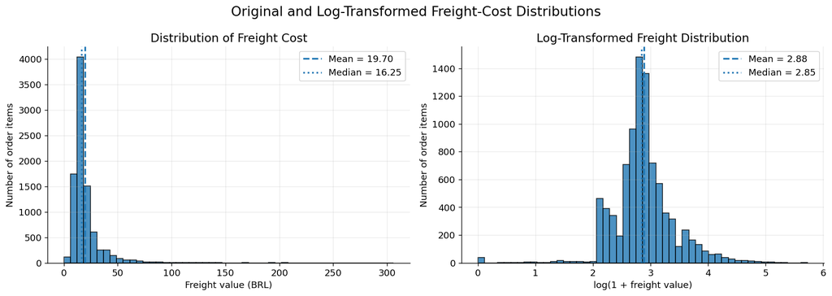

```python
# ============================================================
# FREIGHT-COST DISTRIBUTION
# ============================================================

freight_values = (
    modelling_df["freight_value"]
    .dropna()
)

figure, axes = plt.subplots(
    nrows=1,
    ncols=2,
    figsize=(14, 5)
)

axes[0].hist(
    freight_values,
    bins=50,
    edgecolor="black",
    alpha=0.80
)

axes[0].axvline(
    freight_values.mean(),
    linestyle="--",
    linewidth=2,
    label=f"Mean = {freight_values.mean():.2f}"
)

axes[0].axvline(
    freight_values.median(),
    linestyle=":",
    linewidth=2,
    label=f"Median = {freight_values.median():.2f}"
)

axes[0].set_title(
    "Distribution of Freight Cost"
)

axes[0].set_xlabel(
    "Freight value (BRL)"
)

axes[0].set_ylabel(
    "Number of order items"
)

axes[0].legend()


log_freight_values = np.log1p(
    freight_values
)

axes[1].hist(
    log_freight_values,
    bins=50,
    edgecolor="black",
    alpha=0.80
)

axes[1].axvline(
    log_freight_values.mean(),
    linestyle="--",
    linewidth=2,
    label=(
        f"Mean = "
        f"{log_freight_values.mean():.2f}"
    )
)

axes[1].axvline(
    log_freight_values.median(),
    linestyle=":",
    linewidth=2,
    label=(
        f"Median = "
        f"{log_freight_values.median():.2f}"
    )
)

axes[1].set_title(
    "Log-Transformed Freight Distribution"
)

axes[1].set_xlabel(
    "log(1 + freight value)"
)

axes[1].set_ylabel(
    "Number of order items"
)

axes[1].legend()

figure.suptitle(
    "Original and Log-Transformed Freight-Cost Distributions",
    fontsize=16
)

plt.tight_layout()

save_current_figure(
    "01_freight_distribution.png"
)

plt.show()
```

```python
# ============================================================
# FREIGHT DISTRIBUTION QUANTILES
# ============================================================

freight_quantile_levels = [
    0.00,
    0.01,
    0.05,
    0.25,
    0.50,
    0.75,
    0.90,
    0.95,
    0.99,
    1.00
]

freight_quantile_df = (
    freight_values
    .quantile(
        freight_quantile_levels
    )
    .rename_axis("quantile")
    .reset_index(
        name="freight_value"
    )
)

freight_quantile_df[
    "percentile"
] = (
    freight_quantile_df["quantile"]
    * 100
)

freight_quantile_df = freight_quantile_df[
    [
        "percentile",
        "freight_value"
    ]
]

freight_quantile_df
```

|  | percentile | freight_value |
| --- | --- | --- |
| 0 | 0.000 | 0.000 |
| 1 | 1.000 | 3.600 |
| 2 | 5.000 | 7.780 |
| 3 | 25.000 | 13.008 |
| 4 | 50.000 | 16.250 |
| 5 | 75.000 | 21.023 |
| 6 | 90.000 | 33.227 |
| 7 | 95.000 | 44.020 |
| 8 | 99.000 | 82.583 |
| 9 | 100.000 | 306.060 |

### 7.2 Normality and Tail Behaviour

A Q–Q plot compares the observed freight-cost quantiles with those expected under a normal distribution. Large departures from the reference line, especially in the upper tail, indicate non-normality and potentially influential high-cost observations.

Linear regression does not require the predictor or target variables themselves to be normally distributed (James et al., 2023). However, strong target skewness can contribute to non-normal and heteroscedastic residuals.

```
Figure saved to: /Users/zimmeljavedvirk/Desktop/datasciencemid/figures/02_freight_qq_plots.png
```

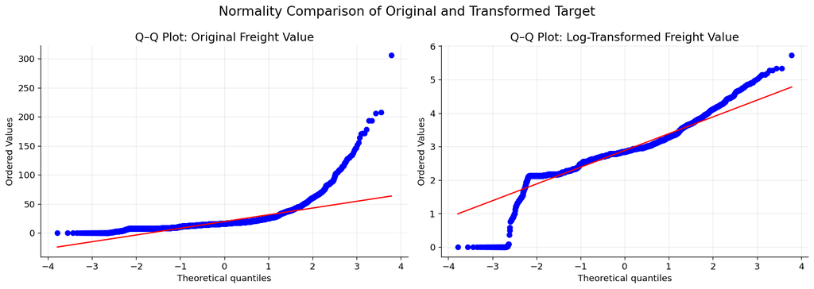

```python
# ============================================================
# FREIGHT Q-Q PLOTS
# ============================================================

figure, axes = plt.subplots(
    nrows=1,
    ncols=2,
    figsize=(14, 5)
)

stats.probplot(
    freight_values,
    dist="norm",
    plot=axes[0]
)

axes[0].set_title(
    "Q–Q Plot: Original Freight Value"
)

stats.probplot(
    log_freight_values,
    dist="norm",
    plot=axes[1]
)

axes[1].set_title(
    "Q–Q Plot: Log-Transformed Freight Value"
)

figure.suptitle(
    "Normality Comparison of Original and Transformed Target",
    fontsize=16
)

plt.tight_layout()

save_current_figure(
    "02_freight_qq_plots.png"
)

plt.show()
```

```
Figure saved to: /Users/zimmeljavedvirk/Desktop/datasciencemid/figures/03_continuous_variable_boxplots.png
```

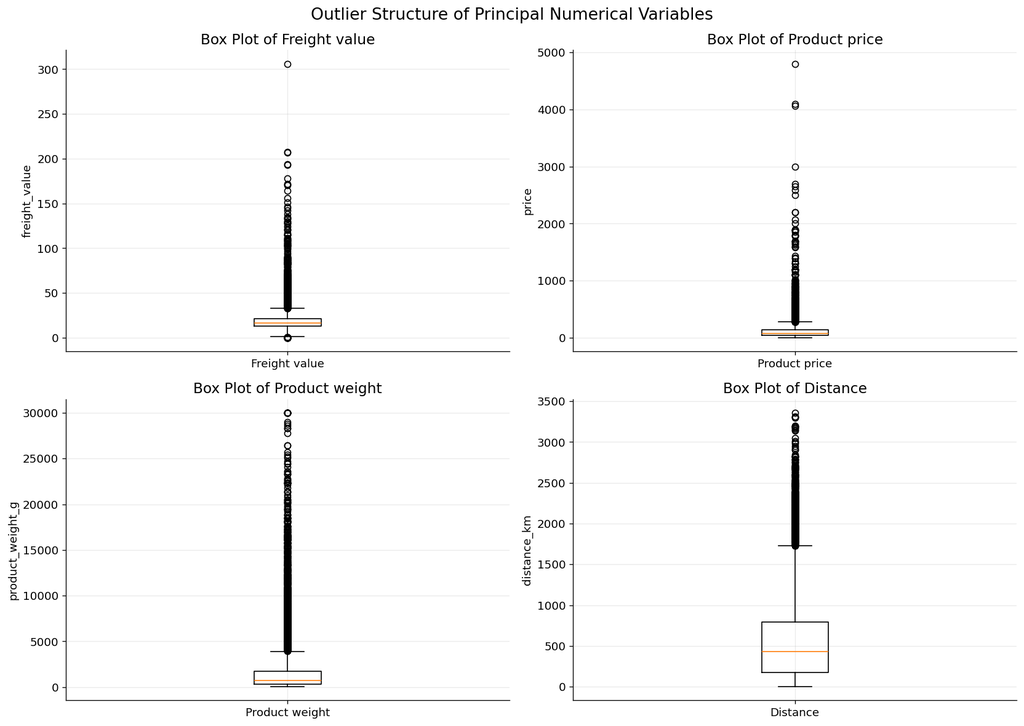

```python
# ============================================================
# CONTINUOUS VARIABLE BOXPLOTS
# ============================================================

boxplot_columns = [
    "freight_value",
    "price",
    "product_weight_g",
    "distance_km"
]

boxplot_labels = [
    "Freight value",
    "Product price",
    "Product weight",
    "Distance"
]

figure, axes = plt.subplots(
    nrows=2,
    ncols=2,
    figsize=(14, 10)
)

for axis, column_name, label in zip(
    axes.flatten(),
    boxplot_columns,
    boxplot_labels
):

    valid_values = (
        modelling_df[column_name]
        .dropna()
    )

    axis.boxplot(
        valid_values,
        vert=True,
        showfliers=True
    )

    axis.set_title(
        f"Box Plot of {label}"
    )

    axis.set_ylabel(column_name)

    axis.set_xticks([1])

    axis.set_xticklabels([label])

figure.suptitle(
    "Outlier Structure of Principal Numerical Variables",
    fontsize=16
)

plt.tight_layout()

save_current_figure(
    "03_continuous_variable_boxplots.png"
)

plt.show()
```

### 7.3 Correlation Analysis

Pearson correlation measures linear relationships, while Spearman correlation measures monotonic relationships using variable ranks. Comparing both coefficients is useful because relationships involving freight cost may be non-linear or affected by skewness and outliers.

Correlation does not establish causality, and highly correlated predictors may create multicollinearity in the regression model.

```python
# ============================================================
# PEARSON AND SPEARMAN CORRELATION MATRICES
# ============================================================

correlation_columns = [
    "freight_value",
    "price",
    "product_weight_g",
    "product_length_cm",
    "product_height_cm",
    "product_width_cm",
    "product_name_length",
    "product_description_length",
    "product_photos_qty",
    "distance_km",
    "order_item_count",
    "order_distinct_product_count",
    "order_distinct_seller_count",
    "order_total_product_value",
    "order_average_product_price",
    "purchase_month",
    "purchase_day_of_week",
    "purchase_hour",
    "purchase_is_weekend",
    "same_state"
]

correlation_data_df = (
    modelling_df[
        correlation_columns
    ]
    .apply(
        pd.to_numeric,
        errors="coerce"
    )
)

pearson_correlation_df = (
    correlation_data_df
    .corr(method="pearson")
)

spearman_correlation_df = (
    correlation_data_df
    .corr(method="spearman")
)

print("Pearson correlation matrix created.")
print("Spearman correlation matrix created.")
```

```
Pearson correlation matrix created.
Spearman correlation matrix created.
```

```
Figure saved to: /Users/zimmeljavedvirk/Desktop/datasciencemid/figures/04_spearman_correlation_heatmap.png
```

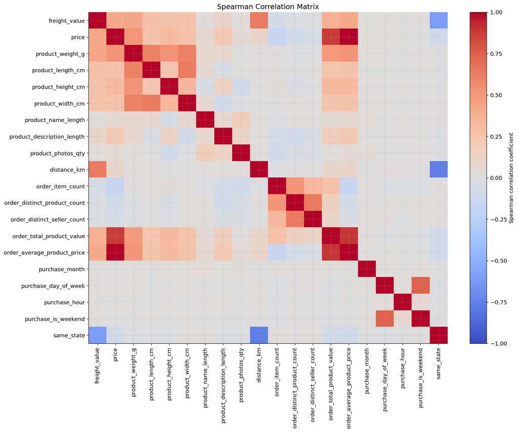

```python
# ============================================================
# SPEARMAN CORRELATION HEATMAP
# ============================================================

figure, axis = plt.subplots(
    figsize=(15, 12)
)

heatmap = axis.imshow(
    spearman_correlation_df,
    aspect="auto",
    vmin=-1,
    vmax=1,
    cmap="coolwarm"
)

axis.set_xticks(
    range(
        len(
            spearman_correlation_df.columns
        )
    )
)

axis.set_yticks(
    range(
        len(
            spearman_correlation_df.index
        )
    )
)

axis.set_xticklabels(
    spearman_correlation_df.columns,
    rotation=90
)

axis.set_yticklabels(
    spearman_correlation_df.index
)

axis.set_title(
    "Spearman Correlation Matrix"
)

colour_bar = figure.colorbar(
    heatmap,
    ax=axis
)

colour_bar.set_label(
    "Spearman correlation coefficient"
)

plt.tight_layout()

save_current_figure(
    "04_spearman_correlation_heatmap.png"
)

plt.show()
```

```python
# ============================================================
# TARGET CORRELATION RANKING
# ============================================================

pearson_target_correlations = (
    pearson_correlation_df[
        "freight_value"
    ]
    .drop(
        labels="freight_value"
    )
)

spearman_target_correlations = (
    spearman_correlation_df[
        "freight_value"
    ]
    .drop(
        labels="freight_value"
    )
)

target_correlation_ranking_df = (
    pd.DataFrame(
        {
            "pearson_correlation":
                pearson_target_correlations,
            "spearman_correlation":
                spearman_target_correlations
        }
    )
)

target_correlation_ranking_df[
    "absolute_spearman_correlation"
] = (
    target_correlation_ranking_df[
        "spearman_correlation"
    ].abs()
)

target_correlation_ranking_df = (
    target_correlation_ranking_df
    .sort_values(
        by="absolute_spearman_correlation",
        ascending=False
    )
    .reset_index()
    .rename(
        columns={
            "index": "predictor"
        }
    )
)

target_correlation_ranking_df
```

|  | predictor | pearson_correlation | spearman_correlation | absolute_spearman_correlation |
| --- | --- | --- | --- | --- |
| 0 | distance_km | 0.411 | 0.638 | 0.638 |
| 1 | same_state | -0.322 | -0.609 | 0.609 |
| 2 | product_weight_g | 0.578 | 0.434 | 0.434 |
| 3 | price | 0.410 | 0.421 | 0.421 |
| 4 | order_average_product_price | 0.414 | 0.420 | 0.420 |
| 5 | order_total_product_value | 0.318 | 0.380 | 0.380 |
| 6 | product_length_cm | 0.301 | 0.280 | 0.280 |
| 7 | product_width_cm | 0.320 | 0.269 | 0.269 |
| 8 | product_height_cm | 0.368 | 0.260 | 0.260 |
| 9 | product_description_length | 0.103 | 0.102 | 0.102 |
| 10 | order_item_count | -0.039 | -0.059 | 0.059 |
| 11 | order_distinct_product_count | -0.031 | -0.030 | 0.030 |
| 12 | order_distinct_seller_count | -0.009 | -0.023 | 0.023 |
| 13 | product_name_length | 0.018 | 0.022 | 0.022 |
| 14 | purchase_day_of_week | 0.015 | 0.015 | 0.015 |
| 15 | product_photos_qty | 0.030 | 0.011 | 0.011 |
| 16 | purchase_is_weekend | 0.015 | 0.011 | 0.011 |
| 17 | purchase_hour | 0.007 | 0.004 | 0.004 |
| 18 | purchase_month | 0.013 | 0.002 | 0.002 |

```
Figure saved to: /Users/zimmeljavedvirk/Desktop/datasciencemid/figures/05_target_correlation_ranking.png
```

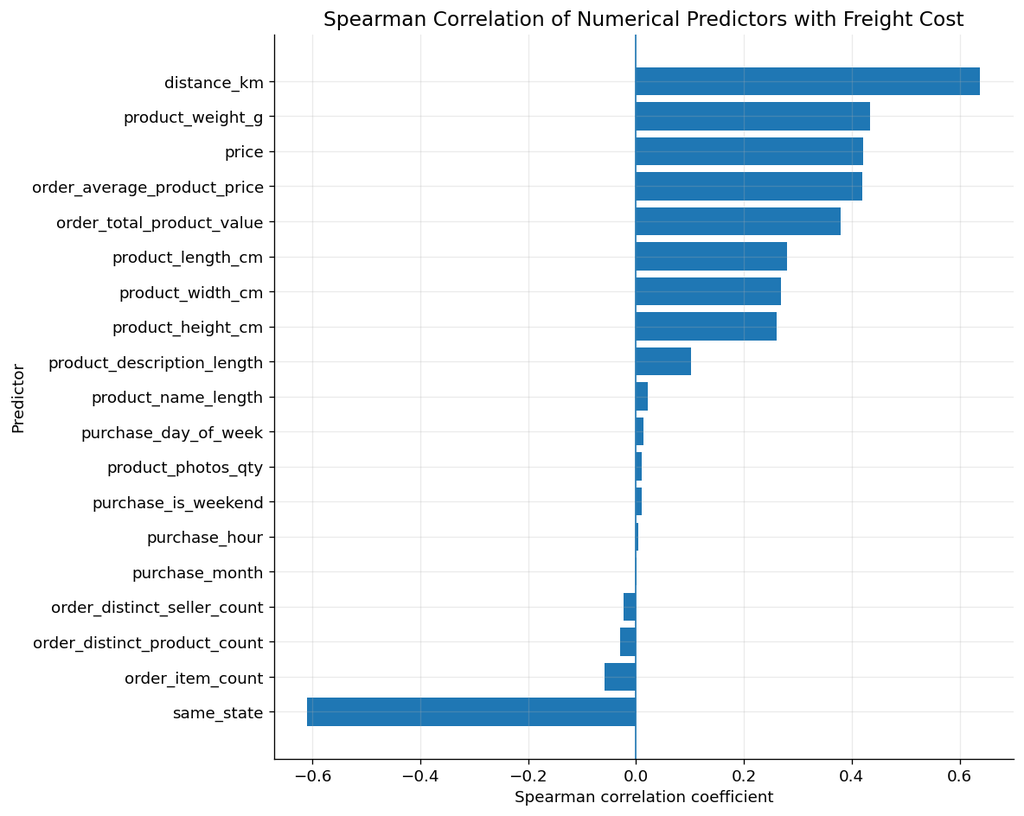

```python
# ============================================================
# RANKED TARGET CORRELATIONS
# ============================================================

correlation_plot_df = (
    target_correlation_ranking_df
    .sort_values(
        "spearman_correlation",
        ascending=True
    )
)

figure, axis = plt.subplots(
    figsize=(10, 8)
)

axis.barh(
    correlation_plot_df["predictor"],
    correlation_plot_df[
        "spearman_correlation"
    ]
)

axis.axvline(
    x=0,
    linewidth=1
)

axis.set_title(
    "Spearman Correlation of Numerical Predictors with Freight Cost"
)

axis.set_xlabel(
    "Spearman correlation coefficient"
)

axis.set_ylabel(
    "Predictor"
)

plt.tight_layout()

save_current_figure(
    "05_target_correlation_ranking.png"
)

plt.show()
```

### 7.4 Freight Cost and Geographical Distance

The relationship between freight cost and seller-to-customer distance is examined using a hexagonal density plot. Each hexagon represents the concentration of observations within a region of the graph.

This visualisation is particularly important because distance is a theoretically meaningful logistics variable that is known before shipment. A positive relationship would support its inclusion in the regression model.

```
Figure saved to: /Users/zimmeljavedvirk/Desktop/datasciencemid/figures/06_distance_freight_hexbin.png
```

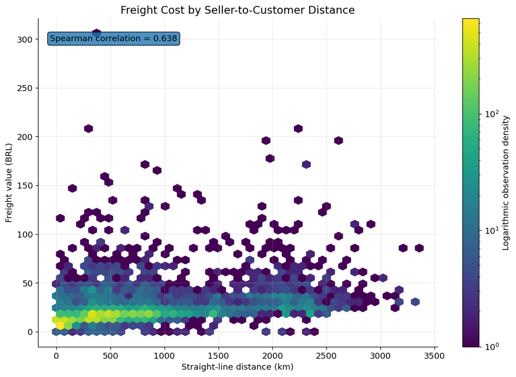

```python
# ============================================================
# DISTANCE AND FREIGHT HEXBIN PLOT
# ============================================================

distance_freight_df = (
    modelling_df[
        [
            "distance_km",
            "freight_value"
        ]
    ]
    .dropna()
)

distance_spearman = (
    distance_freight_df[
        "distance_km"
    ]
    .corr(
        distance_freight_df[
            "freight_value"
        ],
        method="spearman"
    )
)

figure, axis = plt.subplots(
    figsize=(10, 7)
)

hexbin_plot = axis.hexbin(
    distance_freight_df["distance_km"],
    distance_freight_df["freight_value"],
    gridsize=45,
    mincnt=1,
    bins="log",
    cmap="viridis"
)

axis.set_title(
    "Freight Cost by Seller-to-Customer Distance"
)

axis.set_xlabel(
    "Straight-line distance (km)"
)

axis.set_ylabel(
    "Freight value (BRL)"
)

axis.text(
    0.03,
    0.95,
    (
        f"Spearman correlation = "
        f"{distance_spearman:.3f}"
    ),
    transform=axis.transAxes,
    verticalalignment="top",
    bbox={
        "boxstyle": "round",
        "alpha": 0.8
    }
)

colour_bar = figure.colorbar(
    hexbin_plot,
    ax=axis
)

colour_bar.set_label(
    "Logarithmic observation density"
)

plt.tight_layout()

save_current_figure(
    "06_distance_freight_hexbin.png"
)

plt.show()
```

```
Figure saved to: /Users/zimmeljavedvirk/Desktop/datasciencemid/figures/07_weight_freight_hexbin.png
```

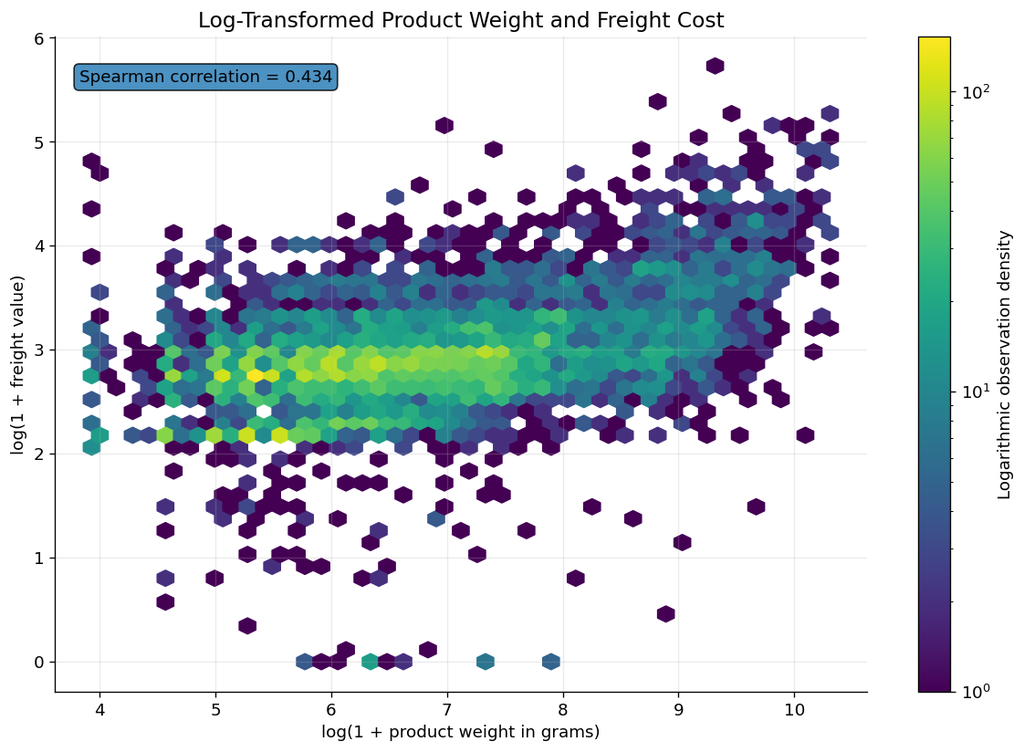

```python
# ============================================================
# PRODUCT WEIGHT AND FREIGHT HEXBIN PLOT
# ============================================================

weight_freight_df = (
    modelling_df[
        [
            "product_weight_g",
            "freight_value"
        ]
    ]
    .dropna()
    .copy()
)

weight_freight_df[
    "log_product_weight"
] = np.log1p(
    weight_freight_df[
        "product_weight_g"
    ]
)

weight_freight_df[
    "log_freight_value"
] = np.log1p(
    weight_freight_df[
        "freight_value"
    ]
)

weight_spearman = (
    weight_freight_df[
        "product_weight_g"
    ]
    .corr(
        weight_freight_df[
            "freight_value"
        ],
        method="spearman"
    )
)

figure, axis = plt.subplots(
    figsize=(10, 7)
)

hexbin_plot = axis.hexbin(
    weight_freight_df[
        "log_product_weight"
    ],
    weight_freight_df[
        "log_freight_value"
    ],
    gridsize=45,
    mincnt=1,
    bins="log",
    cmap="viridis"
)

axis.set_title(
    "Log-Transformed Product Weight and Freight Cost"
)

axis.set_xlabel(
    "log(1 + product weight in grams)"
)

axis.set_ylabel(
    "log(1 + freight value)"
)

axis.text(
    0.03,
    0.95,
    (
        f"Spearman correlation = "
        f"{weight_spearman:.3f}"
    ),
    transform=axis.transAxes,
    verticalalignment="top",
    bbox={
        "boxstyle": "round",
        "alpha": 0.8
    }
)

colour_bar = figure.colorbar(
    hexbin_plot,
    ax=axis
)

colour_bar.set_label(
    "Logarithmic observation density"
)

plt.tight_layout()

save_current_figure(
    "07_weight_freight_hexbin.png"
)

plt.show()
```

### 7.5 Freight Cost by Product Category

Product-category comparisons are restricted to categories containing at least 30 sampled observations. This prevents categories represented by only a few products from producing unstable or misleading averages.

The median is used as the principal comparison because freight values are positively skewed.

```python
# ============================================================
# CATEGORY-LEVEL FREIGHT SUMMARY
# ============================================================

MINIMUM_CATEGORY_OBSERVATIONS = 30

category_freight_summary_df = (
    modelling_df
    .groupby(
        "product_category_name_english",
        dropna=False
    )
    .agg(
        observation_count=(
            "freight_value",
            "size"
        ),
        mean_freight=(
            "freight_value",
            "mean"
        ),
        median_freight=(
            "freight_value",
            "median"
        ),
        standard_deviation=(
            "freight_value",
            "std"
        ),
        first_quartile=(
            "freight_value",
            lambda values:
                values.quantile(0.25)
        ),
        third_quartile=(
            "freight_value",
            lambda values:
                values.quantile(0.75)
        )
    )
    .reset_index()
)

category_freight_summary_df[
    "interquartile_range"
] = (
    category_freight_summary_df[
        "third_quartile"
    ]
    - category_freight_summary_df[
        "first_quartile"
    ]
)

reliable_category_freight_df = (
    category_freight_summary_df[
        category_freight_summary_df[
            "observation_count"
        ]
        >= MINIMUM_CATEGORY_OBSERVATIONS
    ]
    .sort_values(
        "median_freight",
        ascending=False
    )
    .reset_index(drop=True)
)

reliable_category_freight_df.head(15)
```

|  | product_category_name_english | observation_count | mean_freight | median_freight | standard_deviation | first_quartile | third_quartile | interquartile_range |
| --- | --- | --- | --- | --- | --- | --- | --- | --- |
| 0 | office_furniture | 138 | 38.935 | 34.190 | 21.181 | 23.325 | 45.588 | 22.263 |
| 1 | furniture_living_room | 42 | 37.115 | 26.225 | 33.668 | 18.027 | 43.780 | 25.753 |
| 2 | small_appliances | 44 | 32.012 | 19.935 | 28.782 | 16.027 | 41.578 | 25.550 |
| 3 | home_appliances | 63 | 24.079 | 18.230 | 29.413 | 14.870 | 20.395 | 5.525 |
| 4 | luggage_accessories | 93 | 25.565 | 18.070 | 17.599 | 14.420 | 34.790 | 20.370 |
| 5 | home_construction | 44 | 23.596 | 17.925 | 18.617 | 12.633 | 24.430 | 11.797 |
| 6 | garden_tools | 343 | 23.915 | 17.670 | 16.215 | 15.000 | 28.695 | 13.695 |
| 7 | home_confort | 30 | 19.263 | 17.545 | 8.292 | 13.650 | 23.547 | 9.897 |
| 8 | cool_stuff | 279 | 20.986 | 17.260 | 15.015 | 13.965 | 22.515 | 8.550 |
| 9 | musical_instruments | 53 | 25.897 | 17.040 | 26.372 | 13.340 | 26.890 | 13.550 |
| 10 | auto | 360 | 21.316 | 16.960 | 17.325 | 13.378 | 23.105 | 9.727 |
| 11 | construction_tools_construction | 78 | 23.465 | 16.865 | 22.548 | 11.900 | 24.580 | 12.680 |
| 12 | baby | 271 | 23.632 | 16.700 | 26.869 | 13.195 | 23.230 | 10.035 |
| 13 | pet_shop | 133 | 21.626 | 16.670 | 18.622 | 13.120 | 23.250 | 10.130 |
| 14 | housewares | 588 | 19.804 | 16.650 | 13.282 | 12.797 | 22.067 | 9.270 |

```
Figure saved to: /Users/zimmeljavedvirk/Desktop/datasciencemid/figures/08_category_median_freight.png
```

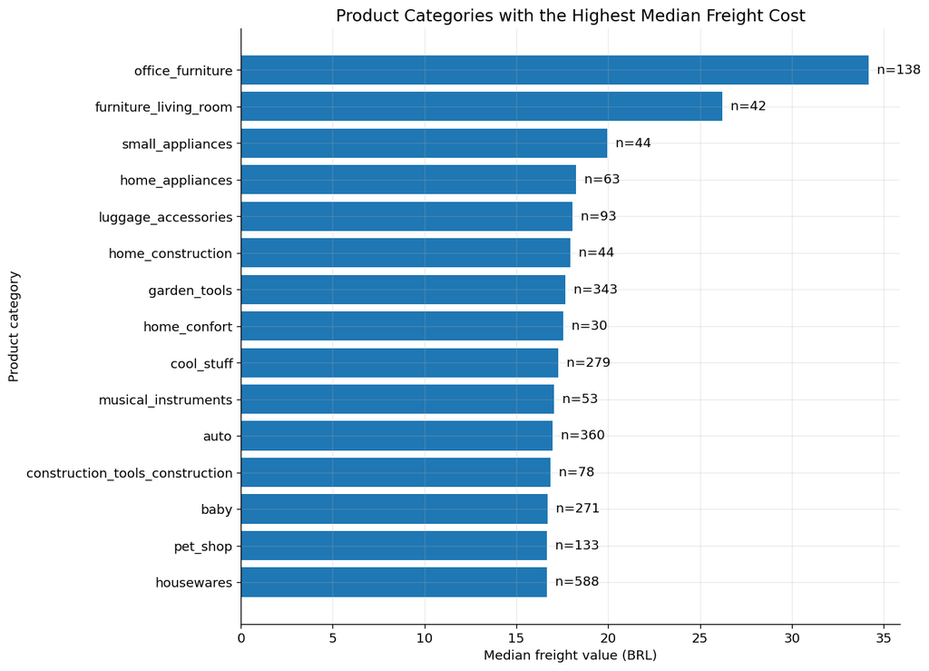

```python
# ============================================================
# MEDIAN FREIGHT BY PRODUCT CATEGORY
# ============================================================

top_category_plot_df = (
    reliable_category_freight_df
    .head(15)
    .sort_values(
        "median_freight",
        ascending=True
    )
)

figure, axis = plt.subplots(
    figsize=(11, 8)
)

axis.barh(
    top_category_plot_df[
        "product_category_name_english"
    ],
    top_category_plot_df[
        "median_freight"
    ]
)

axis.set_title(
    "Product Categories with the Highest Median Freight Cost"
)

axis.set_xlabel(
    "Median freight value (BRL)"
)

axis.set_ylabel(
    "Product category"
)

for index, row in top_category_plot_df.reset_index(
    drop=True
).iterrows():

    axis.text(
        row["median_freight"],
        index,
        (
            f"  n={int(row['observation_count'])}"
        ),
        va="center"
    )

plt.tight_layout()

save_current_figure(
    "08_category_median_freight.png"
)

plt.show()
```

```
Figure saved to: /Users/zimmeljavedvirk/Desktop/datasciencemid/figures/09_same_state_freight_boxplot.png
```

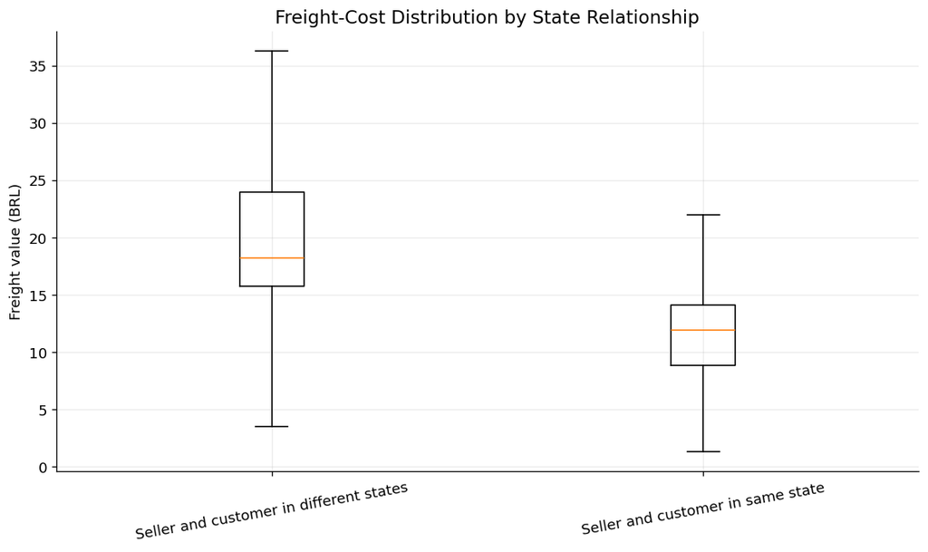

```python
# ============================================================
# SAME-STATE VERSUS INTERSTATE FREIGHT
# ============================================================

same_state_plot_df = (
    modelling_df[
        [
            "same_state",
            "freight_value"
        ]
    ]
    .dropna()
    .copy()
)

same_state_plot_df[
    "route_type"
] = same_state_plot_df[
    "same_state"
].map(
    {
        1: "Seller and customer in same state",
        0: "Seller and customer in different states"
    }
)

route_groups = [
    group["freight_value"].values
    for _, group in same_state_plot_df.groupby(
        "route_type"
    )
]

route_labels = [
    label
    for label, _ in same_state_plot_df.groupby(
        "route_type"
    )
]

figure, axis = plt.subplots(
    figsize=(10, 6)
)

axis.boxplot(
    route_groups,
    labels=route_labels,
    showfliers=False
)

axis.set_title(
    "Freight-Cost Distribution by State Relationship"
)

axis.set_ylabel(
    "Freight value (BRL)"
)

axis.tick_params(
    axis="x",
    rotation=10
)

plt.tight_layout()

save_current_figure(
    "09_same_state_freight_boxplot.png"
)

plt.show()
```

```python
route_type_summary_df = (
    same_state_plot_df
    .groupby("route_type")
    .agg(
        observation_count=(
            "freight_value",
            "size"
        ),
        mean_freight=(
            "freight_value",
            "mean"
        ),
        median_freight=(
            "freight_value",
            "median"
        ),
        standard_deviation=(
            "freight_value",
            "std"
        )
    )
    .reset_index()
)

route_type_summary_df
```

|  | route_type | observation_count | mean_freight | median_freight | standard_deviation |
| --- | --- | --- | --- | --- | --- |
| 0 | Seller and customer in different states | 5693 | 23.329 | 18.230 | 16.327 |
| 1 | Seller and customer in same state | 3307 | 13.452 | 11.920 | 8.633 |

### 7.6 Temporal Freight Patterns

Purchase month and day-of-week patterns are examined to determine whether freight cost changes systematically over time. Median freight is used to reduce the influence of unusually expensive shipments.

```
Figure saved to: /Users/zimmeljavedvirk/Desktop/datasciencemid/figures/10_monthly_median_freight.png
```

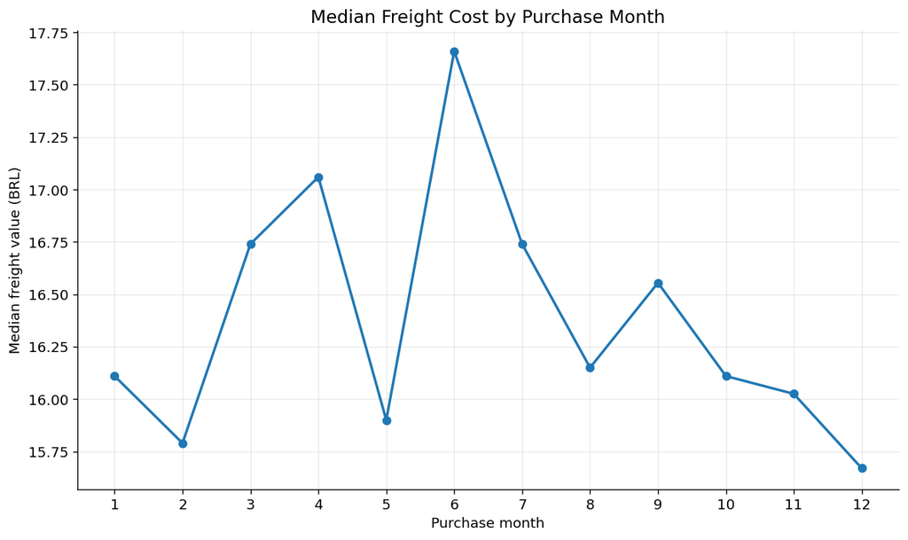

|  | purchase_month | observation_count | mean_freight | median_freight |
| --- | --- | --- | --- | --- |
| 0 | 1 | 709 | 18.916 | 16.110 |
| 1 | 2 | 783 | 19.082 | 15.790 |
| 2 | 3 | 923 | 19.200 | 16.740 |
| 3 | 4 | 821 | 20.385 | 17.060 |
| 4 | 5 | 996 | 18.923 | 15.900 |
| 5 | 6 | 833 | 20.981 | 17.660 |
| 6 | 7 | 941 | 20.436 | 16.740 |
| 7 | 8 | 962 | 19.554 | 16.150 |
| 8 | 9 | 394 | 20.378 | 16.555 |
| 9 | 10 | 423 | 20.638 | 16.110 |
| 10 | 11 | 692 | 19.013 | 16.025 |
| 11 | 12 | 523 | 19.522 | 15.670 |

```python
# ============================================================
# MONTHLY FREIGHT PATTERN
# ============================================================

monthly_freight_df = (
    modelling_df
    .groupby(
        "purchase_month",
        as_index=False
    )
    .agg(
        observation_count=(
            "freight_value",
            "size"
        ),
        mean_freight=(
            "freight_value",
            "mean"
        ),
        median_freight=(
            "freight_value",
            "median"
        )
    )
    .sort_values(
        "purchase_month"
    )
)

figure, axis = plt.subplots(
    figsize=(10, 6)
)

axis.plot(
    monthly_freight_df[
        "purchase_month"
    ],
    monthly_freight_df[
        "median_freight"
    ],
    marker="o",
    linewidth=2
)

axis.set_title(
    "Median Freight Cost by Purchase Month"
)

axis.set_xlabel(
    "Purchase month"
)

axis.set_ylabel(
    "Median freight value (BRL)"
)

axis.set_xticks(
    range(1, 13)
)

plt.tight_layout()

save_current_figure(
    "10_monthly_median_freight.png"
)

plt.show()

monthly_freight_df
```

```
Figure saved to: /Users/zimmeljavedvirk/Desktop/datasciencemid/figures/11_weekday_median_freight.png
```

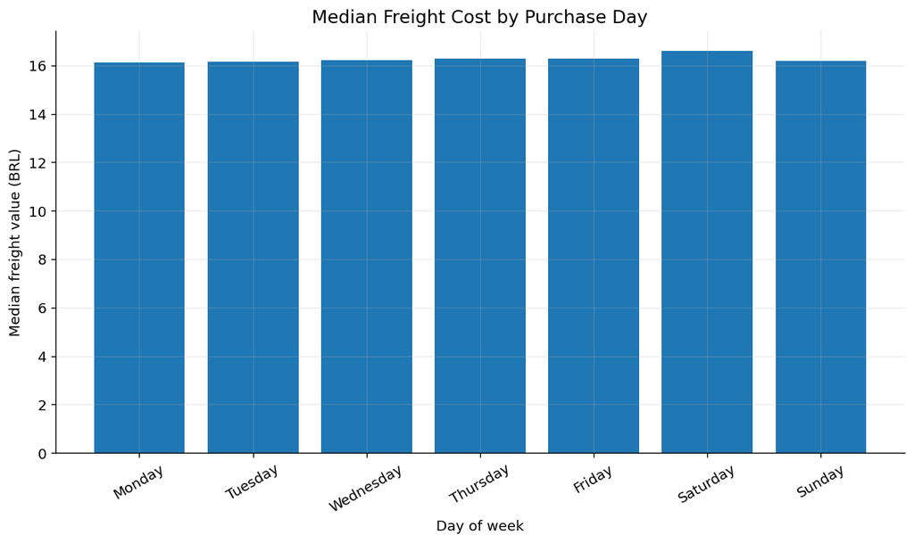

|  | purchase_day_of_week | observation_count | mean_freight | median_freight | weekday |
| --- | --- | --- | --- | --- | --- |
| 0 | 0 | 1429 | 19.645 | 16.110 | Monday |
| 1 | 1 | 1433 | 19.419 | 16.150 | Tuesday |
| 2 | 2 | 1457 | 19.349 | 16.220 | Wednesday |
| 3 | 3 | 1372 | 19.745 | 16.285 | Thursday |
| 4 | 4 | 1256 | 19.761 | 16.275 | Friday |
| 5 | 5 | 979 | 19.912 | 16.610 | Saturday |
| 6 | 6 | 1074 | 20.302 | 16.170 | Sunday |

```python
# ============================================================
# WEEKDAY FREIGHT PATTERN
# ============================================================

weekday_names = {
    0: "Monday",
    1: "Tuesday",
    2: "Wednesday",
    3: "Thursday",
    4: "Friday",
    5: "Saturday",
    6: "Sunday"
}

weekday_freight_df = (
    modelling_df
    .groupby(
        "purchase_day_of_week",
        as_index=False
    )
    .agg(
        observation_count=(
            "freight_value",
            "size"
        ),
        mean_freight=(
            "freight_value",
            "mean"
        ),
        median_freight=(
            "freight_value",
            "median"
        )
    )
    .sort_values(
        "purchase_day_of_week"
    )
)

weekday_freight_df[
    "weekday"
] = weekday_freight_df[
    "purchase_day_of_week"
].map(weekday_names)

figure, axis = plt.subplots(
    figsize=(10, 6)
)

axis.bar(
    weekday_freight_df[
        "weekday"
    ],
    weekday_freight_df[
        "median_freight"
    ]
)

axis.set_title(
    "Median Freight Cost by Purchase Day"
)

axis.set_xlabel(
    "Day of week"
)

axis.set_ylabel(
    "Median freight value (BRL)"
)

axis.tick_params(
    axis="x",
    rotation=30
)

plt.tight_layout()

save_current_figure(
    "11_weekday_median_freight.png"
)

plt.show()

weekday_freight_df
```

```python
# ============================================================
# MOST IMPORTANT NUMERICAL RELATIONSHIP
# ============================================================

strongest_numerical_predictor = (
    target_correlation_ranking_df
    .iloc[0]
)

most_important_visual_audit_df = pd.DataFrame(
    {
        "measurement": [
            "Strongest numerical predictor",
            "Pearson correlation",
            "Spearman correlation",
            "Absolute Spearman correlation"
        ],
        "value": [
            strongest_numerical_predictor[
                "predictor"
            ],
            strongest_numerical_predictor[
                "pearson_correlation"
            ],
            strongest_numerical_predictor[
                "spearman_correlation"
            ],
            strongest_numerical_predictor[
                "absolute_spearman_correlation"
            ]
        ]
    }
)

most_important_visual_audit_df
```

|  | measurement | value |
| --- | --- | --- |
| 0 | Strongest numerical predictor | distance_km |
| 1 | Pearson correlation | 0.411 |
| 2 | Spearman correlation | 0.638 |
| 3 | Absolute Spearman correlation | 0.638 |

```python
# ============================================================
# SAVE VISUAL-ANALYSIS TABLES
# ============================================================

freight_quantile_df.to_csv(
    PROCESSED_DATA_DIRECTORY
    / "freight_quantiles.csv",
    index=False
)

pearson_correlation_df.to_csv(
    PROCESSED_DATA_DIRECTORY
    / "pearson_correlation_matrix.csv"
)

spearman_correlation_df.to_csv(
    PROCESSED_DATA_DIRECTORY
    / "spearman_correlation_matrix.csv"
)

target_correlation_ranking_df.to_csv(
    PROCESSED_DATA_DIRECTORY
    / "target_correlation_ranking.csv",
    index=False
)

category_freight_summary_df.to_csv(
    PROCESSED_DATA_DIRECTORY
    / "category_freight_summary.csv",
    index=False
)

route_type_summary_df.to_csv(
    PROCESSED_DATA_DIRECTORY
    / "route_type_freight_summary.csv",
    index=False
)

monthly_freight_df.to_csv(
    PROCESSED_DATA_DIRECTORY
    / "monthly_freight_summary.csv",
    index=False
)

weekday_freight_df.to_csv(
    PROCESSED_DATA_DIRECTORY
    / "weekday_freight_summary.csv",
    index=False
)

most_important_visual_audit_df.to_csv(
    PROCESSED_DATA_DIRECTORY
    / "most_important_visual_audit.csv",
    index=False
)

print(
    "Visual-analysis tables saved successfully."
)
```

```
Visual-analysis tables saved successfully.
```

### Visualisation Interpretation

The freight-cost histogram and Q–Q plot should be interpreted together. A substantial difference between the mean and median, combined with upper-tail deviation in the Q–Q plot, indicates positive skewness and the presence of relatively uncommon high-cost shipments. The logarithmic comparison provides evidence for evaluating a transformed model later in the project.

The correlation matrix compares Pearson and Spearman coefficients. When the Spearman coefficient is noticeably larger than the Pearson coefficient, the relationship may be monotonic but not strictly linear, or it may be affected by extreme values. Correlation strength alone will not determine feature inclusion because categorical variables and theoretically important logistics factors may remain useful in a multivariable model (Schober, Boer and Schwarte, 2018).

The distance and weight density plots are more informative than ordinary scatterplots because overlapping observations are represented through density. They help determine whether freight cost generally increases with transport distance and physical parcel size.

Category comparisons demonstrate that freight costs vary between types of products. However, these differences may partly reflect weight, dimensions, seller location and customer destination. Product category will therefore be included alongside numerical logistics variables rather than interpreted as an isolated causal factor.

The same-state comparison investigates whether interstate shipments generally cost more than shipments within the same state. This variable may capture administrative or network effects not represented completely by straight-line distance.

The distance–freight hexagonal-density plot was selected as the most important visualisation. Distance had the strongest positive monotonic relationship with freight value, producing a Spearman correlation of 0.638. The graph showed that freight cost generally increased with seller-to-customer distance, while the widening spread demonstrated that distance alone cannot explain every freight charge. Product weight, dimensions, category, regional location and order characteristics also influence the outcome. This visualisation is particularly important because it connects a theoretically relevant logistics factor with the prediction target and directly supports the inclusion of distance in the multiple linear regression models.

## 8. Baseline Multiple Linear Regression Model

A baseline multiple linear regression model is developed to predict item-level freight cost. The model combines product characteristics, geographical information, order context, purchase timing and categorical marketplace attributes.

The target variable is `freight_value`, measured in Brazilian reais for each order item. Identifiers, payment values, reviews, delivery outcomes and other post-purchase information are excluded because they either lack predictive meaning or could introduce target leakage.

Items belonging to the same order share customer, purchase-time and order-level information. A group-aware split based on `order_id` is therefore used instead of an ordinary random row split. This ensures that all items from one order remain entirely within either the training set or the test set.

```python
# ============================================================
# ADDITIONAL MODELLING IMPORTS
# ============================================================

from sklearn.model_selection import (
    GroupShuffleSplit,
    GroupKFold,
    cross_validate
)

from sklearn.dummy import DummyRegressor

from sklearn.metrics import (
    mean_squared_error,
    mean_absolute_error,
    median_absolute_error,
    r2_score,
    make_scorer
)

print("Advanced modelling tools imported successfully.")
```

```
Advanced modelling tools imported successfully.
```

```python
# ============================================================
# PREPARE FEATURES, TARGET AND GROUP IDENTIFIERS
# ============================================================

X = modelling_df[
    all_candidate_features
].copy()

y = pd.to_numeric(
    modelling_df[target_column],
    errors="coerce"
).astype(float)

groups = modelling_df[
    group_column
].copy()


# Explicitly standardise numerical data types
for column_name in baseline_numerical_features:
    X[column_name] = pd.to_numeric(
        X[column_name],
        errors="coerce"
    ).astype(float)


# Convert categorical variables to ordinary object columns
# and represent missing values using np.nan
for column_name in baseline_categorical_features:
    X[column_name] = (
        X[column_name]
        .astype("object")
        .where(
            X[column_name].notna(),
            np.nan
        )
    )


# Final target checks
assert y.notna().all()
assert np.isfinite(y).all()
assert len(X) == len(y) == len(groups)

print(f"Feature matrix shape: {X.shape}")
print(f"Target observations: {len(y):,}")
print(f"Unique order groups: {groups.nunique():,}")
```

```
Feature matrix shape: (9000, 24)
Target observations: 9,000
Unique order groups: 8,874
```

```python
# ============================================================
# GROUP-AWARE TRAIN-TEST SPLIT
# ============================================================

group_splitter = GroupShuffleSplit(
    n_splits=1,
    test_size=TEST_SIZE,
    random_state=RANDOM_STATE
)

train_indices, test_indices = next(
    group_splitter.split(
        X=X,
        y=y,
        groups=groups
    )
)

X_train = X.iloc[train_indices].copy()
X_test = X.iloc[test_indices].copy()

y_train = y.iloc[train_indices].copy()
y_test = y.iloc[test_indices].copy()

groups_train = groups.iloc[train_indices].copy()
groups_test = groups.iloc[test_indices].copy()


# Confirm that no order appears in both partitions
overlapping_orders = set(
    groups_train.unique()
).intersection(
    set(groups_test.unique())
)

assert len(overlapping_orders) == 0

print(f"Training rows: {len(X_train):,}")
print(f"Testing rows: {len(X_test):,}")
print(
    f"Training orders: "
    f"{groups_train.nunique():,}"
)
print(
    f"Testing orders: "
    f"{groups_test.nunique():,}"
)
print(
    f"Orders appearing in both sets: "
    f"{len(overlapping_orders)}"
)
```

```
Training rows: 7,199
Testing rows: 1,801
Training orders: 7,099
Testing orders: 1,775
Orders appearing in both sets: 0
```

```python
# ============================================================
# TRAIN-TEST SPLIT AUDIT
# ============================================================

split_audit_df = pd.DataFrame(
    {
        "measurement": [
            "Rows",
            "Unique orders",
            "Mean freight value",
            "Median freight value",
            "Freight standard deviation",
            "Minimum freight value",
            "Maximum freight value"
        ],
        "training_set": [
            len(X_train),
            groups_train.nunique(),
            y_train.mean(),
            y_train.median(),
            y_train.std(),
            y_train.min(),
            y_train.max()
        ],
        "testing_set": [
            len(X_test),
            groups_test.nunique(),
            y_test.mean(),
            y_test.median(),
            y_test.std(),
            y_test.min(),
            y_test.max()
        ]
    }
)

split_audit_df[
    "absolute_difference"
] = (
    split_audit_df["training_set"]
    - split_audit_df["testing_set"]
).abs()

split_audit_df
```

|  | measurement | training_set | testing_set | absolute_difference |
| --- | --- | --- | --- | --- |
| 0 | Rows | 7,199.000 | 1,801.000 | 5,398.000 |
| 1 | Unique orders | 7,099.000 | 1,775.000 | 5,324.000 |
| 2 | Mean freight value | 19.601 | 20.096 | 0.495 |
| 3 | Median freight value | 16.220 | 16.460 | 0.240 |
| 4 | Freight standard deviation | 14.068 | 17.367 | 3.299 |
| 5 | Minimum freight value | 0.000 | 0.000 | 0.000 |
| 6 | Maximum freight value | 206.500 | 306.060 | 99.560 |

The training and test sets are compared to confirm that the group-aware split has not produced a severely unrepresentative test partition. Small differences are expected because complete orders, rather than independent rows, were allocated to each partition.

### 8.1 Leakage-Safe Preprocessing Pipeline

All model-specific preprocessing is fitted using the training data only.

Numerical variables are imputed using their training-set median and then standardised. Median imputation is appropriate because several predictors contain long right tails and extreme values.

Categorical variables receive an explicit missing label and are one-hot encoded. Infrequent categories are grouped where supported by the installed Scikit-learn version. The first category is dropped to reduce exact dummy-variable multicollinearity, while unseen test-set categories are handled without causing prediction errors.

```python
# ============================================================
# CREATE A VERSION-COMPATIBLE ONE-HOT ENCODER
# ============================================================

def create_one_hot_encoder(
    minimum_frequency=20
):
    """
    Create a one-hot encoder compatible with recent and older
    Scikit-learn versions.
    """

    try:
        return OneHotEncoder(
            handle_unknown="ignore",
            min_frequency=minimum_frequency,
            drop="first",
            sparse_output=True
        )

    except TypeError:
        try:
            return OneHotEncoder(
                handle_unknown="ignore",
                min_frequency=minimum_frequency,
                drop="first",
                sparse=True
            )

        except TypeError:
            return OneHotEncoder(
                handle_unknown="ignore",
                drop="first",
                sparse=True
            )


numerical_pipeline = Pipeline(
    steps=[
        (
            "median_imputer",
            SimpleImputer(
                strategy="median",
                add_indicator=True
            )
        ),
        (
            "standard_scaler",
            StandardScaler()
        )
    ]
)


categorical_pipeline = Pipeline(
    steps=[
        (
            "missing_category_imputer",
            SimpleImputer(
                strategy="constant",
                fill_value="missing"
            )
        ),
        (
            "one_hot_encoder",
            create_one_hot_encoder(
                minimum_frequency=20
            )
        )
    ]
)


baseline_preprocessor = ColumnTransformer(
    transformers=[
        (
            "numerical",
            numerical_pipeline,
            baseline_numerical_features
        ),
        (
            "categorical",
            categorical_pipeline,
            baseline_categorical_features
        )
    ],
    remainder="drop",
    verbose_feature_names_out=True
)


baseline_regression_pipeline = Pipeline(
    steps=[
        (
            "preprocessor",
            baseline_preprocessor
        ),
        (
            "linear_regression",
            LinearRegression()
        )
    ]
)

baseline_regression_pipeline
```

```
Pipeline(steps=[('preprocessor',
                 ColumnTransformer(transformers=[('numerical',
                                                  Pipeline(steps=[('median_imputer',
                                                                   SimpleImputer(add_indicator=True,
                                                                                 strategy='median')),
                                                                  ('standard_scaler',
                                                                   StandardScaler())]),
                                                  ['price', 'product_weight_g',
                                                   'product_length_cm',
                                                   'product_height_cm',
                                                   'product_width_cm',
                                                   'product_name_length',
                                                   'product_description_length',
                                                   'product_...
                                                  Pipeline(steps=[('missing_category_imputer',
                                                                   SimpleImputer(fill_value='missing',
                                                                                 strategy='constant')),
                                                                  ('one_hot_encoder',
                                                                   OneHotEncoder(drop='first',
                                                                                 handle_unknown='ignore',
                                                                                 min_frequency=20))]),
                                                  ['product_category_name_english',
                                                   'customer_state',
                                                   'seller_state',
                                                   'customer_coordinate_source',
                                                   'seller_coordinate_source'])])),
                ('linear_regression', LinearRegression())])
```

```python
# ============================================================
# REUSABLE REGRESSION EVALUATION FUNCTIONS
# ============================================================

def calculate_rmse(
    actual_values,
    predicted_values
):
    """
    Calculate root mean squared error.
    """

    return np.sqrt(
        mean_squared_error(
            actual_values,
            predicted_values
        )
    )


def calculate_regression_metrics(
    actual_values,
    predicted_values,
    model_name
):
    """
    Calculate principal regression performance measures.
    """

    rmse_value = calculate_rmse(
        actual_values,
        predicted_values
    )

    mae_value = mean_absolute_error(
        actual_values,
        predicted_values
    )

    median_ae_value = median_absolute_error(
        actual_values,
        predicted_values
    )

    r_squared_value = r2_score(
        actual_values,
        predicted_values
    )

    target_mean = np.mean(actual_values)

    return {
        "model": model_name,
        "RMSE": rmse_value,
        "MAE": mae_value,
        "median_absolute_error":
            median_ae_value,
        "R_squared": r_squared_value,
        "RMSE_as_percentage_of_target_mean": (
            rmse_value
            / target_mean
            * 100
            if target_mean != 0
            else np.nan
        ),
        "predicted_negative_values": int(
            np.sum(
                predicted_values < 0
            )
        )
    }
```

### 8.2 Naïve Benchmark

A mean-prediction model is used as a minimum benchmark. It predicts the training-set mean freight value for every test observation.

The benchmark has no explanatory features. A useful multiple linear regression model should therefore achieve lower RMSE and MAE and a higher R² than this baseline.

```python
# ============================================================
# FIT THE MEAN-PREDICTION BENCHMARK
# ============================================================

dummy_model = DummyRegressor(
    strategy="mean"
)

dummy_training_matrix = np.zeros(
    shape=(len(y_train), 1)
)

dummy_testing_matrix = np.zeros(
    shape=(len(y_test), 1)
)

dummy_model.fit(
    dummy_training_matrix,
    y_train
)

dummy_predictions = dummy_model.predict(
    dummy_testing_matrix
)

dummy_metrics = calculate_regression_metrics(
    actual_values=y_test,
    predicted_values=dummy_predictions,
    model_name="Mean prediction benchmark"
)

pd.DataFrame([dummy_metrics])
```

|  | model | RMSE | MAE | median_absolute_error | R_squared | RMSE_as_percentage_of_target_mean | predicted_negative_values |
| --- | --- | --- | --- | --- | --- | --- | --- |
| 0 | Mean prediction benchmark | 17.369 | 8.573 | 5.331 | -0.001 | 86.431 | 0 |

```python
# ============================================================
# FIT THE BASELINE MULTIPLE LINEAR REGRESSION MODEL
# ============================================================

baseline_regression_pipeline.fit(
    X_train,
    y_train
)

baseline_predictions = (
    baseline_regression_pipeline.predict(
        X_test
    )
)

baseline_metrics = calculate_regression_metrics(
    actual_values=y_test,
    predicted_values=baseline_predictions,
    model_name="Baseline multiple linear regression"
)

test_model_comparison_df = pd.DataFrame(
    [
        dummy_metrics,
        baseline_metrics
    ]
)

test_model_comparison_df
```

|  | model | RMSE | MAE | median_absolute_error | R_squared | RMSE_as_percentage_of_target_mean | predicted_negative_values |
| --- | --- | --- | --- | --- | --- | --- | --- |
| 0 | Mean prediction benchmark | 17.369 | 8.573 | 5.331 | -0.001 | 86.431 | 0 |
| 1 | Baseline multiple linear regression | 11.492 | 5.166 | 2.719 | 0.562 | 57.185 | 0 |

```python
# ============================================================
# BASELINE IMPROVEMENT OVER NAÏVE BENCHMARK
# ============================================================

benchmark_rmse = dummy_metrics["RMSE"]
baseline_rmse = baseline_metrics["RMSE"]

benchmark_mae = dummy_metrics["MAE"]
baseline_mae = baseline_metrics["MAE"]

baseline_improvement_df = pd.DataFrame(
    {
        "measurement": [
            "RMSE reduction",
            "RMSE percentage improvement",
            "MAE reduction",
            "MAE percentage improvement",
            "Baseline test R²"
        ],
        "value": [
            benchmark_rmse - baseline_rmse,
            (
                benchmark_rmse
                - baseline_rmse
            )
            / benchmark_rmse
            * 100,
            benchmark_mae - baseline_mae,
            (
                benchmark_mae
                - baseline_mae
            )
            / benchmark_mae
            * 100,
            baseline_metrics["R_squared"]
        ]
    }
)

baseline_improvement_df
```

|  | measurement | value |
| --- | --- | --- |
| 0 | RMSE reduction | 5.877 |
| 1 | RMSE percentage improvement | 33.838 |
| 2 | MAE reduction | 3.406 |
| 3 | MAE percentage improvement | 39.737 |
| 4 | Baseline test R² | 0.562 |

```python
# ============================================================
# TEST-SET PREDICTIONS AND RESIDUALS
# ============================================================

baseline_prediction_results_df = (
    modelling_df
    .iloc[test_indices][
        [
            "order_id",
            "order_item_id",
            "freight_value",
            "price",
            "product_weight_g",
            "distance_km",
            "product_category_name_english",
            "customer_state",
            "seller_state"
        ]
    ]
    .copy()
    .reset_index(drop=True)
)

baseline_prediction_results_df[
    "predicted_freight_value"
] = baseline_predictions

baseline_prediction_results_df[
    "residual"
] = (
    baseline_prediction_results_df[
        "freight_value"
    ]
    - baseline_prediction_results_df[
        "predicted_freight_value"
    ]
)

baseline_prediction_results_df[
    "absolute_error"
] = (
    baseline_prediction_results_df[
        "residual"
    ].abs()
)

baseline_prediction_results_df[
    "squared_error"
] = (
    baseline_prediction_results_df[
        "residual"
    ] ** 2
)

baseline_prediction_results_df.head(10)
```

|  | order_id | order_item_id | freight_value | price | product_weight_g | distance_km | product_category_name_english | customer_state | seller_state | predicted_freight_value | residual | absolute_error | squared_error |
| --- | --- | --- | --- | --- | --- | --- | --- | --- | --- | --- | --- | --- | --- |
| 0 | b124967afcc82ef17ec41020fe2a9136 | 1 | 8.880 | 49.990 | 7,875.000 | 27.022 | furniture_living_room | SP | SP | 24.429 | -15.549 | 15.549 | 241.782 |
| 1 | fd220bb11ef8a046fef08e7c51f11651 | 1 | 17.810 | 79.990 | 650.000 | 495.117 | computers_accessories | RJ | SP | 16.360 | 1.450 | 1.450 | 2.102 |
| 2 | 2b7d922e73fbd058099b6ff4b33e99f7 | 1 | 17.760 | 169.990 | 433.000 | 1,293.638 | watches_gifts | MT | SP | 23.835 | -6.075 | 6.075 | 36.910 |
| 3 | 709df04791b8bd393b34a58de3cf142d | 1 | 19.440 | 223.000 | 300.000 | 822.746 | watches_gifts | ES | SP | 18.627 | 0.813 | 0.813 | 0.660 |
| 4 | 166b01d0fce75a595b92ad9e84e0843b | 1 | 29.090 | 98.000 | 925.000 | 2,094.074 | health_beauty | CE | SP | 27.120 | 1.970 | 1.970 | 3.880 |
| 5 | e1e0cfc8398a7bcd9699fe42c1651566 | 1 | 7.780 | 29.990 | 350.000 | 7.658 | telephony | SP | SP | 7.026 | 0.754 | 0.754 | 0.569 |
| 6 | ffa9a3142ddd51af248e648db27c647f | 1 | 17.920 | 29.900 | 900.000 | 654.868 | furniture_decor | RJ | PR | 19.614 | -1.694 | 1.694 | 2.869 |
| 7 | 96b7f5a470ca6a58f261be1af286e4d9 | 1 | 29.730 | 209.990 | 4,650.000 | 2,119.849 | cool_stuff | PE | SP | 37.260 | -7.530 | 7.530 | 56.704 |
| 8 | bbb39449a277499952671cc64cbd7232 | 1 | 34.190 | 92.500 | 4,400.000 | 629.048 | construction_tools_construction | MG | SP | 25.761 | 8.429 | 8.429 | 71.048 |
| 9 | 587e32dd528769d669d539531d32aeb5 | 1 | 22.090 | 78.000 | 2,200.000 | 346.015 | furniture_decor | RJ | SP | 19.853 | 2.237 | 2.237 | 5.004 |

## 9. Group-Aware Cross-Validation

A single train-test split may produce results influenced by one particular partition. Five-fold group cross-validation is therefore performed using the training data.

`GroupKFold` ensures that all order items sharing the same `order_id` remain within the same fold. In each iteration, the complete preprocessing pipeline is refitted, including imputation, scaling, category grouping and one-hot encoding. This prevents validation-fold information from influencing preprocessing.

```python
# ============================================================
# GROUP-AWARE FIVE-FOLD CROSS-VALIDATION
# ============================================================

def negative_rmse_scorer_function(
    actual_values,
    predicted_values
):
    """
    Return RMSE for use in a Scikit-learn scorer.
    """

    return calculate_rmse(
        actual_values,
        predicted_values
    )


rmse_scorer = make_scorer(
    negative_rmse_scorer_function,
    greater_is_better=False
)

group_cross_validator = GroupKFold(
    n_splits=NUMBER_OF_FOLDS
)

cross_validation_scoring = {
    "RMSE": rmse_scorer,
    "MAE": "neg_mean_absolute_error",
    "R_squared": "r2"
}

baseline_cv_results = cross_validate(
    estimator=baseline_regression_pipeline,
    X=X_train,
    y=y_train,
    groups=groups_train,
    cv=group_cross_validator,
    scoring=cross_validation_scoring,
    return_train_score=False,
    n_jobs=-1
)

print("Group-aware cross-validation completed successfully.")
```

```
Group-aware cross-validation completed successfully.
```

```python
# ============================================================
# CROSS-VALIDATION FOLD RESULTS
# ============================================================

baseline_cv_fold_results_df = pd.DataFrame(
    {
        "fold": np.arange(
            1,
            NUMBER_OF_FOLDS + 1
        ),
        "RMSE": -baseline_cv_results[
            "test_RMSE"
        ],
        "MAE": -baseline_cv_results[
            "test_MAE"
        ],
        "R_squared": baseline_cv_results[
            "test_R_squared"
        ],
        "fit_time_seconds": baseline_cv_results[
            "fit_time"
        ],
        "score_time_seconds": baseline_cv_results[
            "score_time"
        ]
    }
)

baseline_cv_fold_results_df
```

|  | fold | RMSE | MAE | R_squared | fit_time_seconds | score_time_seconds |
| --- | --- | --- | --- | --- | --- | --- |
| 0 | 1 | 9.513 | 4.880 | 0.583 | 0.041 | 0.004 |
| 1 | 2 | 8.379 | 4.870 | 0.536 | 0.035 | 0.005 |
| 2 | 3 | 9.779 | 4.893 | 0.539 | 0.039 | 0.005 |
| 3 | 4 | 9.272 | 4.908 | 0.584 | 0.035 | 0.009 |
| 4 | 5 | 9.460 | 5.292 | 0.567 | 0.046 | 0.005 |

```python
# ============================================================
# CROSS-VALIDATION SUMMARY
# ============================================================

baseline_cv_summary_df = pd.DataFrame(
    {
        "metric": [
            "RMSE",
            "MAE",
            "R_squared"
        ],
        "mean": [
            baseline_cv_fold_results_df[
                "RMSE"
            ].mean(),
            baseline_cv_fold_results_df[
                "MAE"
            ].mean(),
            baseline_cv_fold_results_df[
                "R_squared"
            ].mean()
        ],
        "standard_deviation": [
            baseline_cv_fold_results_df[
                "RMSE"
            ].std(ddof=1),
            baseline_cv_fold_results_df[
                "MAE"
            ].std(ddof=1),
            baseline_cv_fold_results_df[
                "R_squared"
            ].std(ddof=1)
        ],
        "minimum": [
            baseline_cv_fold_results_df[
                "RMSE"
            ].min(),
            baseline_cv_fold_results_df[
                "MAE"
            ].min(),
            baseline_cv_fold_results_df[
                "R_squared"
            ].min()
        ],
        "maximum": [
            baseline_cv_fold_results_df[
                "RMSE"
            ].max(),
            baseline_cv_fold_results_df[
                "MAE"
            ].max(),
            baseline_cv_fold_results_df[
                "R_squared"
            ].max()
        ]
    }
)

baseline_cv_summary_df
```

|  | metric | mean | standard_deviation | minimum | maximum |
| --- | --- | --- | --- | --- | --- |
| 0 | RMSE | 9.280 | 0.536 | 8.379 | 9.779 |
| 1 | MAE | 4.969 | 0.181 | 4.870 | 5.292 |
| 2 | R_squared | 0.562 | 0.023 | 0.536 | 0.584 |

```python
# ============================================================
# EXTRACT TRANSFORMED FEATURE NAMES AND COEFFICIENTS
# ============================================================

fitted_preprocessor = (
    baseline_regression_pipeline
    .named_steps["preprocessor"]
)

fitted_linear_model = (
    baseline_regression_pipeline
    .named_steps["linear_regression"]
)

transformed_feature_names = (
    fitted_preprocessor
    .get_feature_names_out()
)

baseline_coefficient_df = pd.DataFrame(
    {
        "feature": transformed_feature_names,
        "coefficient": fitted_linear_model.coef_
    }
)

baseline_coefficient_df[
    "absolute_coefficient"
] = (
    baseline_coefficient_df[
        "coefficient"
    ].abs()
)

baseline_coefficient_df = (
    baseline_coefficient_df
    .sort_values(
        "absolute_coefficient",
        ascending=False
    )
    .reset_index(drop=True)
)

print(
    "Number of transformed model features:",
    len(transformed_feature_names)
)

print(
    "Regression intercept:",
    f"{fitted_linear_model.intercept_:.4f}"
)

baseline_coefficient_df.head(20)
```

```
Number of transformed model features: 99
Regression intercept: 32.9186
```

|  | feature | coefficient | absolute_coefficient |
| --- | --- | --- | --- |
| 0 | categorical__customer_state_BA | -14.608 | 14.608 |
| 1 | categorical__customer_state_RS | -12.978 | 12.978 |
| 2 | categorical__customer_state_CE | -12.357 | 12.357 |
| 3 | categorical__customer_state_SP | -12.326 | 12.326 |
| 4 | categorical__customer_state_MG | -12.100 | 12.100 |
| 5 | categorical__customer_state_PE | -12.064 | 12.064 |
| 6 | categorical__customer_state_SC | -12.057 | 12.057 |
| 7 | categorical__customer_state_DF | -11.886 | 11.886 |
| 8 | categorical__customer_state_RJ | -11.723 | 11.723 |
| 9 | categorical__customer_state_MS | -11.717 | 11.717 |
| 10 | categorical__customer_state_PR | -11.477 | 11.477 |
| 11 | categorical__customer_state_ES | -11.211 | 11.211 |
| 12 | categorical__customer_state_GO | -11.143 | 11.143 |
| 13 | categorical__customer_state_infrequent_sklearn | -11.055 | 11.055 |
| 14 | categorical__customer_state_RN | -10.177 | 10.177 |
| 15 | categorical__customer_state_MT | -9.566 | 9.566 |
| 16 | categorical__customer_state_RO | -8.879 | 8.879 |
| 17 | categorical__customer_state_PA | -8.368 | 8.368 |
| 18 | categorical__customer_state_PB | -7.352 | 7.352 |
| 19 | numerical__product_weight_g | 6.314 | 6.314 |

The coefficient ranking should be interpreted cautiously. Numerical predictors were standardised, but categorical coefficients represent differences from omitted reference categories. Furthermore, correlated predictors can redistribute coefficient magnitude between related variables.

Consequently, coefficient size is used as supporting evidence rather than as a definitive causal importance measure.

```python
# ============================================================
# SAVE BASELINE MODEL RESULTS
# ============================================================

split_audit_df.to_csv(
    PROCESSED_DATA_DIRECTORY
    / "group_train_test_split_audit.csv",
    index=False
)

test_model_comparison_df.to_csv(
    PROCESSED_DATA_DIRECTORY
    / "baseline_test_model_comparison.csv",
    index=False
)

baseline_improvement_df.to_csv(
    PROCESSED_DATA_DIRECTORY
    / "baseline_improvement_over_benchmark.csv",
    index=False
)

baseline_prediction_results_df.to_csv(
    PROCESSED_DATA_DIRECTORY
    / "baseline_test_predictions.csv",
    index=False
)

baseline_cv_fold_results_df.to_csv(
    PROCESSED_DATA_DIRECTORY
    / "baseline_group_cv_fold_results.csv",
    index=False
)

baseline_cv_summary_df.to_csv(
    PROCESSED_DATA_DIRECTORY
    / "baseline_group_cv_summary.csv",
    index=False
)

baseline_coefficient_df.to_csv(
    PROCESSED_DATA_DIRECTORY
    / "baseline_regression_coefficients.csv",
    index=False
)

print("Baseline modelling outputs saved successfully.")
```

```
Baseline modelling outputs saved successfully.
```

### Baseline Model Interpretation

The baseline multiple linear regression achieved a test RMSE of 11.492 BRL, an MAE of 5.166 BRL and an R² of 0.562. These results show that the selected product, seller, customer and geographical variables contain meaningful information about freight cost and provide substantially greater predictive value than simply assigning the same average freight value to every order item.

The MAE indicates that the baseline prediction differed from the actual freight charge by approximately 5.17 BRL on average. From a business perspective, this level of error may be acceptable for preliminary budgeting or identifying broadly expensive deliveries, but it may still be too large for producing an exact customer quotation. The higher RMSE of 11.49 BRL shows that some observations produced much larger errors than the typical prediction. This is important because occasional large underestimates could cause an e-commerce business to charge customers too little for delivery, while large overestimates could make an order appear unnecessarily expensive.

The R² value of 0.562 means that the baseline model explained approximately 56.2% of the variation in freight costs for unseen orders. Therefore, more than 40% of the variation remained unexplained. This suggests that a simple additive relationship is not sufficient to represent all freight-pricing behaviour, particularly for unusually heavy, bulky or long-distance deliveries.

The group-aware test split makes these results more realistic because products belonging to the same order were not divided between training and testing data. The baseline therefore measures performance on genuinely unseen groups of orders rather than allowing related order information to appear in both datasets.

Overall, the baseline is useful as an interpretable reference model, but its remaining error indicates a need for non-linear transformations, parcel-volume measures and interactions between physical parcel characteristics and delivery distance.

## 10. Advanced Regression Diagnostics

Predictive metrics alone do not establish whether a multiple linear regression model behaves appropriately. The residuals must also be examined for systematic patterns, unequal variance, non-normality and influential observations (James et al., 2023).

This section evaluates:

- prediction calibration;
- residual location and distribution;
- heteroscedasticity;
- multicollinearity;
- leverage and Cook's distance;
- error variation across predicted freight-cost levels.

The diagnostic results will guide the feature-engineering and regularisation stages. Potentially influential observations are flagged for investigation rather than automatically removed because unusually large products, long-distance deliveries and high freight charges may represent valid commercial transactions.

```python
%pip install -U statsmodels
```

```python
# ============================================================
# ADVANCED REGRESSION DIAGNOSTIC IMPORTS
# ============================================================

try:
    import statsmodels.api as sm

    from statsmodels.nonparametric.smoothers_lowess import lowess

    from statsmodels.stats.diagnostic import (
        het_breuschpagan
    )

    from statsmodels.stats.outliers_influence import (
        variance_inflation_factor
    )

except ImportError as error:
    raise ImportError(
        "The statsmodels package is required for the "
        "advanced diagnostic section."
    ) from error


print("Advanced regression diagnostic tools imported successfully.")
```

```
Advanced regression diagnostic tools imported successfully.
```

```python
# ============================================================
# TRAINING AND TEST RESIDUAL CALCULATION
# ============================================================

baseline_train_predictions = (
    baseline_regression_pipeline.predict(
        X_train
    )
)

baseline_test_predictions = (
    baseline_predictions.copy()
)

training_residuals = (
    y_train.to_numpy()
    - baseline_train_predictions
)

testing_residuals = (
    y_test.to_numpy()
    - baseline_test_predictions
)

training_residual_standard_deviation = np.std(
    training_residuals,
    ddof=1
)

standardised_testing_residuals = (
    testing_residuals
    / training_residual_standard_deviation
)

print(
    "Training residual observations:",
    f"{len(training_residuals):,}"
)

print(
    "Testing residual observations:",
    f"{len(testing_residuals):,}"
)

print(
    "Training residual standard deviation:",
    f"{training_residual_standard_deviation:.4f}"
)
```

```
Training residual observations: 7,199
Testing residual observations: 1,801
Training residual standard deviation: 8.9761
```

```python
# ============================================================
# RESIDUAL STATISTICAL SUMMARY
# ============================================================

def create_residual_summary(
    residual_values,
    dataset_name
):
    """
    Calculate diagnostic statistics for a set of residuals.
    """

    residual_series = pd.Series(
        residual_values
    ).dropna()

    return {
        "dataset": dataset_name,
        "count": len(residual_series),
        "mean_residual": residual_series.mean(),
        "median_residual": residual_series.median(),
        "standard_deviation": residual_series.std(),
        "minimum": residual_series.min(),
        "first_quartile": residual_series.quantile(0.25),
        "third_quartile": residual_series.quantile(0.75),
        "maximum": residual_series.max(),
        "skewness": residual_series.skew(),
        "excess_kurtosis": residual_series.kurt(),
        "mean_absolute_residual": (
            residual_series.abs().mean()
        ),
        "percentage_within_5_brl": (
            residual_series.abs()
            .le(5)
            .mean()
            * 100
        ),
        "percentage_within_10_brl": (
            residual_series.abs()
            .le(10)
            .mean()
            * 100
        )
    }


residual_summary_df = pd.DataFrame(
    [
        create_residual_summary(
            training_residuals,
            "Training set"
        ),
        create_residual_summary(
            testing_residuals,
            "Testing set"
        )
    ]
)

residual_summary_df
```

|  | dataset | count | mean_residual | median_residual | standard_deviation | minimum | first_quartile | third_quartile | maximum | skewness | excess_kurtosis | mean_absolute_residual | percentage_within_5_brl | percentage_within_10_brl |
| --- | --- | --- | --- | --- | --- | --- | --- | --- | --- | --- | --- | --- | --- | --- |
| 0 | Training set | 7199 | -0.000 | -0.154 | 8.976 | -57.802 | -3.142 | 2.204 | 141.466 | 3.541 | 37.500 | 4.836 | 73.010 | 88.429 |
| 1 | Testing set | 1801 | 0.145 | -0.183 | 11.494 | -40.698 | -3.138 | 2.189 | 229.903 | 8.228 | 129.884 | 5.166 | 72.404 | 87.896 |

### 10.1 Prediction Calibration

An actual-versus-predicted plot evaluates whether predictions follow the ideal 45-degree line. Observations above the line represent underprediction, while observations below the line represent overprediction.

Systematic flattening at high freight values would suggest that the linear model struggles to represent expensive shipments.

```
Figure saved to: /Users/zimmeljavedvirk/Desktop/datasciencemid/figures/12_actual_vs_predicted_freight.png
```

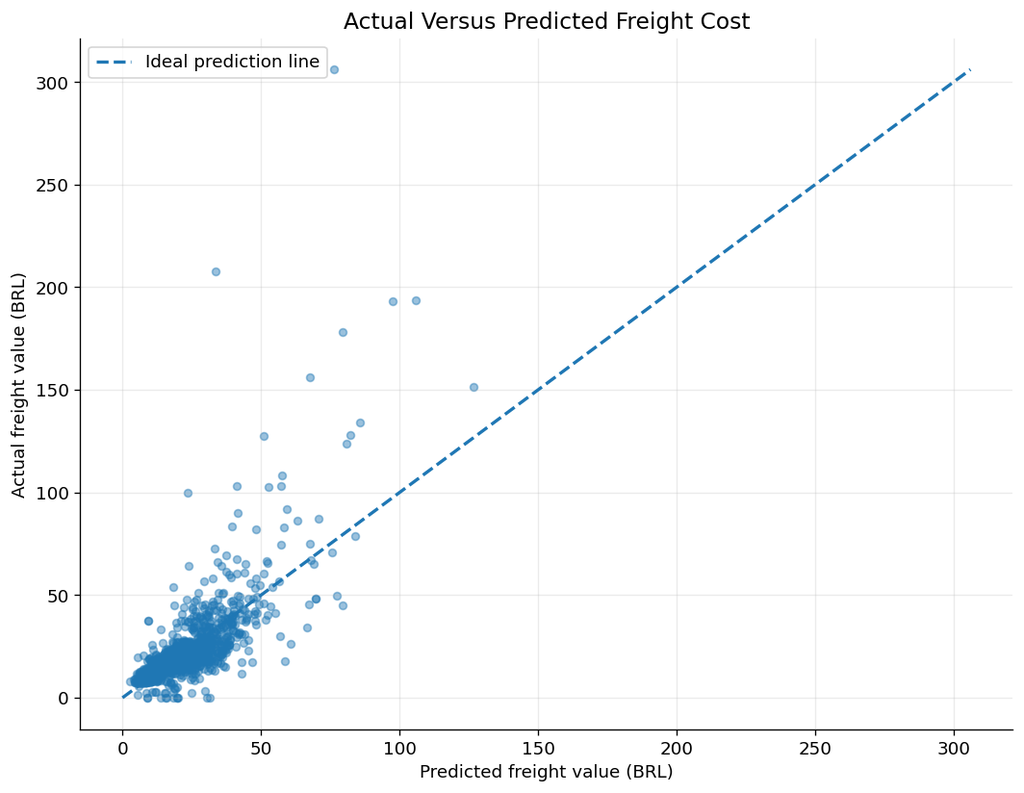

```python
# ============================================================
# ACTUAL VERSUS PREDICTED FREIGHT
# ============================================================

minimum_plot_value = min(
    y_test.min(),
    baseline_test_predictions.min()
)

maximum_plot_value = max(
    y_test.max(),
    baseline_test_predictions.max()
)

figure, axis = plt.subplots(
    figsize=(9, 7)
)

axis.scatter(
    baseline_test_predictions,
    y_test,
    alpha=0.45,
    s=22
)

axis.plot(
    [
        minimum_plot_value,
        maximum_plot_value
    ],
    [
        minimum_plot_value,
        maximum_plot_value
    ],
    linestyle="--",
    linewidth=2,
    label="Ideal prediction line"
)

axis.set_title(
    "Actual Versus Predicted Freight Cost"
)

axis.set_xlabel(
    "Predicted freight value (BRL)"
)

axis.set_ylabel(
    "Actual freight value (BRL)"
)

axis.legend()

plt.tight_layout()

save_current_figure(
    "12_actual_vs_predicted_freight.png"
)

plt.show()
```

```
Figure saved to: /Users/zimmeljavedvirk/Desktop/datasciencemid/figures/13_residuals_vs_fitted.png
```

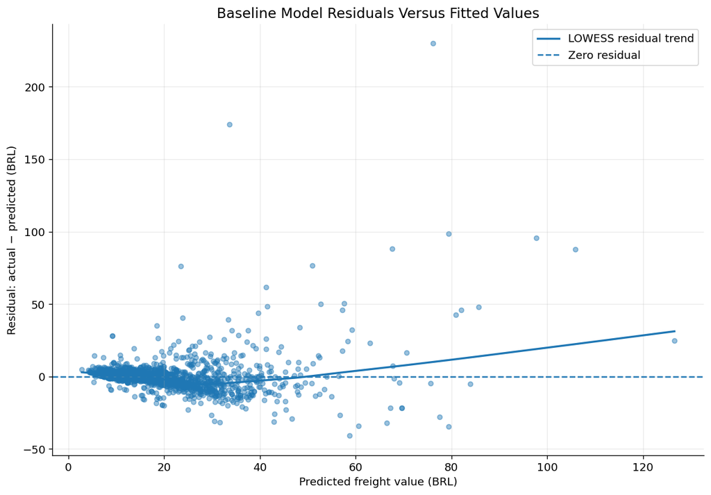

```python
# ============================================================
# RESIDUALS VERSUS FITTED VALUES
# ============================================================

residual_lowess_line = lowess(
    endog=testing_residuals,
    exog=baseline_test_predictions,
    frac=0.30,
    return_sorted=True
)

figure, axis = plt.subplots(
    figsize=(10, 7)
)

axis.scatter(
    baseline_test_predictions,
    testing_residuals,
    alpha=0.45,
    s=22
)

axis.plot(
    residual_lowess_line[:, 0],
    residual_lowess_line[:, 1],
    linewidth=2,
    label="LOWESS residual trend"
)

axis.axhline(
    y=0,
    linestyle="--",
    linewidth=1.5,
    label="Zero residual"
)

axis.set_title(
    "Baseline Model Residuals Versus Fitted Values"
)

axis.set_xlabel(
    "Predicted freight value (BRL)"
)

axis.set_ylabel(
    "Residual: actual − predicted (BRL)"
)

axis.legend()

plt.tight_layout()

save_current_figure(
    "13_residuals_vs_fitted.png"
)

plt.show()
```

```
Figure saved to: /Users/zimmeljavedvirk/Desktop/datasciencemid/figures/14_residual_distribution_qq.png
```

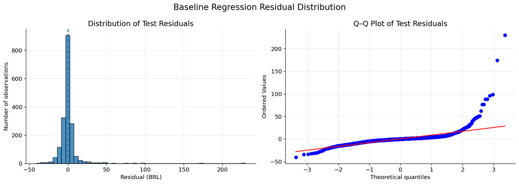

```python
# ============================================================
# RESIDUAL DISTRIBUTION AND Q-Q PLOT
# ============================================================

figure, axes = plt.subplots(
    nrows=1,
    ncols=2,
    figsize=(14, 5)
)

axes[0].hist(
    testing_residuals,
    bins=50,
    edgecolor="black",
    alpha=0.80
)

axes[0].axvline(
    x=0,
    linestyle="--",
    linewidth=2
)

axes[0].set_title(
    "Distribution of Test Residuals"
)

axes[0].set_xlabel(
    "Residual (BRL)"
)

axes[0].set_ylabel(
    "Number of observations"
)

stats.probplot(
    testing_residuals,
    dist="norm",
    plot=axes[1]
)

axes[1].set_title(
    "Q–Q Plot of Test Residuals"
)

figure.suptitle(
    "Baseline Regression Residual Distribution",
    fontsize=16
)

plt.tight_layout()

save_current_figure(
    "14_residual_distribution_qq.png"
)

plt.show()
```

```
Figure saved to: /Users/zimmeljavedvirk/Desktop/datasciencemid/figures/15_scale_location_plot.png
```

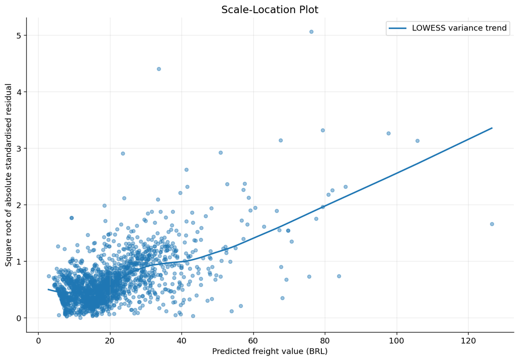

```python
# ============================================================
# SCALE-LOCATION DIAGNOSTIC
# ============================================================

scale_location_values = np.sqrt(
    np.abs(
        standardised_testing_residuals
    )
)

scale_location_lowess = lowess(
    endog=scale_location_values,
    exog=baseline_test_predictions,
    frac=0.30,
    return_sorted=True
)

figure, axis = plt.subplots(
    figsize=(10, 7)
)

axis.scatter(
    baseline_test_predictions,
    scale_location_values,
    alpha=0.45,
    s=22
)

axis.plot(
    scale_location_lowess[:, 0],
    scale_location_lowess[:, 1],
    linewidth=2,
    label="LOWESS variance trend"
)

axis.set_title(
    "Scale-Location Plot"
)

axis.set_xlabel(
    "Predicted freight value (BRL)"
)

axis.set_ylabel(
    "Square root of absolute standardised residual"
)

axis.legend()

plt.tight_layout()

save_current_figure(
    "15_scale_location_plot.png"
)

plt.show()
```